# 知识同一性谱系递归发生学

### ◆六、有限细分边界：固定世界不能只靠切分无限升级

命题二：若Ω含n个对象，初始分类有k₀个非空类，每次更新都产生严格细化，那么这样的更新次数最多为n－k₀。

证明：每一次严格细化至少增加一个非空类；分类的非空类数最多是n，因为每个类至少包含一个对象。因此从k₀开始，至多增加n－k₀次。这个结论不要求每次只拆成两类，也不要求不同轴相互独立。它只依赖有限对象范围和严格细化的定义。

这个边界不是说知识最多只能增长有限次，而是说在固定有限域中，仅靠不断细分旧对象，辨识能力不能无限增加。若实际研究持续发展，就必须有其他变化：新对象进入，关系结构改变，任务范围扩展，生成规则改变，或者在原来忽略的尺度上重新定义对象。

它因此对“AI填满谱系轴”提出一个有益约束。生成更多标签并不自动打开更大世界。一个系统可能在已经完全区分的对象上继续添加冗余描述，文本量增长而辨识能力不变。真正的高阶递归需要说明新的发生空间来自哪里，而不能只把更新次数当作深度。

### ◆七、从分类变化到发生规则变化

前述模型只处理轴的辨识作用。要研究递归，还需把新轴如何改变G_t写入系统。候选发生可表示为Cand_t＝Gen(C_t,E_t,D_t,K_t,B_t)，其中C_t为参与的思想复合主体，B_t为明确资源预算。Cand_t可以包含候选知识、候选轴、候选生成规则及对现有规则的修订建议。

验证协议J_t对这些候选作出分级判断：在规定范围内接受、保留为未决、要求补证，或拒绝。随后更新K_t，既可以增加节点和轴，也可以撤回、合并和限制旧节点。活动知识并非只能单调增加，可靠系统必须具有退出机制。

新显露及其检验结果经过选择性回写进入E，进而改变下一轮D。这种回写至少包含接受的结构、失效条件和未决冲突。若只把成功结论加入知识库，而不保存为什么成功、在哪里不能使用，生成规则容易在下一轮扩大误用。

递归的操作性判据由此形成：某次结果不只是成为下一次提示中的材料，还实际改变了后续候选的提出、筛选、验证或接口，并能在新任务中显示这种改变。把旧答案重新喂给模型当然是一种循环，但循环本身不保证递归发生具有新知识价值。

### ◆八、生成越快，验证为何可能越成为瓶颈？

再给出一个有限概率命题。设有m个实际无效候选，各自被误接受的概率至多为α。在这些边际错误率确实成立的条件下，至少一个被误接受的概率至多为min(1,mα)。这是由事件并集的概率不超过各事件概率之和得到，不要求事件独立。

若希望这一上界不超过预定风险β，可以令每项候选的适用错误上界不超过β/m。但真实知识验证并不总能取得这种校准，特别是候选根据同一测试集反复调整时，原错误率保证可能已经失效。此处公式不是给所有AI输出自动加一层统计保险，而是说明候选规模与验证设计必须共同考虑。

这个命题给递归发生带来第二个边界。候选数量增长不应只记录为产能增长；若验证能力没有跟上，误接受机会也可能扩大。错误进入E后还可能改变后续D，使系统沿错误规则继续生成更一致的内容。表面连续性越强，偏误可能越难发现。

因此，成熟的递归系统需要独立保留验证资源、未见任务和外部反例通道。不能让负责生成的机制同时拥有不受约束的验收权。思想复合主体的创造性与可纠错性应当共同增长，而不是让前者无限扩张、后者成为附属工序。

### ◆九、密度、覆盖与“填满”的可测含义

在有限对象或任务网格中，先规定非负权重且总权重严格大于零，再把有效覆盖定义为：经指定验证并可持续使用的单元权重，占全部预先规定单元权重的比例。候选覆盖另行记录，不能与有效覆盖混同。若一些单元没有可靠验证方法，应标为未决，而不是把生成过一句话计为填充。

在连续参数空间中，“填满”需要更严格的语言。有限个生成点不等于覆盖所有点，可以研究在给定距离和误差尺度下的覆盖，或者研究一组具有代表性的任务区域。距离本身也须说明，不能把文本嵌入的相近自动等同于数学理论相同。

如果本轮新增谱系轴，空间的分母和维度改变，前后覆盖率未必直接可比。一个系统可以同时增加有效知识数量而降低相对覆盖率，因为它发现了更大问题空间。这不一定是退步。发生学需要分别记录规模增长、轴增长、覆盖变化与验证能力，而不是寻找一个永远向上的万能指标。

由此，知识递归发生的成熟指标至少是一个组，而不是一个总分：有效节点、非冗余轴、可追溯关系、生成规则的跨任务收益、撤回能力与维护成本。具体研究可以选择其中一部分，但必须说明选择理由。

### ◆十、细分怎样影响一个明确决策任务

新轴非冗余只说明分类更细，还没有说明判断更好。为此，再固定一个有限决策问题。对象域仍为Ω，每个对象x具有非负权重μ(x)，所有权重之和为1；允许的行动集合记为𝒜，假定有限且非空；采取行动a面对对象x时的损失为ℓ(a,x)，假定为有限非负数。

在分类P下，系统只能知道对象属于哪个类，所以必须在同一类中使用相同行动。定义最优风险为R(P)=Σ_(B∈P) min_(a∈𝒜) Σ_(x∈B) μ(x)ℓ(a,x)。这个量是给定真实权重与损失时的理论最优值，不是由有限训练样本估计后自动能够达到的成绩。

命题三：如果Q细化P，则R(Q)≤R(P)。证明：对每个旧类B，取在B上达到最小值的行动a_B。细分后的每个子类都可以继续采用a_B，因此新分类允许的行动安排至少包括旧安排。分别在各子类优化只能降低或保持损失，再对全部旧类求和即可。这里没有用到AI，也没有用到概率独立性；它是有限决策模型的基本性质。

这个结果支持一项有限而积极的判断：在信息取得没有额外代价、真实损失已知且能够正确优化的理想条件下，保留更多区分不会使最优决策更差。但是，它不保证实际学习者不会因样本不足、估计错误或接口复杂而表现更差。理论可用信息与实际可用能力必须分开。

### ◆十一、什么时候严格改善，什么时候只是更细

还可以给出等号成立的精确条件。对于旧类B在Q下的每个子类C，令𝒜_C为使Σ_(x∈C)μ(x)ℓ(a,x)达到最小的行动集合。若所有这些集合有共同元素，就可以用同一个行动同时实现各子类的最优值，因而B的细分不降低风险。

反过来，假设细分前后的风险在B上相等。取旧类的一个最优行动a_B。它在每个子类上的损失，都不小于该子类最小损失。这些非负差额之和为零，所以每个差额都必须为零。因此a_B同时属于每个𝒜_C。对于零权重子类，全部行动都是最优，不影响条件。

于是，在有限行动集的前提下，细分严格改善风险，当且仅当至少一个旧类的子类最优行动集合没有共同元素。这个判据比“发现了差异，所以必有价值”强得多：差异必须使同一旧类中的适当行动不再能够保持一致，才迫使决策获得新的收益。

例如，Ω仍为八个二进制对象，任务是预测第二位。旧轴只有第一位，最优错误率为1/2；增加第二位，风险降为0。若增加第三位，分类同样由两类变成四类，但每个子类中第二位仍然各占一半，风险保持1/2。两种新轴具有同样的分类数量变化，却有不同任务价值。

这也给“同一性”一个新的操作含义：对某个行动问题，两个对象虽然在很多特征上不同，却可以共享同一个最优行动。它们构成任务层的共同性。另一个任务可能要求将其分开，因此共同性不能脱离任务而只有一个固定百分比。

### ◆十二、单轴无收益不代表组合无收益

逐个检验新增轴有一个重要限制：两个单独看来无用的轴，可能共同有用。取四个对象(0,0)、(0,1)、(1,0)、(1,1)，权重相同，目标为两个坐标的异或，即相同取0、不同取1。没有坐标时最佳错误率为1/2。

只知道第一坐标，两个类内部仍各有一个0和一个1，错误率仍为1/2；只知道第二坐标也一样。两坐标同时获得时，目标被完全确定，错误率为0。因此，若规则只接受“单独立刻降低损失”的新轴，就会拒绝两个本来具有联合价值的候选。

这不是鼓励任意保留所有变量。所有组合穷举会迅速增加成本。它说明新轴搜索规则需要容纳有根据的组合假说，或者允许在限额内保存暂时没有单独收益的候选。理论预期、结构约束和明确的新任务，可以帮助决定哪些组合值得测试。

对跨部落协作，这个例子具有启发性：一个部落提供的问题划分与另一个部落提供的测量方式，可能单独都不足以解决任务，组合后才产生能力。但是，异或例子只证明形式上存在协同，不证明任意两个部落合作都能产生协同。经验判断仍须另行完成。

### ◆十三、引入成本以后，最细分类不再自动最优

设C(P)表示取得和使用分类信息的成本，M(P)表示在指定期间维护该分类的成本。把风险与成本转换到事先说明的共同评价尺度后，可以定义W(P)=R(P)+λC(P)+ηM(P)，其中λ、η为非负权重。选择权重是评价安排，不是数学自动给出的事实。

加入新轴g的净改善条件为R(P)−R(Q)>λ[C(Q)−C(P)]+η[M(Q)−M(P)]。左边是任务损失的降低，右边是增加的信息与维护代价。若两边相等，可以根据风险、简洁性或其他明确规则决定；不能事后改变权重，只为让喜爱的候选通过。

举一个归一化思想实验：某新轴使风险从0.30降至0.24，但增加的加权获取成本为0.04、维护成本为0.03，则总目标反而恶化0.01。若一个较粗的轴只能把风险降至0.26，却只增加0.01成本，它的净改善更大。知识谱系的最优化因而不是无限精细化。

这项结论还说明，退役一个有效轴并不必然等于否定其真实性。轴可能准确，却因当前任务变化而不值得持续维护。可以把它从活动配置移入可恢复档案；以后成本下降或任务改变时，再重新启用。真假判断与当前使用选择应分别保存。

### ◆十四、样本记忆与外部任务上的能力

前述风险使用已知对象域和真实权重。实际研究往往只有有限样本，需要从记录估计哪些轴有效。对象编号能够把样本分到单点，从而记住每个已知标签，但这不保证未见对象的标签可以预测。

构造一个明确反例：每个新对象的标签独立地以相同概率取0或1，与其编号无关。一个系统可以完整记住过去对象的标签，在这些对象上零错误；面对一个未见对象，无论怎样利用其无关编号，条件错误率仍为1/2。这里的独立与均匀是模型假设，结论只在这些条件下成立。

因此，“新轴分开了全部样本”与“新轴提高新问题的处理能力”之间存在实质差别。谱系研究应分别记录描述性分辨率、跨任务泛化和实际成本。用训练材料得到的新轴，至少需要在未用于选择它的材料上再次检验。

更细的划分还会使每类可用样本减少。若某类只出现一次，就很难区别稳定结构与偶然观察。本文不在没有数据条件下给出统一样本量公式，而要求每项经验应用说明误差容忍、抽样方式和所估计的目标。形式分类的精确性不能代替经验估计的可靠性。

### ◆十五、对象分布改变时，旧风险还能比较吗

即使分类不变，对象权重也可能变化。为说明这种变化的边界，固定同一有限对象域、同一允许策略集合，并设所有损失落在0到1之间。令两种权重为μ和ν，它们的总变差距离为TV(μ,ν)=1/2 Σ_x|μ(x)−ν(x)|。

对于任何固定策略，其在两种权重下的风险差的绝对值不超过TV。证明可以把μ−ν分成正、负两部分；两部分总量相同，且均等于TV。由于损失在0和1之间，正部分与负部分能够造成的最大期望差就是这一总量。

由此，最优风险也满足|R_μ−R_ν|≤TV。取在ν下最优的策略，在μ下使用它，得到R_μ≤R_ν+TV；交换μ与ν即可得到另一个方向。这一结论依赖策略集合与损失定义没有改变，不能直接用于换了任务或换了评判尺度的情况。

对知识谱系测量而言，它提供了一种分账方式：如果任务权重变化，即使方法不变，平均表现也会变化；若权重变化足够小，固定任务尺度上的风险变化受到相应限制。研究者应记录对象分布，而不能把所有总体读数变化都解释为方法进步或退步。

### ◆十六、自适应探索怎样管理累计误接受

当候选根据过去结果提出时，不能随意使用只对固定检验成立的错误率。设第t轮之前的全部历史为ℋ_(t−1)，F_t为第t轮误接受实际无效候选的事件。假定验证程序在每一种允许历史下都满足P(F_t|ℋ_(t−1))≤α_t。

在这个强而明确的条件下，取期望可得P(F_t)≤α_t；对所有轮次使用并集上界，至少一次误接受的概率不超过Σ_t α_t。若令α_t=β/[t(t+1)]，由于1/[t(t+1)]=1/t−1/(t+1)，前N项之和为β[1−1/(N+1)]，全部轮次之和不超过β。

这说明，在适当校准成立时，可以把有限的累计错误预算分配到持续探索中，而不要求各轮独立。但是，给AI输出随手标上α_t并不能使条件成立。候选和评价同时反复适配同一材料时，校准尤其需要检查。公式提供设计目标，不提供无条件信用。

如果没有可用的概率校准，可以采用更弱但诚实的记录：明确哪些结果只通过有限测试，保留未验证状态，并安排外部复核。不能为了使工作流显得数学化，捏造每项主张的错误概率。

### ◆十七、错误回写的稳定性：一个条件性界限

递归系统还需要控制错误进入下一轮后的放大。设e_t为一种经过明确操作化的非负错误负担，假定其满足e_(t+1)≤ρe_t+ε_t，其中ρ≥0表示旧错误经过检查后能够留下的比例，ε_t表示本轮新增错误上界；先讨论0≤ρ<1的情形。

反复代入得到e_t≤ρ^t e_0+Σ_(k=0)^(t−1)ρ^(t−1−k)ε_k。若每轮ε_k≤ε，则在ρ≠1时e_t≤ρ^t e_0+ε(1−ρ^t)/(1−ρ)。证明只需按t归纳，最后使用有限几何和。它表明在这些条件下，错误负担被一个有限界控制。

若ρ=1且每轮持续增加正误差，旧误差不被削减，负担在递推取等号时线性增长（不等式本身只给出上界）；若ρ大于1，递归放大更值得警惕。这里不能把ρ当成任何真实平台已经测得的参数，也不能假定错误总能压成单个数。模型的用途是说明：持续生成若没有足够纠错，历史连续性可能成为错误放大的通道。

选择性回写可以作用于两个位置：降低新增错误ε_t，以及减少旧错误保留比例ρ。前者包括更好的验证，后者包括撤回、依赖检查和版本清理。只增加生成能力，而不改善这两个环节，不足以支持可靠的递归升级。

### ◆十八、版本图怎样保存循环而不制造循环证据

知识活动可以反复回到同一个问题，但证据记录应区分不同版本。主张A的第一版影响规则B，规则B又产生A的第二版，可以表示为A₁→B₁→A₂。若每次更新创建新版本，历史关系沿时间前进，并不因为概念名称重复就形成无基础的互相证明。

相反，若系统只保存一个会被覆盖的A和B，就可能出现A引用B、B又引用A，却无法知道起点和验证在哪里。这类循环不能通过增加引用次数获得独立支持。版本化的作用之一，就是把发生上的反馈与证据上的依赖区分开。

数学中的递归定义仍需另行检查基础情形、存在性或适当的不动点条件。本章的版本账本不替这些证明担保。它只规定：方法可以改变自己，但改变后的结果不能悄悄使用被撤回前提的旧信用。

一个可继承的递归系统因此需要三种同时存在的记录：候选怎样发生，证据怎样支持，版本怎样变化。三张关系图可以相互连接，却不能合并为一条无类型的“相关”边。只有这样，后继研究才能在继续创造时知道哪些基础仍然可靠。

### ◆十九、命题四至七：读数噪声、闸门次序、停止规则与零失败审计

前十八节的命题都围绕“新轴有没有区分、区分有没有用”。第三十至三十二章在使用这些命题时遇到四个新问题：读数不可靠时收益剩多少，多道检验按什么次序做，什么时候停止细分，覆盖声称怎样用抽样审计限界。下面各给一个有限命题和证明。它们都是标准概率或决策推理的应用，本书的贡献只是把它们放进同一个账本，并写明前提，不宣称首创。

命题四（读数噪声）。（a）设隐藏二元量z的先验为各二分之一，行动是猜0或猜1，损失为猜错记1。读数y以概率1−ε等于z，以概率ε不等于z。则无读数时最优风险为二分之一，有读数时为min(ε,1−ε)。（b）一般地，若读数y由精确读数x经过与结局无关的随机扰动得到，则基于y的最优风险不小于基于x的最优风险。

证明。（a）无读数时，任何行动猜错的概率都是二分之一。有读数y时，由先验均匀与对称翻转，后验概率P(z=y|y)等于1−ε；“猜y”猜错的概率为ε，“猜1−y”猜错的概率为1−ε，取较小者；该值与y无关，故总风险为min(ε,1−ε)。（b）任取一条基于y的确定规则，把它与扰动机制复合，就得到一条基于x的随机化规则，二者风险相同。随机化规则的风险是若干确定规则风险的加权平均，不小于其中最小者，也就不小于基于x的最优风险。证毕。

由此，ε＝1/2的读数毫无价值，ε大于1/2的读数在已知方向反转时仍可使用。（b）依赖“扰动与结局无关”这一条；若记错的概率本身随结局变化，扰动携带了结局信息，结论不再成立。

命题五（闸门次序）。设有k道闸门，候选依次接受检验，一旦未通过即停止；第i道的检验费用为c_i，通过概率为p_i，小于1，各门是否通过相互独立。则期望检验费用在按c_i/(1−p_i)升序排列时最小。

证明。考察相邻两门i与j，其前面各门的联合通过概率为Q。对换这两门，只改变这两门自身的费用项，因为排在它们之后的各门的前缀通过概率都含p_i与p_j的乘积，与次序无关。i在前时，这两项为Q(c_i+p_i c_j)；j在前时为Q(c_j+p_j c_i)。前者减后者等于Q[c_i(1−p_j)−c_j(1−p_i)]，当c_i/(1−p_i)不超过c_j/(1−p_j)时不大于零。任何排列都可以经相邻对换变成升序排列，每次对换不增加期望费用，故升序最优。证毕。

独立性不能省。附带模拟找到一个三门的反例：联合通过分布为五个模式，费用为5、1、1，边际通过率为2/5、7/10、9/10，边际规则给出的次序期望费用4.8，真实最优次序为4.7。两门时不会出现反例，因为期望费用只依赖两个边际通过率。

命题六（停止规则）。设逐轮增益Δ₁≥Δ₂≥…≥Δ_T≥0，每轮成本为常数c，累计净收益N_t＝Σ_{k≤t}(Δ_k−c)。则N_t在t*＝满足Δ_k≥c的轮数处最大。

证明。净增量Δ_k−c随k不增，前t*轮为非负，之后为负，故N_t在t*之前不降，之后下降。证毕。非增是关键前提，细分并不总满足它。取四个对象的异或例子：先加入任一坐标，增益为0；再加入另一坐标，增益为1/2。若每轮成本0.1，近视规则在第一轮后就停止，但两轮的累计净收益为0.3，大于不加入。所以停止规则应当按“有限步联合收益”或预先登记的组合假说来读，不应只看下一步。

命题七（零失败审计界）。设声称覆盖的格子共m个，其中k个在独立审计下不成立；随机无放回抽取n个审计。（a）零失败的概率为C(m−k,n)/C(m,n)，不超过(1−k/m)的n次方。（b）若r满足(1−r)^n≤δ，则观察到零失败时，可在置信1−δ下断言k/m小于r。

证明。（a）依次抽取，第i次抽到成立格子的条件概率是(m−k−i+1)/(m−i+1)；交叉相乘可知，它不超过(m−k)/m，因为差为k(i−1)乘以一个非负数。逐次相乘得到结论。（b）若k/m不小于r，则零失败概率不超过(1−r)^n，不超过δ。因此零失败的观察与“k/m不小于r”不相容，除非发生概率不超过δ的事件。证毕。数值上，δ取0.05时，r为0.10、0.05、0.01分别需要29、59、299次；声称覆盖40格、抽29格零失败时，用超几何概率计算，失败格子数最多2个。抽样必须在声称冻结之后随机进行，自适应挑选格子不适用。

### ◆二十、逐项检查：每个命题的正例、负例与前提

对全章命题逐项重新检查的结果是：命题一至三、严格改善判据、异或反例、分布变化界、累计误接受与错误递推的证明没有发现逻辑错误，但有两处表述需要精确化。其一，第十七节的递推是不等式，ρ等于1时“线性增长”只在递推取等号时成立，不等式只给出上界，已在该处补注。其二，命题三要求行动集有限，以保证各类内的最小值存在。下表列出每个命题的关键前提、一个正例和一个负例或越界例。

| 命题 | 关键前提 | 正例 | 负例或越界 |
| --- | --- | --- | --- |
| 命题一 | 固定有限对象集，精确比较 | 第二个二进制位把奇偶相同者分开 | 10乘奇偶是旧轴的函数；对象域扩大后可能不再成立 |
| 命题二 | 有限域，每步严格细化 | 八个对象由一类细分到八类，共七步 | 加入新对象后上界改变 |
| 命题三 | 行动集有限，权重与损失已知 | 菜篮子加入清单，风险0.421降为0.311 | 样本估计下可上升，如“带孩子”由0.421升至0.469 |
| 严格改善判据 | 有限行动集 | 预测第二位，加第二位风险降为0 | 加第三位，风险仍为1/2 |
| 异或组合 | 精确权重 | 两坐标同时给出，风险由1/2降为0 | 单个坐标均无收益；不推出任意合作有效 |
| 命题四 | 对称翻转，先验均匀 | ε＝0.1，风险0.1 | ε＝1/2无收益；扰动携带结局信息时(b)不成立 |
| 命题五 | 闸门独立，费用固定 | 四门期望费用16.6，小于书写次序的19.6 | 三门相关时边际规则4.8，高于最优4.7 |
| 命题六 | 增益不增，成本固定 | 增益0.3、0.2、0.05，成本0.1，停在第二轮 | 异或序列0、0.5，近视停止错失0.3 |
| 命题七 | 冻结后随机无放回抽样 | 40格抽29格零失败，失败至多2格 | 自适应挑选格子，界无意义 |
| 分布变化界 | 同一策略类，损失在0到1之间 | 总变差0.1时风险差不超过0.1 | 换任务或换策略类 |
| 累计误接受 | 条件误接受概率对所有允许历史成立 | α_t＝β/[t(t+1)]，总和不超过β | 模型自报的置信分不满足该条件 |
| 错误递推 | e_{t+1}≤ρe_t+ε_t，ρ小于1 | ρ＝0.5、ε＝0.1，极限不超过0.2 | ρ不小于1时无有限界；上界不是预测 |

### ◆二十一、命题之间的依赖

下面的依赖图只表示证明或应用所使用的前提，不表示逻辑强弱，也不表示时间先后。

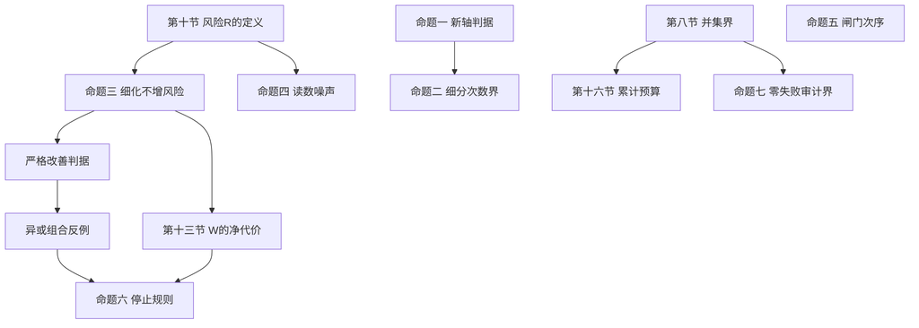

第 33 章依赖图：各命题使用的前提（箭头只表示使用关系）

对其他章而言：第二十九章使用命题一划分重命名与新轴；第三十章使用命题七、第八节并集界与第九节覆盖计数；第三十一章使用命题一、三、四、五与W；第三十二章使用命题二、六、第十七与十八节。命题五与其余命题没有逻辑依赖，它回答的是检验的组织费用，而不是知识状态本身。

### ◆二十二、可运行模拟：它能说明什么，不能说明什么

附带程序scripts/A09_sim.py，仅使用标准库，固定随机种子，运行后输出保存在scripts/A09_sim_output.txt。它做五类工作：在192个隐藏状态的构想总体上，用精确分数枚举风险，核对命题一、三、四和严格改善判据；抽取五百笔训练与四千笔保留样本，演示记忆、过拟合和学习曲线平台；对随机生成的闸门与增益实例枚举核对命题五、六，并搜索相关闸门的反例；核对零失败审计界与超几何版本；用随机可加函数核对第三十章的重建结构。此外还复算了错误递推闭式、循环依据图，以及第二十九章五问判别规则有无缺口。程序共有62项检查，全部通过。

这个结果只说明一件事：在这些具体取值与种子下，正文中引用的数字可以被重新算出，正文中的反例确实存在。它不能说明命题对一般情形成立，因为一般性依赖证明；也不能说明现实中的账本或知识平台会这样表现，因为隐藏规则是作者写进模型的，例如“今天心情”无效是由设定决定的，不是被发现的。所以，程序通过不写成一般形式认证，也不是独立评审；它在本章的地位，是防止算例和文字之间出现抄写错误，并让读者能够修改参数自行检验反例是否依赖某个特定取值。

### ◆二十三、这个模型证明了什么，没有证明什么？

本章证明了有限表示条件下的新轴判据、细分次数边界、任务风险在细化下的单调性及严格改善条件；给出了组合协同与样本记忆反例，并推导了固定任务分布变化、累计误接受和错误反馈的条件性界限；第十九节又补充了读数噪声、闸门次序、停止规则与零失败审计界四个有限命题，并附正负例与依赖图。附带程序可以复算例子和若干代数恒等式；程序测试不是对全部一般命题的自动形式验证。

本章尚未证明真实的人—AI协作必然产生新轴，也未证明这些新轴一定具有社会价值，更未证明递归发生必然带来经济增长。它提供的是一套使这些主张能够被逐项研究的结构。经验研究需要据此记录任务、预算、前提和反例，而不能用形式模型为现实直接盖章。

最重要的理论进展是：递归更新的对象不再只有知识节点，还包括对象范围、比较轴、生成规则和检验接口；同时，更新必须允许删除、限制和纠错。一个真正能够持续发生的知识系统，不是永远积累正确答案的仓库，而是能够在新问题前改变自身发生方式、又能说明改变依据的研究组织。

◆

第 八 编

# 知识部落经济与文明经济规模升级

本 篇

第 34 章从行业分工经济到知识部落经济

第 35 章知识同一性谱系如何创造新的经济规模？

第 36 章从工具内卷到知识谱系升级

第 37 章知识谱系经济学的指标体系与实证研究

34

第 34 章

## 从行业分工经济到知识部落经济

### ◆一、新的经济单位究竟新增了什么

“知识部落经济”并不是把普通专业服务换一个名称。一个机构为顾客写报告、提供建议或开发软件，未必已经形成可延续的知识谱系。本文所研究的新单位，还需要保存问题与方法的发生历史，并能依照反馈继续修订自己的生成规则。

它出售的可以是一次成果，也可以是长期解决一类新任务的能力。前者容易按交付物检查，后者需要观察后续任务表现。若一个服务只能反复给出已有答案，就不宜因为配置了智能体而被认定为发生型服务。

另一方面，发生能力不能脱离成果永远自证。声称自己拥有独特E和D，却没有可检查的新问题处理结果，也不足以形成经济价值。独特性是一项需要证据的生产条件，而不是向外部收取费用的理由本身。

### ◆二、传统专业分工与谱系分工并不互相取代

传统专业分工按任务、对象或工序组织知识。谱系分工则进一步关注这些任务如何被重新定义和生成。两者可以交叉：同一专业内存在不同发生谱系，一个谱系也可能跨越多个专业。

以教育知识服务作思想实验。某个团队按学段分工，分别服务小学和中学；另一个团队围绕“如何识别学生解释路径”组织方法，跨越多个学段。前者的分界主要是对象类别，后者的分界主要是生成机制。实际组织可以同时采用两种方式。

因此，知识部落不一定取代企业、学校或研究机构。它可以成为这些组织内部的一种知识生产结构，也可以跨组织存在。经济分析应当识别实际决策、费用和责任落在哪里，不能只依据共同术语划定核算单位。

### ◆三、进入门槛由设备购买转向发生条件重建

购买同一种工具，有时能够迅速进入相似工序；进入一个深度知识谱系，则还可能需要理解问题史、反例和判断标准。但是，传统行业也有长期训练与默会知识，不能把两者绝对对立。

AI带来的候选变化是：更小的单位可以持续维护较复杂的生成状态，因而特殊知识的组织门槛下降，迁移和继承的重要性却上升。新人不只是学习操作按钮，还需要知道哪些历史材料仍然有效，哪些规则可以修改。

这种门槛有两种不同来源。真实门槛来自任务本身的复杂性及历史积累；人为门槛来自资料封锁、不可导出格式或身份限制。二者都可能影响交易，但只有前者直接说明生产能力独特。经济理论不应把锁定收益与知识创新收益混为一谈。

### ◆四、一项发生型服务的四层成本

可以把期间成本分为公共底层成本、谱系维护成本、任务适配成本与失败处置成本。公共底层包括可共享模型和通用资料；谱系维护包括概念版本、反例与规则更新；任务适配处理新情境；失败处置承担复核、纠正和必要退出。

假设三个分支共享一项验证基础，分别单独建设各需1200单位成本，共建只需1800，另每分支增加200适配成本，则总成本由3600降为2400。所有数字均为思想实验。这种节约来自共同层，而不是让三个分支变成同一种服务。

但若共建使每个分支额外增加700协调成本，总成本就变为4500，反而高于分建。可见共享程度不是越高越好。最合适的结构取决于公共基础节约与接口维护成本的比较，不能仅凭“大平台”或“独特部落”的口号判断。

### ◆五、质量难以事前观察时，市场怎样形成

买方在购买前未必知道一个知识系统能否应付未出现的新问题。只展示最成功案例，会产生选择偏差；展示大量文字，又不能直接说明可靠性。因此，发生型服务需要比一次内容交付更明确的测试安排。

一种可研究的设计是分阶段交付：先给出适用范围和样例，再接受保留任务测试，最后按实际使用反馈修订。另一个设计是提供可复算的局部结果，让外部人员先检查部分能力。这里是产品与研究设计建议，不是对任何特定法律合同的建议。

质量记录也应容纳失败。说明一个系统不能处理某些任务，可能提高买方的使用准确性。若所有服务都宣称覆盖任何问题，市场反而更难识别真实能力。边界透明可以成为谱系经济的公共资源。

### ◆六、共同性越低，价格是否就越高

不能直接推出。高度特殊知识可能稀缺，也可能没有稳定需求；公共知识可能容易获取，却需要昂贵的可靠实施。价格由需求、成本、替代品和制度等条件共同影响，不能从同一性程度单独计算。

更有研究价值的是比较迁移成本与使用价值。某项局部知识若能帮助少量用户完成重要任务，仍可能具有经济可行性；若只服务一个罕见问题而验证成本极高，则可能需要公共研究支持，而不是独立市场收费。

因此，谱系空间的所有位置不必都形成商业企业。学校、研究共同体、公共机构和非营利协作也可以维护知识发生。把没有收费的知识视作没有价值，会使本书的经济分析过于狭窄。

### ◆七、从知识产权存量到发生能力配置

一个部落可能拥有文本、程序、数据和方法，但这些资源能否组合成持续能力，还取决于权限、人员、计算条件与版本。经济竞争因此不仅是拥有多少材料，也包括能否在许可范围内及时组织这些材料。

这使可移植性具有双重作用。对使用者，它减少被锁定风险；对提供者，它要求用持续有效性而不只是历史依赖维持关系。可移植的谱系仍可以独特，因为迁移资料不等于瞬间复制全部判断能力。

本书主张把可继承接口视为能力基础，而不是把所有知识强行公开。公共验证所需材料、个人隐私和专有资源可以采用不同权限。关键是被外部依赖的主张必须有足够依据，不能把保密变成免于说明的理由。

### ◆八、交易对象从一个结果转向持续能力

购买一份报告与购买持续研究服务，需要不同的验收对象。报告可以检查它是否回答了约定问题；持续能力则要看系统在新问题、资料更新和旧结论被挑战时怎样表现。两者都可以形成市场，但后者不能只靠第一份报告的质量定价，也不能只用“长期陪伴”回避实际结果。

一种发生型服务应说明它维护哪些共同条件，保留哪些历史，怎样处理新情境，以及什么情况需要重新验证。购买者得到的不只是存量知识访问权，还包括一定范围内的更新、纠错和迁移能力。范围越明确，双方越容易比较不同方案，而不是被笼统的智能程度或部落独特性所左右。

这一转变也改变成本结构。首次建立概念、整理反例和配置检查可能较贵，后续同类任务可以复用；但对象发生实质变化时，又需要新增研究。经济规模化因而不必等于每份输出趋近零成本，更可能表现为共同层被反复使用，特殊层按差异承担新增成本。验证与责任不会因为文字生成便宜而自动消失。

本书不能由此断言所有知识业务都应转成订阅或长期关系。对某些稳定任务，一次性公共结果已经足够；长期绑定反而增加不必要依赖。发生型服务应由任务更新需求支持，而不是为了维持收费主动制造永远未完成的问题。

### ◆九、共享组织规模的一个有限成本模型

设k个分支共建一项基础，固定成本为F，每个分支的适配成本为a，任意一对分支之间平均产生γ的协调成本。则总成本为F＋ka＋γk(k－1)/2，平均每个分支成本为F/k＋a＋γ(k－1)/2。所有参数在此模型中给定，协调关系假设为两两发生；现实中是否如此，需要另外调查。

第一项随规模增加而下降，第三项随规模增加而上升。把k暂时视作正实数，平均成本的导数为－F/k²＋γ/2，若F、γ均为正，最低点出现在k等于二F除以γ的平方根。实际分支数为整数，应比较邻近整数和允许范围。这个结果只是一个透明的规模权衡，不是知识组织普遍存在同一最优人数的定律。

取F为一千八百、a为二百、γ为一百。三个分支时平均成本为九百；六个分支时为七百五十；十个分支时为八百三十。在这一构造中，继续扩大共同组织先降低成本，后来协调费用超过新增摊薄收益。最大平台不必最经济，最小部落也不必最灵活。组织边界要由实际共享与协调结构决定。

若采用模块接口使并非所有分支都直接协调，成本函数就会改变，最合适规模也会改变。这揭示了跨谱系接口的经济价值：它不只方便交流，还可能减少必须逐对重建的关系。不过，模块化也需要维护成本与信息损失评估，不能在公式中把接口假定为免费，再宣称无限扩展已经成立。

### ◆十、共同维护如何形成可持续贡献

一个分支发现公共资料中的错误，其他分支也会受益。若只有发现者承担修复成本，它可能缺少维护动力；若所有人都只使用现成基础，公共层会逐渐积累债务。谱系经济需要研究这种贡献与收益不在同一位置的情形，而不只是研究每个部落如何出售独特成果。

可讨论的组织方式包括共同维护预算、按使用分担、按修复任务奖励，以及以公开贡献换取其他服务。它们各有激励与治理问题，本书不把其中一种指定为普遍最优。关键是把基础维护列为实际生产活动，使其能够被识别、评估和补偿，而不是把它当作生成之后自然发生的附带好处。

评价公共维护也不能只看提交数量。一次修复可能影响许多后续结论，十次表面更新却可能没有实际作用。记录依赖范围、修复后复验结果和维护时间，可以帮助比较真实贡献。与知识轴一样，维护指标也需要防止被重命名、重复提交和循环引用所操纵。

共同基础的产权与访问制度会影响上述安排，但技术可复制并不自动解决这些制度问题。本文只提出分析维度，不提供具体法律结论。实际平台应在明确授权与责任条件下选择机制，并允许使用者知道哪些资源公共可用、哪些需要许可，以及退出时可以保留什么。

### ◆十一、部落独特性与锁定收益必须分账

当使用者很难离开某系统，提供者可能拥有议价优势。但困难可以来自真实的专业积累，也可以来自资料无法导出、接口不透明或人为限制。二者都能产生收入，却对文明知识结构具有不同作用。只有识别来源，才能判断所谓不可替代性究竟证明了什么。

一个有用的思想实验是保持知识质量不变，只开放完整的迁移资料。如果用户仍愿留下，说明关系可能建立在持续贡献、效率或服务质量上；如果用户主要因为不能取回自己的历史而留下，锁定效应就值得单独计算。实际实施还需处理隐私和授权，但分析上应把“服务更好”和“离开更难”明确区分。

可迁移并不会必然消灭谱系价值。公开一套数学证明，不会自动复制研究者下一步提出问题的能力；导出问题史，也不等于另一个组织已经具备同样判断。降低人工障碍以后仍然存在的优势，更接近本书希望研究的生成能力。反而把全部优势归给神秘不可复制性，会阻碍发现哪些能力真正可以教育与继承。

因此，成熟知识部落可以同时追求独特性与可接续性。独特性使其产生值得使用的结果，可接续性使成果不因单点退出而失效。两者之间确有成本，但不是逻辑矛盾。知识经济的质量，部分取决于它能否把这种成本转成可持续的共同安排。

### ◆十二、进入成本的三个来源，以及怎样把它们分开

上一节把“服务更好”与“离开更难”分开，靠的是一个假想的动作：开放完整迁移资料。现实中，一个新进入者，或一位想离开的使用者，面对的总成本至少来自三处。第一处是可以写下来就传递的部分：问题史、定义、反例和规则，记作T_文。第二处是需要时间训练才能获得的判断：哪条旧结论在新情境还能用，哪个反例真正危险，记作T_训。第三处是人为设置的部分：不能导出的格式、不透明的接口、权限封锁、违约条款，记作T_锁。总迁移成本T＝T_文＋T_训＋T_锁。开放文献会把T_文压到阅读和整理的成本，带教可以缩短T_训，T_锁则完全取决于提供者选择不选择拆掉它。

分账的理由不止于概念整洁。Farrell与Klemperer关于转换成本与网络效应的综述指出，转换成本把使用者锁在最初的选择上，使供方在售后获得市场力量，不兼容更常见的结果是效率损失、竞争减弱和在位者增强。[R219] 把这个结论放进本书的场景：若使用者在留下与转走的净价值相等时才会离开，那么甲在乙的报价之上最多能多收的数额，就等于使用者转走要付出的全部成本T。构造一个思想实验：T_文为10，T_训为20，T_锁为50，溢价上限为80；若提供者开放迁移资料，把T_锁降到10，上限降到40。下降的这40，是锁定收益；留下的40，其中一部分才可能对应真实的能力差异。

三类成本的经济含义并不相同。T_训里的溢价，至少部分在为稀缺的判断付费；T_锁里的溢价则更接近转移支付加上效率损失。但边界不是天然的：提供者可以故意不整理历史，把本可文献化的T_文做成看上去只能意会的T_训。所以操作上不宜问“这是不是默会知识”，而要问“在善意文献化与规范导出之后，还剩下多少”。就个人数据而言，欧盟《通用数据保护条例》第20条已经有一个现成的法律形态：数据主体可以取回自己提供的数据，格式须结构化、常用且机器可读，在技术可行时还可直接转给另一控制者，但适用于以同意或合同为依据的自动化处理，并不得损害他人权利。[R222] 这说明T_锁在制度上可以被削减，也说明削减有正当的限度：保护第三方隐私的权限限制，不应算作人为锁定。该条文只涉及数据主体提供的个人数据，提供者自己的方法与判断是否可迁移，它没有回答。

分账可以做成一项迁移审计。取一组预先冻结的保留任务，让接收方在三种条件下接手：只得到原始导出；得到结构化导出与说明文档；在此之外再得到固定小时数的带教。比较三种条件下达到预先规定的非劣性标准所需的时间。前两者之差，估计的是可由整理和格式消除的部分；后两者之差，估计的是可由训练缩短的部分；三种安排之后仍然剩下的，只能称为“尚未被这些安排消除”，不能因此命名为不可复制。开放迁移也有代价：它可能降低提供者整理历史的投入。设整理文档需要成本g，整理之后原来由T_文撑起的溢价随之消失；若该溢价大于g，提供者没有自愿整理的理由，只能靠规范、竞争压力或声誉来推动。这也是为什么T_锁的削减常常需要制度，而不能指望分账本身带来改变。使用者在开放之后仍然留下，也不证明原先没有锁定，只说明留下的价值超过了转走的收益。

还有一把现成的尺：同一部落自己的新成员接班，也要经过T_文与T_训，却不受T_锁阻拦。若外部进入者在得到完整文档和带教之后，达到合格水平所用的时间与内部接班者相近，T_锁就可以认为已经基本拆除；若明显更长，差额才是需要追问来源的部分。这个比较把第23章讨论的继承与本章的进入放在同一尺度上，并要求双方使用同一批保留任务。

### ◆十三、知识合作的利益，以及谁来验证

锁定问题讨论的是离开，合作问题讨论的是一起做。Jones的研究认为，知识累积使每一代创新者要花更多时间学习才能做出贡献，窄化专长可以补偿这一负担，却把创新推向团队，并可能拖慢长期增长。[R220] 这一论证对知识部落有直接含义：每个部落可以把E和D积累得很深，但深度本身使单个部落越来越难覆盖全部所需，合作成为获得互补深度的方式。合作的利益因此是互补的深度；合作的代价，已在第九节的协调成本里算过；这里补上第三项，验证。

先看一个单项主张的验证值不值得做。设主张为真的概率为π，为真时价值为v，为假而被放行时造成损失Λ。放行不验证，期望净值为πv−(1−π)Λ。若验证者以概率q识别出假主张并将其撤回，验证成本为c_v，则验证的收益是(1−π)qΛ，值得做的条件是(1−π)qΛ>c_v。取π为0.8、Λ为100，q为0.6时收益为12，成本10则值得做；q降到0.4则收益8，不值得。这些数是思想实验。要点是q不由验证者的勤奋单独决定，还取决于他与生产者是否共享同样的盲点。

生产者自己验证，成本低，却与生产共用E和D，错误高度相关；另一个部落验证，要付翻译与接口成本，错误却更独立。设两位验证者各自的漏检率为0.4，漏检事件的相关系数为ρ，则联合漏检概率为0.16＋0.24ρ：独立时是0.16，ρ为0.5时是0.28。第二位验证者带来的收益相应从4.8降到2.4。若其成本为3，则只有ρ低于0.375时才值得请。于是出现一个可检验的假说：共享历史越多，沟通越便宜，但验证的独立性越低；有利于验证的部落关系，可能处在共同性的中间层次，既能读懂对方的材料，又不共用同样的盲点。这个假说没有经验支持，需要用后面的方法检查。

收益怎样分，也影响谁肯验证。固定费用下，验证者的努力难以观察，缺少认真查找的理由；按发现缺陷付奖励，能激励寻找，却可能诱发制造琐碎缺陷或事先串通；按放行后的实际表现分成，激励一致，但周期长、噪声大，还把风险压给验证者。三种都有失败模式，本书不指定普遍最优。研究信任品经济学的文献讨论的正是专家与买方信息不对称下的激励与制度，可以提供借鉴，但本轮只读到其摘要，没有逐条采用其结论。[R221]

较稳妥的分工是按比较优势拆开。任何人花很少成本就能重新运行的部分，交给自动复算；需要领域判断的部分，交给共同性适中的外部部落；放行以后的使用反馈，回写到第33章的版本与证据账本里，注明谁在何时验证了什么。估计q时，可以向材料里植入已知错误，看检出多少。这个办法有明显的偏差风险：植入的错误通常比自然发生的错误更容易发现，会高估检出率。

把几项合起来看，一次合作的净收益可以写成互补收益u，减去协调成本h，减去验证成本c_v，再加上因验证避免的期望损失(1−π)qΛ。四项的测量方式各不相同，互补收益常是反事实估计，协调成本可记账，避免的损失只能由植入错误或事后核查间接得到，因此不应把它们折成一个收入数字，更不应只计第一项。

合作也有失败边界。若双方都从顺利放行中获益，验证会退化为仪式；若验证者的时间成为瓶颈，积压本身就是新的成本。一个合作网络是否健康，不看它连接了多少部落，而看它被抓出过多少自己的错误。

### ◆十四、微观增效怎样进入宏观讨论

阿西莫格鲁关于AI宏观经济影响的研究，在任务成本节约与生产率改善的框架中，强调受影响任务的份额和节约幅度对总体效果的重要性，并讨论新任务的价值问题。[R52] 本书不把这项研究当作对未来全部AI效果的最终裁决，也不把“新谱系”作为跳过任务份额与成本核算的理由。

SDE的候选增量在于进一步研究任务集合和生成规则怎样变化。但是，只要要讨论经济规模，就仍需把新活动落到资源、产出、替代和需求上。一个原来没有名称的活动，可能早已由家庭或组织内部完成；一个刚开始收费的服务，也可能只是把原有非市场活动转到市场。核算边界改变与真实能力增加应分别说明。

同样，收益分布可能不同于总量变化。使用者因成本下降受益，提供者利润可能下降；某些专业人员获得新任务，另一些人的旧任务可能减少。总体增加不能自动回答谁承担转型成本。D1的创造、自由与幸福，需要在这些具体分布关系中讨论，而不是被一个宏观数字代替。

因此，本书可以提出知识谱系经济的研究假说，却不能从谱系节点数推出GDP乘数。需要观察新服务的实际使用、全部投入、原有替代方案与持续维护，再决定哪些收益属于效率改善，哪些属于活动范围扩展，哪些只是收益重新分配。

### ◆十五、规模化的终点是可持续能力，而非最大体量

一个小部落若能在限定任务中持续纠错、产生有效方法并开放必要接口，就可能比庞大但不可维护的平台更有价值。一个公共系统若承担高质量共同验证，也可能比许多各自重复的分支更有效。理论不应预先站在集中或分散任何一端，而应解释二者怎样组合。

这使知识谱系经济的规模化具有三种不同方向：更多人使用同一公共结果，更多任务复用同一生成基础，更多独立谱系通过接口合作。三者可能同时发生，也可能互相挤占资源。区分它们，才能知道一个平台增长的是用户数、任务范围，还是文明知识网络的连接能力。

最终，经济升级不在于让每个部落都变得更大，而在于形成更合适的共同层、分支层和接口层。工具提供可扩展能力，人—AI复合主体把它组织成实际知识活动，制度再使这些活动能够被继承、交易和纠错。三者缺一，都可能使潜在规模停留在生成量的表面繁荣。

### ◆十六、知识部落经济的真正规模化

规模化不一定是把同一个答案卖给更多人，也可以是共享发生基础，使更多不同任务得到可靠服务。这样的增长同时包含共同层的规模经济与特殊层的差异价值。

它也有上限：验证者的时间、语境转换、责任承担与维护都可能成为瓶颈。一个部落不能因为模型可以无限调用，就假定自身能力可以无损扩张。规模扩大若损害反馈质量，原有生成结构甚至可能退化。

因此，知识部落经济的组织问题不是选择无限统一或无限分裂，而是寻找可以持续的共同层、分支层与个人层。在这个结构中，真正值得扩张的是经过检验的发生能力，而不是服务名称的数量。

◆

35

第 35 章

## 知识同一性谱系如何创造新的经济规模？

### ◆一、从能写出来，到能够成为一项经济活动

一项知识服务在技术上可生成，并不意味着它在经济上能够持续存在。它还需要真实需求、可被理解的交付、可靠检验、维护与责任安排。AI可以降低某些环节的成本，却可能同时增加核验、纠错和协调工作。讨论经济规模，必须把完整活动放回视野。

本书的经济假说不是“知识越多，经济必然越大”，而是更具体的一条路径：人—AI复合主体使某些原来难以独立组织的知识活动变得可行，这些活动在不同共同性层次上形成持续服务，继而与其他活动连接，可能产生新的增加值。每一步都是需要验证的条件，不是已经兑换的未来收入。

这条路径也不必只通过收费文章实现。知识发生可以进入企业内部过程、公共服务、专业协作或个人实践。某些价值在市场价格中显露，另一些不完全进入交易。经济核算与社会价值评价需要互相说明，但不能用其中一种替代另一种。

### ◆二、与既有增长理论的关系：不是从零开始

Romer的内生技术变化研究把有目的的知识投入与增长联系起来，并讨论技术作为非竞争性、部分可排他投入的性质。[R17] 因此，“知识能够推动增长”不是本书首次提出。若本书只把知识称为E，把创新称为D，却不增加可检验机制，就没有形成独立贡献。

Acemoglu与Restrepo关于自动化和新任务的研究，则区分技术替代既有任务与创造新任务的不同作用。[R18] 这与本书区分工具增效和模式发生有可对话之处，但二者不能直接等同。新任务可以在公共知识框架下形成，不一定产生部落谱系；知识部落也可能长期不创造可交易新任务。

本书要增加的研究层次，是知识生产主体怎样形成具有历史连续性的E与D，以及这些条件如何支持不同同一性程度的服务。它还追问，知识发生规则本身的更新是否改变了后续任务创造能力。只有把这些中介记录出来，谱系发生才不只是既有创新经济学的另一套词语。

因此，最有力的比较不是宣布旧理论失效，而是寻找旧模型没有直接组织的变量，并检验加入这些变量后是否得到额外解释。如果没有，SDE可以保留哲学组织价值，但经济机制的新贡献需要相应收缩。

### ◆三、小市场何时跨过可行门槛？

构造一个最小服务模型。某类服务每期可售出q份，单价p，单位可归算成本c；还需支付固定准备成本F，以及验证与维护成本V。简化的持续经营条件为q(p－c)至少覆盖F＋V。这里没有把这个条件当作完整企业会计，而只是展示知识服务可能受哪些门槛约束。

设q＝100，p＝20，c＝5，单位均为抽象货币。总贡献为1500。旧准备成本为2000，验证维护为600，净额为负1100；若新工具使准备成本降到400，而验证维护保持600，则净额变为正500。这说明在需求和价格不变的假设下，一类原来不可行的服务可以变得可行。

但若使用新工具后，验证维护成本升至1300，净额就为负200。生成便宜，并不保证总成本下降。若价格因竞争下降，或实际需求少于预期，也可能再次跌破门槛。因此，AI降低知识生产边际成本的宏大说法，必须分解为具体工序，不能把核验和长期维护当作零。

这些数字是思想实验，不是某个平台的经营数据。它所提供的可检验预测是：在其他条件相近时，固定准备成本原来较高、验证成本可控制且存在真实需求的服务，更可能因工具变化跨过门槛。研究可以据此选择比较对象，而不是先统计出现了多少AI网站。

### ◆四、为什么中间同一性层次可能特别重要？

高度统一知识可以服务很大范围，但也容易被大量主体重复供给；高度特殊知识可能更贴近一个复合主体，却难以向外传递。两端之间的知识共同层，可能同时具有可复用部分与明确情境需求。它们值得研究，不是因为必然最赚钱，而是因为生成、验证和交付成本可能在这里形成不同组合。

例如，一套通用方法可以在若干相近情境中共享，而每个使用者只需补充特定条件；也可能需要共同体级的训练，之后才能进行有效个别化。经济价值由共享部分与特殊部分怎样分工决定，而不只是越个性化越有价值。

思想复合主体可以把长期研究形成的生成规则转化为服务，使外部使用者获得结果或部分发生能力。但它必须明确交付层次：出售一个答案，提供一套可复用方法，还是帮助形成能够继续更新的工作系统？这些不是同一种商品，也承担不同的维护责任。

如果把所有交付都称为“你的专属智能体”，却没有说明知识边界、更新方式和失败处理，市场可能增加许多名称，而没有形成真正的模式谱系。行业升级需要可兑现的能力差异，不能只靠专属感。

### ◆五、增加值、利润与福利需要三本账

按照增加值核算的基本关系，行业增加值等于总产出减去中间投入。美国经济分析局的官方说明据此区分总产出与行业对GDP的贡献。[R16] 因此，不能把各级知识服务的营业收入全部相加，便宣称获得了宏观经济新增规模。

假设一个知识服务的总产出为5000，中间投入为3000，则该环节增加值为2000。在这个简化例子中，不能把5000与上游3000重复相加作为同一最终活动的净新增贡献；也不能把2000直接称为利润，因为增加值还包含劳动等收入构成。真实核算还要遵循相应价格与统计口径。

宏观净增量进一步需要反事实。新的服务可能替代原有咨询、软件或人工工作，也可能使过去不发生的活动成为现实。只看新企业收入，无法知道两者比例。要比较有该创新与没有该创新时的总活动差异，还需考虑资源转移和其他部门的反应。

福利是第三本账。免费得到更可靠知识可能提高福利而不等于相同额度的交易增长；高额纠错支出可能计入活动，却不意味着人们因此更幸福。SDE的创造、自由与幸福不能被GDP代替，但也不能未经明确模型直接折算成GDP。三本账保持联系，才能避免各自越界。

### ◆六、从知识谱系到行业谱系，中间还缺哪些桥梁？

知识要进入行业，需要被转化为可使用的任务组织。一个新数学构造可能支持更好的计算方法，也可能暂时只是理论成果；一种经济解释可能帮助形成新服务，也可能尚未取得稳定预测。知识价值与即时商业化之间没有必然一一对应。

桥梁至少包括问题识别、使用接口、验证、协作和持续维护。人—AI思想复合主体可以参与这些环节，却不保证单个主体全部擅长。一个知识部落可能需要与另一个部落合作，把研究能力与实践组织连接起来。由此产生的经济谱系，可能是跨部落网络而非孤立创始人的扩张。

这种连接也会改变原知识。使用者提出新要求，原模型暴露边界，新的条件回写到生成规则。若这一步被保存并用于后续服务，经济应用又成为知识递归发生的一部分。反之，若服务只重复固定答案，市场规模可能扩大，却没有提高谱系生成能力。

因此，经济规模和递归能力应分别记录。有的组织善于复制一个成熟模式而扩大覆盖，有的组织市场不大却产生新的方法，两者都可能有价值。把所有规模增长都叫递归，或者把所有研究创新都叫产业升级，都会损害理论的辨识力。

### ◆七、怎样检验谱系发生是否真的带来额外经济作用？

可以比较几类组织：只使用通用AI改善任务的组织，增加领域资料但不改变工作规则的组织，以及系统记录E、D并允许方法回写的组织。比较需要控制初始能力、任务难度、资源和需求条件，不能把最强团队的全部优势归给谱系方法。

观察结果不应只包括文章数量或短期营收，还应包括新任务的存续、服务可靠性、客户实际使用、验证成本、知识迁移以及对旧活动的替代。某个组织生成很多新名称却没有持续使用，不构成强经济证据；另一个组织没有大量宣传，却使原来不可行的服务长期运行，可能更接近本书的机制。

尤其要预先记录失败标准。若完整谱系工作方式在相近条件下没有带来更可靠的新任务，或者维护成本长期抵消全部收益，相关经济假说就受削弱。若优势只来自额外资料或预算，而非发生规则的差异，也应如实说明。

这些比较可以先从小规模、可追溯的案例开始，但不能把少数成功直接外推为国家增长率。微观机制、行业扩散与宏观规模需要不同证据。全书的发生链只有逐段建立，才可能成为经济理论而非产业宣传。

### ◆八、可行服务集合怎样扩大：一个条件性命题

把潜在知识服务用i编号。每项服务在给定期间的预期收入为R_i，生成与交付成本为C_i，验证维护为V_i。暂时不考虑服务之间争用资源，把满足R_i−C_i−V_i≥0的服务组成可行集合𝔽。

若新工具不改变任何R_i，并使每项服务的总成本C_i+V_i均不增加，那么旧可行集合必然包含于新可行集合。证明只有一步：旧服务的非负余额在成本下降后仍然非负。若至少存在一项原来余额为负、现在转为非负的服务，就发生严格扩张。

这个命题准确表达了工具可能填充谱系空间的一条通道，但条件很强。价格可能因竞争下降，实际需求可能变化，验证成本也可能增加。因此，经验研究必须逐项确认哪些成本降低、哪些收入变化，而不能由模型调用费用下降直接推出全部可行集合扩张。

命题还假定没有共同稀缺资源。如果所有服务都争用同一位专家的复核时间，单项可行不意味着可以同时实施。知识谱系的宏观扩张需要继续考虑容量配置，而不只是逐项计算正收益。

### ◆九、更多候选与更好的组合不是同一件事

设每项候选服务具有经过说明的净价值v_i与复核资源需求r_i，期间复核预算为B。选择变量x_i取0或1，组合问题是：在Σ_i r_i x_i≤B的条件下最大化Σ_i v_i x_i。这里是一个有限资源模型，v_i的实际测量仍需证据。

如果新增候选不改变旧候选及预算，理论最优组合的价值不会下降，因为原组合仍然可以选择。但实际选择者可能受宣传、偏好或估计误差影响，并不保证找到更好组合。可能性空间扩大与实际决策改善仍然分离。

举例说，预算为8，一项服务甲需要8份资源，净价值12；另两项乙、丙各需要4份资源、净价值7。只按单项价值最高选择甲，得到12；选择乙与丙则得到14。这个例子说明，最突出的一项谱系不必构成最佳组合。

若乙、丙需要额外协作成本3，组合价值又变成11。于是，互补与协调成本决定横向谱系是否值得建立。不能从“两个部落可以连接”直接推出连接必然产生净增益。

### ◆十、共享验证基础与分支适配的成本结构

设n个分支各自建设公共基础需F，独立适配成本为f_i，总成本为nF+Σ_i f_i。若共建公共基础成本为F₀，分支适配仍为f_i，另产生接口协调成本H，则共建总成本为F₀+Σ_i f_i+H。

共建节约的条件是(nF−F₀)>H。左边是避免重复建设的收益，右边是连接代价。这个关系不要求全部分支在内容上相同；它只要求某部分基础确实能够共享，并且共享不会破坏各自必要条件。

若随着分支数量增加，协调成本增长得过快，集中共建可能不再划算。此时可以形成多层公共基础：若干相近分支先共享，再通过较薄的接口跨组协作。知识同一性的中间层次由此不仅具有哲学意义，也可能对应不同的经济组织规模。

这一模型不预先规定最佳部落人数。人数、任务相近程度和验证方式都可能影响F、F₀与H。应当测量实际结构，而不是把“一人一部落”或“一个全能平台”视作普遍最优解。

### ◆十一、一条服务链的增加值怎样避免重复计算

构造两环节服务链。上游A产出1000，其中消耗从链外购入的中间投入300，故A增加值为700。下游B购买A的1000，并从链外另买200，最终产出1800，故B增加值为600。链内合计增加值为1300。

同一结果也可以由最终产出1800减去链外中间投入500得到。若把A的1000和B的1800直接相加为2800，再称其为这项最终服务的经济贡献，就重复计算了链内中间交易。这里使用的是固定范围、固定价格口径的简化核算，与增加值基本定义一致。[R16]

若反事实中同一范围的最终产出为1700、链外中间投入为600，则反事实增加值为1100，两状态差为200。这个差仍只是所定义范围内的比较；如果新活动挤出了范围外的其他产出，还要继续扩展边界。不能把一个小链条的正差直接外推成国家净增长。

利润又是另一个量。增加值需要分配给劳动等要素及其他收入项目，不能全部归为企业净收益。若同时讨论福利，则还需要使用者收益、风险和非市场影响。保持这几个账本分离，是知识谱系经济学能够被检验的前提。

### ◆十二、一次创新的收入与后续发生能力

一项服务可以当期盈利，却损害长期能力。例如，它依靠大量未经整理的临时修补交付，收入增长同时积累维护债务。反过来，一次公共工具整理当期没有收入，却可能减少以后多个分支的成本。只看当期销售，会误判两者的发生意义。

可以用一个有限期间模型表达。初始投入为F₀，第t期由新规则带来的净增益为b_t，评价权重为δ_t，则总体评价为−F₀+Σ_t δ_t b_t。这里的δ_t只是明确的跨期权重，不等于本文推荐的任何投资折现率；不同公共或商业任务可以采用不同评价安排。

关键是b_t必须与没有新规则的比较基准相联系，并扣除相应维护和验证负担。如果只是把原服务收入全部算作新规则收益，就会高估贡献。若后续好处仅来自市场扩大，而非发生能力变化，也应分别标注。

因此，对高阶递归的经济评价，要观察规则更新以后的一系列新任务，而不只评价产生规则的那篇作品。真正的发生型资产应当表现为后续可检查能力，而不是仅有一个被命名的理论。

### ◆十三、劳动节约、任务转移与新活动

当AI减少某项劳动时间，可能发生多种后果：相同产出由更少时间完成，原人员转向其他任务，服务价格下降，或节约时间并没有被重新使用。各情形的经济和生活意义不同。

把节约时间自动乘以工资率，便宣布创造了等额GDP，会忽略资源实际如何重新配置；把被替代的劳动全部看成社会损失，也可能忽略新任务与使用者收益。需要追踪具体的活动变化，而不是让一个会计代理值替代全部后果。

谱系理论特别关注其中一种路径：节约出的能力被用于组织原来不可行的新任务。若这些任务没有发生，工具仍可能有成本与福利价值，但本书关于新领域扩张的机制便没有获得相应支持。不同层次的技术收益应当允许分别成立。

### ◆十四、从一项可持续服务到宏观增加值：一座要过六道门的桥

前面各节分别回答了服务是否可行、增加值怎样核算、节约的劳动去了哪里。这些回答合起来，仍然不等于一项服务给整个经济增加了多少。一项服务能够自己活下去，只说明它的收入覆盖了成本；它的买方原来在做什么，被它替代的供给者后来怎样，这些都不在它自己的账上。这里的“可持续”也要有操作含义：至少在若干连续期间内，不依赖补贴而覆盖第三节所说的准备、验证与维护成本，并经过一次需求或规则更新而仍在运行。只存活一期的服务，其增加值不能当作持续的经济规模。桥上要过六道门：服务自己的增加值是多少；买方原来在做什么；被替代者的增加值；被挤出的其他支出；被释放的资源是否再被使用；核算边界有没有移动。下面用一个有限的核算框架，把前五道门的结构摆出来，第六道门在下一节处理。

设买方在该服务上的期间支出为Y，全部形成该服务的产出。服务的增加值率为v_新，即增加值除以产出，增加值的定义按BEA的说明，是总产出减去中间投入。[R16] 假如没有这项服务，这笔支出会有三种去向：份额σ原来买的是替代品，其增加值率为v_替；份额κ原来花在不相关的物品上，增加值率为v_他；份额ν原本根本不会发生，例如来自减少储蓄或新增收入。三者之和为1。被替代和被挤出的供给方损失了相应的增加值，但他们所用的人员和设备可能转去生产别的东西，并且别的东西有人需要。记θ为这部分被重新吸收的比例，则全经济的增加值变化为ΔVA＝v_新·Y−(1−θ)(σv_替＋κv_他)Y。

取一个思想实验：Y为1000，v_新为0.6，σ为0.5、v_替为0.5，κ为0.3、v_他为0.4，ν为0.2。代入得ΔVA＝230＋370θ。θ为0时是230，为一半时是415，为1时是600。服务自己的增加值是600，宏观增量却可以落在230到600之间的任何位置，由θ决定。θ不是常数，它至少是两个因子的乘积：资源能否转用，记θ_资；转用后生产的东西有没有人要，记θ_需。若θ_资为0.8、θ_需为0.5，则θ为0.4，ΔVA为378。两个因子要分开估计，因为前者主要是劳动和资本市场的问题，后者主要是需求的问题。正增量的条件也由此得出：v_新必须大于(1−θ)(σv_替＋κv_他)。若服务的中间投入占比高、增加值率仅0.3，则在这组份额下θ要超过7/37，约0.19，增量才为正。营业收入同样是1000，对宏观增量的含义可以完全不同。v_新本身也随成本结构变化：服务靠大量外购的算力、数据或再分包提供时，中间投入上升，v_新随之下降。这并不与第三节“生成便宜”矛盾，因为便宜的是边际成本，而增加值率问的是收入中有多少是该活动自己创造的。

份额未知时，仍能得到一个只靠增加值率的边界。在θ为0的最不利条件下，ΔVA在Y(v_新−max(v_替,v_他))与Yv_新之间：前者对应全部支出都来自增加值率最高的被替代活动，后者对应全部是新增支出。套用上面的数字，是100到600。这个区间很宽，但它不依赖任何未经观察的份额，可以作为不知道买方去向时的谨慎说法。

这个式子是核算分解，不是行为预测。σ、κ、ν、θ都不能从服务自己的销售记录里读出来。它也没有取代阿西莫格鲁框架中的任务份额与成本节约，[R52] 只是补上买方一侧的账：任务被节约之后，钱和人去了哪里。

### ◆十五、替代、外部成本与福利，各开一本账

桥上还有三件事不能混进增加值：转型成本、外部成本和福利。下表把五本账并排放，每一本只回答自己的问题。

| 账本 | 度量对象 | 取数方向 | 不能代替 |
| --- | --- | --- | --- |
| 营业收入 | 买方支付总额 | 服务方记录 | 增加值、福利 |
| 增加值与替代 | 全经济生产的净变化 | 买方去向、被替代方记录 | 利润、福利 |
| 利润 | 服务方的剩余 | 服务方会计 | 增加值分配的全部 |
| 福利 | 使用者得到的好处 | 选择实验等 | 市场产出 |
| 外部成本 | 未入账的他人负担 | 先记实物量 | 其余四本 |

外部成本包括：读者与验证者为筛选大量输出而花的时间（第36章第八节）；错误结论通过验证后造成的损害；使用者无偿投入的情境与反例（第36章第九节）；被替代者重新就业期间的损失。这些不在v_新之中，也不应被θ吞掉。尤其是最后一项：若θ按稳态来定义，过渡期的损失就要另记。设被替代的增加值每期40，再就业需要三期，过渡损失便是120，稳态的θ里看不到它，而它恰好落在最难发声的人身上。较稳妥的做法是先以小时、事件数等实物量记录，再决定能否货币化。

福利的取数有路径，但没有捷径。Brynjolfsson等人提出的GDP-B，试图用激励相容的选择实验估计新商品与免费商品带来的福利，说明免费并不等于没有价值，也指出现行核算对这部分的度量并不充分。[R215] 该研究针对的是其选定的数字商品，其数值不能搬到知识服务上。用一个线性需求的思想实验可以看出收入与福利的差距：设愿付价格随购买量下降，P(q)＝40−0.2q。定价20时卖出100份，收入2000，使用者剩余1000；免费时200份被使用，收入为零，使用者剩余4000。两种情形下，收入账与福利账不但数量不同，排序也相反，而这里还没有计入提供成本，也没有计入验证的负担。核算边界则是另一件事：BEA说明，家务和照料等无酬劳动在GDP的生产边界之外，免费或低价的政府与非营利服务按成本计入。[R214] 设想一位家长原本自己辅导孩子，改为付费使用一项知识服务：服务产出100、中间投入40，测得的增加值增加60；若把家长的辅导按替代成本70估价，扩大口径后的生产变化是−10。符号可以反过来。反方向同样成立：一项免费的服务让使用者受益，却可能在测得的增加值里几乎为零。这些是思想实验，不是对任何服务的估计。

### ◆十六、桥怎样取数，又会在哪里断

一项桥接研究至少要有五步。第一步是服务层的成本账：产出、中间投入、验证与维护时间。第二步是买方的去向。直接问使用者“没有它你会怎样”，答案取决于对假设情形的想象，容易失真，因此更可靠的办法是分阶段或随机开放使用资格，追踪买方的支出变化，这与第37章的设计衔接。第三步是被替代方的收入和资源去向，须在授权下取得。第四步是福利，用选择实验等方法单列。第五步才是向上合成，前四步没有完成，就应停在微观主张，不写宏观数字。

桥会在几个地方断。第一，纯替代：设σ为0.9、κ为0.1、没有新增支出，Y仍取1000，各部门增加值率均为0.5，则ΔVA＝500θ，资源没有被重新吸收时增量为零。营业收入再高，也只是把原有的活动换了名字。第二，溢出。设两个相似的地区基期增加值都是100，没有服务时各自增长到104。引入服务后，处理地区为110，对照地区被分流需求，只有100。差分估计是10，对处理地区的真实效应是6，对照地区的真实效应是−4，两地区的平均效应只有1。局部比较把对照地区的损失当成了处理地区的收益，宏观结论因此被放大。第三，验证容量：第八、九节已说明，单项可行不意味着能同时实施，复核时间会成为共同瓶颈。第四，静态：上面的框架只看一个期间，而谱系理论最关心的是后续新任务能否发生，这需要第29至32章讨论的递归证据来补，不能靠一期的增加值回答。若规则更新后确有新任务出现，其增加值应逐期单列，并检验它能否由买方原有支出的变化解释；第十二节的净增益b_t，只有扣除替代与挤出之后的部分，才可以过桥。第五，价格下降：同一任务从价格100的旧服务改为价格60的新服务，买方多出的40花到哪里，决定净效应的符号；若被存起来，当期增加值反而下降，福利却上升了。

报告的格式也应服从这一结构：分列服务自身的增加值、带区间的净增量、福利估计和外部成本的实物记录，并写明每个数来自哪一步。缺项就写“未取得”，不以零代替；把未知填成零，等于宣布那件事没有发生，也会让空白的账本看上去像已经结清。

所以，说一项知识服务“创造了新的经济规模”，至少要交出三样东西：它自己的增加值，它的买方和被替代者的去向，以及福利与外部成本的另账。三样缺一，就只能说它是一项可行的服务。

### ◆十七、把经济失败也写入谱系历史

一项新服务失败，可能因为知识无效，也可能因为需求不足、交付困难或验证成本过高。必须保留失败类型。若把商业失败全部归为理论错误，会丢失可能仍有价值的公共知识；若把理论错误全部归为营销不足，又会保护不可靠成果。

可以为退出分支保存简明记录：哪些主张仍然有效，哪些条件不能持续，未来怎样变化可能重新启动。这样的记录减少后继者重复承担同样成本，也让经济失败成为知识发生的一部分。

因此，文明经济升级的一个重要能力，是允许失败退出活动层，同时保留可继承的经验。一个只能增加项目、不能关闭项目的系统，即使谱系名称越来越多，也未必具有健康的递归能力。

### ◆十八、知识谱系经济的瓶颈与边界

有效分支可能受验证者、经验材料、信任与协作能力限制。生成成本下降后，瓶颈可能从表达转向检验和使用；从单个答案转向长期维护；从工具获得转向复合主体之间的交接。真正有价值的产业创新，也可能发生在这些连接和检验环节，而不只发生在生成模型本身。

与此同时，深度历史纠缠可能形成能力优势，也可能形成依赖与封闭。用户不能迁移资料、无法判断服务边界或必须持续依附某个创始人，可能降低整个网络的协作能力。知识部落的经济价值不应靠阻断公共知识获得，而应体现在它持续创造和兑现的特殊能力。

本章最终把经济升级限定为一个需要现实兑现的过程：工具改变成本与能力，思想复合主体形成可持续的知识发生方式，知识通过可靠接口进入新的活动模式，再在替代、投入和社会后果的共同约束下产生经济效果。谱系化提供新的增长可能，真实世界决定哪些可能能够留下。

◆

36

第 36 章

## 从工具内卷到知识谱系升级

### ◆一、降低成本为什么可能压缩经营者收益

考虑一个严格简化的市场：两家经营者提供完全可替代的服务，买方只比较价格，两家具有相同边际成本和足够产能。若双方报价都高于边际成本，其中一家略微降价便能争取需求；在这些假设下，价格竞争会把价格推向边际成本附近。

这一模型的作用不是描述全部真实市场，而是揭示一种可能：共同工具降低成本以后，使用者可以获得更低价格，经营者却未必得到更高利润。若另有已经投入的固定成本，经营者还可能无法覆盖全部支出。工具有效与企业获利不是同一判断。

因此，“内卷”不能只用利润下降定义。价格下降可能给消费者带来真实收益，也可能反映重复竞争。要判断是否存在结构性升级，需要进一步观察新增任务、质量、资源配置与长期可持续性。

### ◆二、同质化与公共共同性不是一回事

公共数学、标准接口和可靠资料帮助所有参与者工作，不应被当成内卷根源。导致同质竞争的是多个组织在几乎相同的任务与价值空间中重复配置能力，而不是它们共享任何知识。

恰恰相反，共同基础有时能够降低差异化成本。若每个团队必须自行验证全部基础事实，就没有资源处理特殊问题。公共层越可靠，分支越有可能把精力用于真正不同的E和D。

因此，从内卷走向谱系升级，不是抛弃公共知识，而是让公共知识支持新的问题组织。共同性与差异性可以形成互补关系，而不必进行零和选择。

### ◆三、一个差异化服务的有限模型

设两个分支的需求满足q₁=a−bp₁+dp₂、q₂=a−bp₂+dp₁，其中a为正，b大于d且d非负；只讨论需求为正的内部区域。两者边际成本均为c，暂不计固定成本。参数d描述交叉替代，b描述自身价格影响。请注意：d只是交叉价格系数，不能单独读作“可替代程度”，因为增大d同时抬高了对称价格下的需求；这一点在第十三节末段复核，第十四节另给出能让一个参数只代表可替代程度的设定。

分支1利润为(p₁−c)q₁。对p₁求导，得到a−2bp₁+dp₂+bc。对称解满足p₁=p₂=p，因此p=(a+bc)/(2b−d)。相应需求为q=a−(b−d)p。只有在a>(b−d)c等条件保证内部解时，这个表达才适用。

该模型说明，在不完全替代的任务空间中，经营者可能保留一定加价。但它没有证明这种差异化具有社会价值。人为制造不兼容或增加比较困难，也可能降低替代性。只有当差异对应真实任务改善，才能支持本书所说的谱系升级。

### ◆四、真实差异与制造差异的分界

一个新分支应当说明：它处理了什么原来未被充分处理的问题，为什么旧方法不足，新增条件怎样改善结果。若只是使用独特术语让客户难以比较，差异虽然存在，却没有增加知识能力。

可以采用“去掉标签”检验。隐去学派和工具名称，只比较任务、依据和结果，新分支是否仍有可辨识贡献？还可以采用“可迁移接口”检验：公开必要条件以后，外部使用者能否正确理解其用途，而不是只能依赖提供者的权威。

这两种检验不会消除所有复杂性，但能减少把包装当作谱系的风险。真正的生成独特性不怕明确边界，因为它的价值来自更好的研究和行动，而不是来自不可说明。

### ◆五、为什么新增需求不等于随意创造欲望

知识谱系可能使原先无法组织的活动变得可行，例如持续维护一个小群体的专业问题史。这里的需求可以在工具出现前已经存在，只是缺少可承担的供给方式。

也可能出现另一种情况：服务商通过复杂指标制造不必要的焦虑，再出售所谓解决方案。这同样能产生收入，却不应自动被视作文明升级。经济规模与意义改善之间需要额外判断，不能把任何付费都解释为正面发生。

SDE的D1意义维度在这里具有规范作用：创造、自由与幸福不应被缩减为交易次数。它们要求进一步询问，新服务是否扩展真实能力，是否增加不必要依赖，是否把成本转移给没有发言权的人。这些价值问题不能由利润公式单独回答。

### ◆六、专业化可能过度，合并也可能是升级

假设两个小分支分别维护几乎相同的基础，用户群高度重叠，验证成本却重复发生。继续强调独特身份可能浪费资源。把它们合并成共同基础，再保留必要的局部模块，反而可能提高生成能力。

因此，谱系升级不能用分支数量单调增加定义。它包括分化、合并、退出和重新组织。一个系统减少十个冗余分支，却使三个有效分支拥有更可靠的验证能力，可能比继续扩张名称更成功。

这与递归发生的选择性回写一致。知识生态需要能够删除失效路径，而不是让每个已形成组织永久获得理论保护。原有投入可以值得尊重，但不能成为拒绝纠错的理由。

### ◆七、当竞争奖励的是可见数量

假设两家组织竞争一项总额固定的注意收益R，它们分别生成q₁与q₂份同质内容，取得收益的比例由各自数量占总量的比例决定，每份成本为c。对第一家，收益减成本为R乘q₁除以q₁＋q₂，再减去cq₁。本节设R＞0、c＞0，数量为连续决策变量；只研究双方数量为正、内容质量相同、没有其他容量限制的思想实验。

对自己的数量求导，第一家的边际收益为Rq₂除以总量的平方，再减去c。对称内部均衡满足两家都生成R/(4c)，总生成成本为R/2。于是，在这个特定模型中，单位生成成本下降会提高均衡数量，却不降低双方合计的争夺成本，也不增加固定的注意收益。这个推导不表示现实市场必然采用如此分配规则。

取R为一百、c为一，两家各生成二十五份，总成本五十；若c降到二分之一，两家各生成五十份，总成本仍为五十。数量翻倍，但模型中的有效收益总额没有增加。工具确实更高效，竞争安排却把节约转成了更多同质争夺。这里的损耗来自奖励结构，而不是来自公共知识本身。

当c趋近零时，模型给出极大的数量，这也暴露了其边界：现实存在注意、验证和容量约束，线性成本与比例分配不可能无限保持。边界不影响有限例子的启示，却要求我们不能把公式外推成无限生产的现实预测。一个好的经济模型应同时展示机制与失效条件。

### ◆八、数量竞赛怎样侵蚀知识验证

如果每份内容都需要外部读者检查，新增数量会把成本转移到接收者。提供者看到自己的生成费用下降，读者却承担更大的筛选负担。若评价只看发布者账面成本，就会把这种转移误认为总体效率提升。知识经济必须把验证与注意的机会成本纳入分析。

更严重的是，内容之间可能相互引用同一来源，使大量相似表达看起来像广泛共识。发布数量增加并没有增加独立证据，却可能提高错误被接受的概率。这个机制不是AI特有，但低成本生成可以放大它。治理的对象因此应是证据依赖和奖励方式，而不是简单限制所有新的表达。

一种改进方向是把奖励从数量转向经检验的任务贡献。例如，是否识别了一个此前未发现的反例，是否使一个新的群体能够可靠使用某项方法，是否减少了后续判断错误。但任何新指标都可能再次被追逐，所以需要保留抽查、反例和方法更新。没有一种单一分数能够永久承担知识质量的全部责任。

因此，反内卷不是禁止竞争，而是改变竞争在什么空间展开。共同基础上的速度竞争可以有价值，新任务的探索也可以有价值；问题在于，评价是否把真正改善与表面可见性区分开。谱系升级要求新增能力进入新问题或更可靠的旧问题处理，而不是只成为注意争夺的放大器。

### ◆九、专业化投入与可识别收益

一个团队决定建立特殊知识分支，需要先承担资料整理、方法适配和验证成本。若使用者不能识别这些投入产生的质量，它可能难以收回费用。于是，市场不一定自动奖励更好的谱系；便宜、流畅而无法验证的服务，也可能挤压严谨服务。知识经济研究需要把质量可识别性作为条件，而不是默认买方知道一切。

可识别性可以通过分阶段样例、保留任务、可复算结果和失败边界改善。它们的作用不是把所有内部经验完全公开，而是让外部主体获得足以作选择的证据。一个服务明确不能处理哪些问题，可能减少错误使用并提高长期信任；但这种好处是否被市场回报，仍需具体观察。

对新谱系而言，第一批用户还可能参与知识发生。他们提供情境、反馈和反例，使原有生成规则得到修订。应当记录这种贡献，而不是把所有改善都归给提供者的模型。合作产生的知识如何授权、署名和继续使用，需要明确约定。否则，谱系经济会把使用者的无偿知识投入隐藏在企业创新叙事中。

因此，一项差异化服务是否成立，不仅取决于能否产生独特答案，还取决于其质量是否可检查、反馈是否能进入修订、贡献是否被合理记录。三个条件共同决定独特性能够成为持续能力，还是只成为更难比较的包装。

### ◆十、效率改善仍然可以是正面升级

本书不能为了强调谱系化而否定旧任务做得更好的价值。若一种工具让同样质量的公共服务更便宜，释放资源供其他用途，即使没有产生新的行业名称，也可能具有真实收益。谱系发生提供一条结构性扩展机制，不是经济改善唯一合法的形式。

相应地，“只有多元化和谱系化才能走出内卷”的命题，需要限定在持续同质争夺难以打开新活动空间的情形。在其他条件下，提高质量、改善分配、消除浪费或扩大有效需求，也可能改变竞争结果。把必要条件说得过强，会使理论忽略能够与谱系化相互支持的机制。

作者在理论形成中强调的重点仍然保留：当新工具仅被用于同一种旧模式，新增能力可能继续挤入原来的竞争通道；当复合主体能够重组问题和活动，就有机会开辟新的价值空间。本书将这一判断写成有条件的发生机制，而不是把任何不增分支的改善排除在文明进步之外。

这种限定也让公共统一性恢复适当位置。统一标准减少重复劳动，可靠公共知识降低进入成本，通用工具让小主体获得基本能力。它们不是需要被谱系化消灭的旧物，而是差异化发生能够经济实现的基础。共同性越有质量，特殊化越有机会把资源用在真正相关的差异上。

### ◆十一、无效差异可以被合并，真正差异可以被保护

设两个分支使用不同术语，却对同一任务给出完全等效的规则，维护成本各自很高。将它们映射到共同表达，可以保留历史贡献而减少重复。若另一对分支在关键条件上确有不同反应，强行合并则会损害任务质量。合并与分化都需要同一性分析，不能由组织规模偏好预先决定。

这意味着谱系管理应定期检查两种清单：哪些差异已经失去用途，哪些共同规则开始掩盖重要差异。前者支持合并和退役，后者支持分叉和新轴。一个只会分叉不会合并的系统，容易积累维护债务；一个只会统一不会分叉的系统，则容易压制新问题。

AI可以辅助比较语义、检测依赖与寻找反例，但最终判断应落在明确任务和验证上。两个文本语义相似，不足以证明其操作等价；两个文本措辞不同，也不足以证明形成了独立谱系。将模型相似度当作最终裁判，会把知识结构重新压成表面表达的竞争。

因此，反内卷的知识组织不以分支数为目标，而以有效差异与可靠共用的适当比例为目标。这个比例没有脱离任务的普遍最优值，却可以通过成本、结果和维护记录不断调整。调整本身就是行业层面的递归发生。

### ◆十二、让竞争发现问题，而不是制造无法完成的承诺

一个开放的谱系市场应允许不同方法在同一任务上接受比较，也允许研究者提出新任务，但要求新任务说明其真实需求和完成条件。仅仅把承诺扩大到无法验收的范围，不构成更高阶能力。越宏大的服务描述，越需要分解成可以逐项检查的关系。

当一个系统失败时，应区分方法失效、条件不足、执行偏差与任务改变。不同诊断支持不同更新：修正规则、补足资源、改进执行，或重新界定问题。若所有失败都归因于使用者不够理解，提供者就免除了自己的学习责任；若所有失败都归因于工具无用，又会失去局部改进的机会。

行业升级因此不是没有失败的状态，而是失败能够成为新的公共或局部知识，减少同类损耗并打开有效活动。工具的性能增长提供机会，复合主体的判断与组织决定如何使用机会，竞争与协作制度决定这些成果能否继续累积。三层关系结合，才使谱系经济超出“每个人都多生成一点”的表面繁荣。

### ◆十三、复核：两个模型的变量范围与正值条件

前面两个模型都用了连续变量和若干“显然为正”的参数。这一节把它们逐项检查，因为结论是否成立，常常取决于这些没有写出来的范围。

先看第七节的数量竞赛。它采用的“按数量占比分配奖励”，属于以努力之比决定获胜概率的比率形式；Skaperdas对这类竞赛成功函数的公理化有专门讨论。[R217] 本书采用它，只因为形式简单，并不认为现实的分配规则如此。设R＞0，c＞0，双方数量q₁、q₂为非负实数，在q₁＋q₂＞0时第一方的净收益为Rq₁/(q₁＋q₂)−cq₁。当双方数量都是零，份额没有定义，必须另作约定；约定无论怎样，(0,0)都不是均衡，因为只要一方生成一个很小的正量，就独得奖励，净收益接近R。给定q₂＞0，一阶条件为Rq₂/(q₁＋q₂)²＝c，最优反应是q₁＝√(Rq₂/c)−q₂，且仅当q₂小于R/c时为正；自身数量的二阶导数为−2Rq₂/(q₁＋q₂)³，恒为负，所以一阶条件给出的就是全局最大。内部纯策略均衡中，两个一阶条件相减得q₁＝q₂，因此均衡唯一，数量为R/(4c)，每方净收益为R/2−R/4＝R/4，大于零，参与有利。

正值条件各有作用。若c小于等于零，多生成不再有代价，最优反应没有上界；若R小于等于零，没有奖励可争，最优是不生成。c趋近零时，均衡数量无界增长，这是模型在现实容量约束处必须停止的地方。数量若只能取整数，结论也不变：取R为100、c为3，连续解约为8.33，穷举整数组合，唯一的非零纯策略均衡是双方各8份，总生成成本48，与连续解的50相近。这些都是用程序复核的有限算例，不是一般定理的替代。第十六节要用到异质成本的情形：两方单位成本为c₁、c₂，各自净收益为Rx_i/(x₁＋x₂)−c_ix_i，同样的一阶条件给出x_i＝Rc_j/(c₁＋c₂)²，总支出为2Rc₁c₂/(c₁＋c₂)²。由(c₁＋c₂)²不小于4c₁c₂，总支出不超过R/2，等号当且仅当c₁＝c₂。也就是说，双方越对称，耗散越大。

第三节的差异化需求同样有范围。它要求b大于d且d不小于零，a为正，并且a＞(b−d)c。这最后一条一身三用：对称价格高于边际成本，需求为正，二者都等价于它。取a为10、b为2、d为1、c为1，价格为4，每家数量为6。复核中发现了一个解释问题：保持a、b不变而增大d，对称价格下的需求随之变大，均衡价格和利润也一起上升。d取0、0.5、1、1.5时，价格依次约为3、3.43、4、4.8，单家利润依次约为8、11.8、18、28.9。所以这里的d只是交叉价格系数，不能单独读作“可替代程度”：可替代程度更高，加价反而变大，与直觉相反。这并非计算错误，而是参数把市场大小和替代混在了一起。

### ◆十四、让“可替代程度”有明确含义

要让一个参数只代表可替代程度，需要给需求一个来源。设代表性使用者的效用为α(q₁＋q₂)−(q₁²＋q₂²＋2sq₁q₂)/2再减去支付，其中α＞c＞0，s属于[0,1)（α、s均为本节局部记号，s与SDE的S无关，也不同于第33章的错误预算α_t）。s等于零表示两项服务互不相关，s越接近1越接近完全替代。这是一种便于计算的二次效用设定。差异化双寡头中价格与数量竞争的经典论文，如Singh与Vives，研究的是同一类问题，但本轮只读到其摘要，没有核对其具体设定，以下推导由本书自己完成。[R218] 由效用得逆需求p_i＝α−q_i−sq_j，反解得直接需求q_i＝[α(1−s)−p_i＋sp_j]/(1−s²)。s必须严格小于1，因为s等于1时1−s²为零，直接需求式没有定义，那正是第一节完全替代的情形，要按价格竞争另行处理。它与第三节线性式同形，但三个系数不再独立：a＝α/(1＋s)，b＝1/(1−s²)，d＝s/(1−s²)。

对称均衡价格为p＝[α(1−s)＋c]/(2−s)，加价为(1−s)(α−c)/(2−s)，每家数量为(α−c)/[(2−s)(1＋s)]。s为零时加价是(α−c)/2，各家如同垄断；s趋近1时加价趋近零，回到第一节价格逼近边际成本的结论。这时方向是对的：可替代程度越高，加价越低。成本传递也有明确公式：dp/dc＝1/(2−s)，介于二分之一与1之间，可替代程度越高，成本下降传给价格的比例越大。取s为0.5，传递率是三分之二。

### ◆十五、进入自由时，降低成本为什么不减少耗散

第七节固定了两个参与者。让参与者数量n也成为变量，结论会更尖锐。n个同质参与者争夺总额R的奖励，每人单位成本为c，同样的一阶条件给出每人数量R(n−1)/(cn²)，每人扣除生成成本后的净收益R/n²，总生成成本R(n−1)/n，n为2时正是第七节的R/2。这个总量与c无关：成本降低，每人生成得更多，总花费却不变。

再设每个进入者要付一次性进入成本F。自由进入使这笔净收益R/n²降到F，所以均衡参与者数为√(R/F)。取R为100、F为4，n为5，生成成本合计80，进入成本合计20，总和恰为R。这里的“恰为R”有一般性：此时总耗散R(n−1)/n＋nF＝R，奖励被完全耗散，不论c是多少；取c为0.2、1、5分别复算，总耗散都是100。这是比率型分配规则下的一个有限推导，现实中参与者异质、奖励可再分配、进入成本也不固定，数字不可照搬。

它对本章的含义是：在这种奖励结构下，共同工具把c降下来，既不增加奖励，也不减少耗散，变化的只是耗散在生成与进入之间的分配。真正能改变结果的，是进入成本F、奖励的规则，以及奖励本身的大小。谱系理论用这个语言重述，就是：新任务被组织出来，意味着出现了新的奖励R′，而不是在旧奖励上多生成几份。这一点留在下一节与其他路线一起比较。

### ◆十六、不走谱系路线，竞争结果也能改善

至此可以回答一个必须回答的问题：改善竞争，是否只有降低s这一条路？我们取α为2、c为1、s为0.9作为基准，此时加价约0.09，使用者剩余约0.435，总剩余约0.522，已接近价格等于边际成本时的上限0.526。为了公平比较，让三条路线各自把“价格等于边际成本时的最大总剩余”提高到同一水平0.6：路线A降低s，使之降到约0.667；路线B保持s，把c降到约0.932；路线C保持s，把α升到约2.068。这个“等潜力”设定是构造的思想实验，三条路线的真实成本并不相等。

结果是：路线A把加价抬到0.25，两家利润合计约0.225，使用者剩余却降到约0.338，低于基准，总剩余约0.5625，只实现潜力的93.8%。路线B与C使加价只有约0.097，使用者剩余升至约0.496，总剩余约0.595，实现潜力的99.2%。下表把数字并排放出，单位为抽象货币，全部是思想实验。

| 情形 | 加价 | 使用者剩余 | 两家利润合计 | 总剩余 | 占潜力 |
| --- | --- | --- | --- | --- | --- |
| 基准（s＝0.9） | 0.091 | 0.435 | 0.087 | 0.522 | 99.2% |
| 路线A（降低s） | 0.250 | 0.338 | 0.225 | 0.563 | 93.8% |
| 路线B或C（降成本或升质量） | 0.097 | 0.496 | 0.099 | 0.595 | 99.2% |

差异化在这个模型里确实提高了总剩余，也提高了厂商利润，但它同时放松了价格竞争，增益主要落在厂商一侧；降低成本和提高同一任务的质量，则通过更激烈的价格竞争把大部分增益留给使用者。成本传递公式给出同一方向的解释：s为0.9时，成本下降的约91%传给价格；s降到0.5时只有约67%。接近同质的市场里，降成本的好处更多流向使用者；差异化则同时削弱了这种传递。R13考察的是客服场景中已有任务完成效率的变化，不涉及新任务，可以看作路线C一类的经验例子，但本书不据此推广到别的领域。[R13]

数量竞赛里也有非谱系的办法。其一，对每份提交收取验证费τ：均衡数量降为R/[4(c＋τ)]。取R为100、c为1、τ为1，每家12.5份，生成资源成本由50降到25，另有25是转移，不是浪费，是否值得取决于这笔费用是否真的用于验证。其二，让奖励与经检验的质量挂钩。设两方单位有效产出的成本分别为0.5与2，均衡总支出由50降到32；优势方得到五分之四的奖励，净收益64，劣势方净收益4。总耗散下降了，代价是一方长期占优，而且前提是质量差异可以被可靠核验，核验本身有成本。

第三条路线是合并重复分支，第十一节已作定性讨论。用同一模型的极限情形可以算出条件：两家近乎同质、α−c取1时，价格竞争的总剩余是0.5；合并成一家并自由定价，总剩余降为0.375，损失0.125。只有节约的固定成本超过这个数，合并才值得；若合并后价格仍受约束，则损失小得多。所以合并不是无条件的好办法，是否合并取决于合并后的竞争结构。

这组对照的结论要说得有分寸。它不说明谱系升级无用：模型固定了任务集合和α，只能比较在已有任务上的竞争，无法表示新任务被组织出来之后发生的新需求，而那正是谱系理论的核心主张。它说明的是，不能因为内卷存在，就推出必须走降低s这一条路。若差异化同时创造了原本不存在的新奖励R′，总剩余的变化还要加上新奖励的净额；这一项本模型没有，也推不出，只能靠第37章的设计去观察。判断应来自同预算对照：对相近的组织分别安排公共验证与降成本、提高质量、差异化三类支持，比较使用者结果、厂商利润和验证负担。这与第37章的设计衔接。

### ◆十七、从企业选择到公共条件

企业可以改进自身方法，却不能单独解决全部公共验证、教育与基础设施问题。若新知识服务都依赖同一项基础数据质量，改善公共数据可能比补贴许多重复工具更有效。这个判断仍需具体成本比较，不能从理论直接推出某项政策。

对研究设计而言，应当比较不同支持方式：购买工具、训练人员、建设共同检验资源、支持跨谱系接口，各自怎样影响有效任务和成本。只有这样，才能把“鼓励AI应用”转成可评价的组织选择。

本章的结论因而不是“只有差异化才有价值”。效率提高本身可以重要；公共知识也不可替代。真正的问题是，当相同工具已普遍可得，怎样让新增能力进入新的有效活动，而不是只在旧市场中重复争夺。谱系升级提供了一条机制，但它仍必须通过质量、成本与公共后果的检验。

◆

37

第 37 章

## 知识谱系经济学的指标体系与实证研究

### ◆一、把一条宏大链条拆成多个研究问题

“思想复合主体—知识谱系—行业升级—经济扩张”包含不同层次的关系。一个实验通常只能检验其中有限环节。若在写作任务上发现质量提高，就直接宣布文明经济升级，等于跨越了多个尚未测量的机制。

本章把研究分成五层：任务表现、持续生成能力、知识谱系结构、组织活动变化与净经济后果。每层有自己的观察单位、时间范围和竞争解释。上层结论需要下层证据，但不能只靠下层证据自动推出。

这套设计尚未采集真实实验数据。所有分组、指标和阈值都是研究方案，必须在实际执行前完善伦理、资源与测量安排。程序复算只能检查有限算例，不能代替经验结果。

### ◆二、任务表现：准确、有效与新颖应分开

一个回答可以准确却没有新意，也可以新颖却错误；可以理论上正确，却没有回应指定问题。因此，不能用单一印象分同时代表所有维度。

对于数学任务，可以分别记录定义是否清楚、推导是否有效、是否发现反例、是否产生非重复结果。对于经济分析，可以记录数据来源准确性、模型假设、预测比较和不确定性表达。对于教育任务，则需要观察学习目标与任务表现，而不是只评价文字是否感人。

这些指标不必全部合成总分。若需要综合，应事先规定权重，并保留分项结果。关键错误可以作为阻断条件，不能被语言流畅度或篇幅抵消。

所谓创新水平也不应被包装成未经验证的“智商”测量。可以评价具体任务的原创性与有效性，但不能据此给人或作品赋予具有心理测量含义的分数，除非另有充分量表与验证。

### ◆三、持续生成能力：用后续任务而不是首轮产量检验

知识谱系的核心是继续发生。因此，评价不能只停留在首次作品。需要在一段研究过程后提供新任务，观察系统是否能利用已形成规则、识别失配并产生合理修订。

后续任务应包含熟悉领域内的新问题、结构相似但表面不同的问题，以及会诱发错误套用的反例问题。三类任务共同区分记忆、迁移与判断能力。只考熟悉题，会高估连续性；只考完全无关任务，又无法反映谱系积累。

还可以测量错误修复：给系统一个已经被指出缺陷的结论，观察它是否只改措辞，还是同步更新相关依赖。一个能够写出漂亮勘误却保留旧错误前提的系统，尚未完成真正回写。

### ◆四、交叉替换设计及其识别限制

设H表示原研究者，H′表示对照研究者，A_E表示具有长期研究状态的系统，A₀表示新系统。四组任务得分可以构成一个交互量：Γ=Q(H,A_E)−Q(H,A₀)−Q(H′,A_E)+Q(H′,A₀)。

Γ为正，表示在这个任务与评分尺度上，原研究者与长期系统的组合具有额外差异。但它不自动证明不可还原的主体，也不自动证明因果效应。研究者能力、任务熟悉度、资料与工具权限都可能影响结果。

特别是评分尺度会影响交互解释。若某组接近满分，天花板效应可能压缩可见增益；若任务难度过低，各组都表现相近，也不能证明不存在能力差异。因此，应使用多个难度层次和分项指标，并避免仅在一组案例上计算结论。

严格研究还需要更多研究者与任务，尽可能随机安排可随机的条件，并清楚标记不能随机的历史因素。特定创始人与其长期系统的案例，可以提供机制材料，但推广到一般人群需要额外样本。

### ◆五、移植实验怎样区分E与D？

可以设置不同迁移条件：只提供现成成果，提供完整聊天历史，提供结构化概念与反例包，再提供明确的研究与验证规则。比较这些条件有助于判断哪些状态对能力恢复重要。

但E与D并非完全独立。研究规则本身也是可记录信息，资料组织又影响实际路径。因此，实验不能把两个标签当作天然可分离变量，而应说明具体操纵了什么：术语版本、问题历史、反例、操作步骤、评价标准或反馈权限。

迁移结果也需要分层。新系统可能恢复事实回答，却不能恢复问题选择；可能恢复论证格式，却不能发现新反例。总分相近不代表所有能力等同，部分恢复也不代表迁移失败。

一个有意义的终点是任务限定的非劣性：在指定关键任务上，新系统表现没有低于预先说明的容许范围。容许范围需要依据实际用途确定，不能为了宣布成功而事后放宽。

### ◆六、如何比较普通AI使用与谱系式使用？

一个可实施的多组方案是：基础组按常规方式完成任务；工具组使用同类AI但不建立长期结构；资料组提供整理后的知识与历史；谱系组进一步保留问题、反例、验证与选择性回写。各组应尽量控制时间、模型与资料获取范围。

这个设计比较的是不同工作安排，不是单独“有无AI”的纯技术效果。如果谱系组投入更多专家时间，所得差异必须计入解释和成本。不能把人的额外工作隐藏在AI收益中。

同时应记录执行偏离。有的成员可能没有真正使用反馈规则，有的成员可能自发建立自己的结构。按最初分组分析与按实际使用分析回答不同问题，需要明确区分，避免选择性报告最有利结果。

### ◆七、新轴指标的操作化

一个新轴提案至少需要三项记录：它区分了哪些旧特征无法区分的对象；这些对象是否属于预先说明的任务域；新增区分是否改善了某项解释或行动。第33章命题一给出的有限判据（第31章第十四节作了应用）可以支持第一项，但不能代替后两项。

研究中可以先对候选轴进行冗余检查，再用独立任务测试价值。若轴只在发现它的样本中有效，可能是过度适配；若在新任务中仍能稳定提高判断，才更支持其生成价值。

还应记录被否决轴。只统计最终保留的成功轴，会隐藏搜索成本与错误风险。一个方法找到三个有效轴却提出一千个无效轴，与另一个方法找到两个有效轴只提出十个候选，经济含义可能不同。

### ◆八、谱系密度与递归深度的测量

密度需要固定分母。可以在明确任务网格中记录有效节点占比，但必须保存网格定义与版本。递归深度则需要说明什么算一层：知识增加、对象扩展、轴变化和规则变化不能混为同一计数。

一个实际记录可以采用带类型的发生图。节点记录知识系统版本，边标明扩展、分叉、翻译、合并或规则修改，并附验证状态。所谓深度可以在某类边上计算，而不是随便沿任何连接数层数。

但深度高不必然价值高。一个浅层方法可能解决重要问题，一个深层系统可能只是不断修补前面的错误。因此，结构指标应与任务结果、维护成本和可解释性共同报告。

### ◆九、经济结果：从收入到净新增价值

经济评价首先需要明确核算单位。营业收入、增加值、利润和使用者福利不同。BEA关于增加值的说明强调产出与中间投入之间的区别，[R16] 因而不能把同一知识服务链上每个环节的营业额直接相加为新增经济规模。

研究可以记录服务收入、实际投入、验证与维护时间、旧服务替代、使用者任务改善及风险变化。但这些指标如何进入宏观统计，还需要遵守相应核算边界，本书不以简单模型替代统计制度。

更重要的是反事实：没有该模式时，任务是否会由其他方式完成，成本和质量如何？如果只是把原来付给甲的费用转给乙，收入增长不等于总量新增；如果使原先无法组织的高价值活动成为可能，则可能存在更强结构性贡献。

### ◆十、机制识别不能只靠相关图

拥有更多知识谱系的组织，可能本来就有更强领导、资源和研究能力。观察它们经济表现更好，不能直接证明谱系数量造成增长。反向因果也可能存在：资源充足使组织能够维护更多谱系。

可以通过随机引入工作安排、分阶段实施、明确对照与追踪机制变量来改善识别。但每种方法都有假设，不能把一个统计方法名称当成因果保证。特别是把多个中间变量放进回归，并不自动证明整条发生链。

因此，经验研究应报告哪些箭头获得支持，哪些仍然不明。理论可以在局部证据基础上继续发展，不需要每项研究都宣布整体成功。

### ◆十一、预先规定与探索发现怎样并存？

谱系研究本身强调发现新轴，完全禁止探索会与研究对象冲突；但无限事后调整又会使任何结果都显得支持理论。解决办法是区分探索阶段与确认阶段。

探索阶段允许提出新指标与候选关系，但明确记录它们由哪些数据启发。确认阶段则在新的材料或保留样本中检验预先说明的判断。若必须修改，保留修改历史并重新界定证据地位。

这不是形式主义。它保护真正新发现不被偶然模式淹没，也使失败结果能够进入知识回写。一个严谨的递归体系，应当允许理论更新，同时保留每次更新之前的预测与承诺。

### ◆十二、盲审、独立性与角色模拟

可以安排多位实际评审者，在不知道组别的情况下评价成果，并记录分歧。若只由同一系统模拟多个角色，它可以帮助发现问题，却不等于独立评审。两者的证据地位必须分开。

研究应分别登记实际执行者、角色分配、审查权限与证据来源。一个系统模拟多个角色可以产生有用的自校意见，但这些意见不能计作多名独立评审；程序复算通过也不能计作外部专家认可。具体执行记录应与论文或专著一同保存，并随版本更新，而不以角色名称代替真实审查过程。

独立性还涉及来源。多个模型若依赖同一错误材料，输出一致不构成多份独立支持。审查应关注证据来源与推理依赖，而不仅关注表面上有多少意见。

### ◆十三、何种结果会削弱本书理论？

如果长期状态在控制资料与资源后没有稳定贡献，思想复合主体的强历史配对命题需要缩小。如果所谓新轴大多是已有特征的重编码，递归发生的结构主张需要修订。如果更多谱系只增加维护负担而没有任务改善，经济扩张机制就不能成立。

如果普通标准化系统在多种任务上持续优于高度特殊系统，也应认真报告。它可能说明公共基础比预想更强，或特殊化条件尚未成熟，而不是证明研究者“不懂部落”。

这些可能结果不会自动否定所有SDE概念，却会限制具体命题。一个能够承受局部否定的理论，比必须把所有结果解释成支持的理论，更有发展能力。

### ◆十四、一个可以执行的四条件研究协议

为了把“资料积累”与“发生规则”尽量分开，可以设置两个具体因素。因素C表示是否提供结构化历史资料包；因素R表示是否采用明确的反例、验证与回写流程。由此形成C0R0、C1R0、C0R1、C1R1四种工作条件。这里的C和R是实验操作标签，不等于把完整E与D完全分离。

资料包应在实验前冻结，记录版本、大小、来源和权限。流程组则获得同样明确的操作要求，例如保存候选地位、记录关键反例、在后续任务前更新依赖。无流程组仍允许完成正常研究，不能故意给它设置不合理障碍。

若研究目标是比较总投入相同的表现，就应把整理资料和执行流程的时间计入预算；若目标是比较额外投入能否获得回报，则应允许投入不同，但完整记录差额。两种问题都合理，不能在结果出来后切换口径。

这个设计没有证明两个因素彼此独立，因为结构化资料也会影响研究路径，流程也会产生新资料。它研究的是两个可操作安排的联合效果，而不是把SDE存在切成彼此毫无纠缠的零件。

### ◆十五、随机分配在什么条件下支持因果比较

设有N个研究单位，每个单位在接受安排时的潜在结果为Y_i(1)，不接受时为Y_i(0)。若从这些单位中等概率随机选出固定数量n₁接受安排，其余为对照，且不存在单位之间的相互影响，那么两组均值之差在随机化意义上的期望，等于这N个单位的平均处理效应。

证明可以直接写出。每个单位被分到处理组的概率为n₁/N，所以处理组均值的期望为(1/N)Σ_i Y_i(1)；对照组同理为(1/N)Σ_i Y_i(0)。两者相减得到结论。这是对研究设计的条件性说明，不是说任何实际分组都已满足条件。

在知识谱系研究中，单位之间相互交流很常见。若两个参与者共享资料，或共同修改同一个AI状态，单人随机化可能不再对应独立处理。可以按实际协作群组随机化，或者明确研究含有传播作用的安排，但必须改变相应分析单位。

重复任务也不能简单当作更多独立研究者。一个人完成十道题，题目分数可能受到同一能力和状态影响。可以先按研究单位汇总，再比较组间结果，或采用明确处理层次的方法。样本数的报告应区分人数、组织数、任务数和独立分配次数。

### ◆十六、四条件的交互量可以说明什么

记四组平均结果为μ₀₀、μ₁₀、μ₀₁、μ₁₁，交互量定义为Δ=μ₁₁−μ₁₀−μ₀₁+μ₀₀。它衡量在所选加性尺度上，联合安排是否超出两个单独变化的和。若分配满足适当条件，可以对这项工作安排的交互作因果解释。

但是，Δ会随评价尺度变化。正确率、完成时间和效用不是同一个尺度；在接近满分的任务上，可见改善空间很小。交互为零不意味着两个安排完全没有作用，交互为正也不等于证明了哲学上的不可还原主体。

为了避免只选择最有利指标，可以事先指定一个主要任务结果，并保留必要的分项报告。例如把形式正确性作为门槛，再比较未见任务的有效解决率与总投入。语言流畅不能抵消关键推导错误，篇幅也不能替代任务完成。

### ◆十七、发现集、确认集与压力任务

谱系研究必须允许发现新轴，因此不能把所有探索都视作不规范。更合适的安排是：发现阶段允许提出候选和修改规则；确认阶段使用未参与选择的任务；压力阶段专门检查边界、异常和迁移风险。三种材料的角色应当在记录中分开。

确认材料一旦被反复查看并据此调整系统，就不再具有原来的保留地位。可以保留其历史作用，再建立新的未见任务，而不能继续把它称为完全独立检验。模型内部可能见过某些公共题，也应在能力允许范围内考虑这一限制。

压力任务不必代表日常频率最高的情境。它可以是低频但重要的反例，例如前提被撤回、资料互相冲突、用户要求跳过验证。研究应同时报告常规表现和压力表现，不能用一个平均分隐藏关键失败。

### ◆十八、任务数据表需要记录哪些内容

一个最小任务记录可以包含：研究单位标识、分配条件、任务版本、资料包版本、模型或系统版本、资源预算、实际用时、候选结果、验证记录、最终状态和评分。涉及个人材料时还需相应权限与去标识安排。

记录应允许区分“没有作答”“作答错误”“任务无法由现有资料判定”和“正确拒绝越界”。若把这些都记为零分，可能奖励系统在证据不足时胡乱回答；若把所有拒绝都当成安全成功，又可能奖励无用的保守。评分必须结合任务的正确行动。

还需要保存修改轨迹。系统在收到一个反例后是否只改结论措辞，还是同步改变生成规则和相关依赖，是递归研究的关键区别。只保存最终漂亮答案，就无法判断发生机制。

### ◆十九、评审独立性怎样落实

评审者应当尽量不知道任务来自哪个条件，并使用同一评分说明。可以随机化呈现顺序、去掉无关的系统标识，并记录评审分歧。但不同工作安排可能留下风格线索，完全盲法未必能够实现，这项限制应如实记录。

实际独立评审者与同一模型模拟多个角色不同。后者可以提供检查角度，却共享大量能力与偏误。若所有评审又依赖同一份未经核实材料，表面一致不能构成独立证据。评审数量与证据独立性必须分别报告。

可以把严重事实错误、无效证明和越权使用材料设为单独阻断项。这样，即使总分较高，仍需要修正关键问题。质量控制不应只是一套漂亮平均数。

### ◆二十、从任务试验到长期追踪

一次实验可以检验短期任务差异，长期谱系则还需要观察维护、迁移和纠错。可以在若干预先规定的时间点加入新任务，记录旧规则是否仍有效、是否产生新的轴、维护成本是否增长，以及退出原因。

长期研究尤其要防止只保留成功使用者。退出可能与成本、无效或迁移困难有关，本身就是重要结果。若只研究坚持到最后的高表现者，会高估工作安排的普遍可用性。

经济追踪还需要记录实际使用而不是只记录购买。客户购买了某个智能体，却从未把它用于真实任务，收入已经发生，能力贡献却未必发生。销售、使用、任务改善与净新增活动是四个不同观察层。

### ◆二十一、研究登记与结果报告的最低闭环

研究开始前应保存问题、主要比较、任务范围、评分规则、预算和停止条件。过程中保存偏离与修改。结果报告则同时给出预先比较、探索发现、失败候选和未解决限制。没有真实执行的数据表，不应被标为已经完成实验。

本书当前给出的是可执行协议和有限模型，不提供虚构参与者、效应量或显著性结果。程序测试验证的是构造与计算，不能被放进实证结果栏目。这样的边界使未来真正采集的数据拥有明确位置，也使本书不会在尚无证据时提前占有研究结论。

### ◆二十二、预注册草案0.1：状态、问题与假设

前面各节给出了设计的零件，这一节开始把零件装成一份可以交给登记平台的草案。先说状态：这是草案0.1，没有提交任何登记平台，没有登记编号，没有招募参与者，没有收集数据，也没有结果。责任人、资助方和伦理审批栏目都空着，空着就是还没有。

之所以要写成预注册，是因为它把计划内的工作与计划外的工作分开。开放科学中心的说明是：确认性研究检验预先写定的假设，不依赖数据，目标是减少假阳性；探索性研究依赖数据提出假设，目标是不错过意外发现，其结果应当再被重复。[R216] 美国经济学会的试验登记处允许一部分字段在试验结束前隐藏。[R223] 本草案据此把保留任务的内容留在隐藏字段，只登记它们的哈希摘要。

研究问题有三个。主要问题：在未见过的保留任务上，采用明确的反例、验证与回写流程（因素R），是否提高有效解决率？次要问题一：结构化历史资料包（因素C）的效应如何？次要问题二：C与R的交互量Δ是否不为零？理论预测R的效应为正，但检验取双侧；若效应的区间完全落在预先设定的无实质差别带内，就判为没有实质效应。无差别带的宽度由预试和任务用途决定，在登记前冻结，本草案不填数值。

### ◆二十三、随机化单位、样本与分配隐藏

随机化单位是协作群组，而不是个人：共享资料、共同修改同一个AI状态的参与者属于同一群组，单独工作的人自成一组。这样做是为了避免第十五节所说的相互影响。分配前先用一项标准化的前测对群组分层，每层内再随机分配到C0R0、C1R0、C0R1、C1R1。随机序列由不参与招募和评分的人员用程序生成，记录种子；分配结果在群组确认入组之后才通知，防止招募者根据预期挑选。

样本量不在草案里预设。整群设计中，每组m人、组内相关系数为ρ时，均值差的方差约为个体随机化的1＋(m−1)ρ倍，这是标准的设计效应。m为5、ρ为0.2时，设计效应为1.8，200人只相当于约111个独立个体；用固定种子的模拟复核，方差比为1.77。ρ与基线方差必须来自预试，再据此确定群组数。报告时分列人数、群组数、任务数和独立分配次数。关于随机试验的报告规范，CONSORT当前版本为2025年版，另有整群随机试验的专门扩展，本轮只确认了它们的存在，没有逐条采用其条目。[R224][R225]

### ◆二十四、保留任务的封存与污染检查

保留任务分三类：熟悉领域的新问题、结构相似而表面不同的问题、诱发错误套用的反例问题，另设压力任务。编制者不得是系统构建者或参与者。任务文件与评分细则同时冻结，计算哈希并登记，内容在确认阶段结束前不公开；访问需要记录日志。结果公布时同时公开任务文件，任何人重算哈希，即可核对文件在冻结之后没有被改动。

污染有两种。一种是任务文本出现在资料包里，可以用字符串匹配和改写检索检查；另一种是模型曾在训练中见过公共题，只能尽量以自编题为主，并如实记录这一限制。若发现某组看过保留任务，应立即启用备用集，原任务集降为探索材料，不得继续称为确认依据。长期追踪时的新增任务沿用同一封存流程。

### ◆二十五、盲评与评分

评审者不知道组别。呈现前统一格式、去掉系统标识、随机排序。完全盲法未必做得到，所以在揭盲前请评审者猜测每份成果属于哪个条件，报告猜中率；明显高于机会水平，就说明风格留下了线索。每份成果由两名独立评审者评分，分歧交第三名裁决，评分前以与保留任务无关的校准样例统一尺度。一致性对二分类用Cohen的κ，对连续评分用组内相关系数，二者都随主要结果一并报告。严重事实错误与无效证明是阻断项，不能被其他分项抵消。评审者不得是构建者或参与者；同一模型模拟的多个角色不计作独立评审。

### ◆二十六、退出、缺失与偏离

参与者可随时退出，无需说明理由。退出后已提交的成果是否保留，由知情同意书事先写明，涉及个人材料的部分可以要求删除。退出原因分为个人原因、成本过高、无效感和迁移困难四类，各自单独报告。

主分析按意向处理，即按随机分配的组别分析，不论是否执行了流程。理由可以用一个思想实验看清：设参与者中高能力者与低能力者各占一半，基线结果分别为10和4；流程对执行者的真实效应是2，高能力者全部执行，低能力者只有四成执行，未执行者无效应。意向处理的平均差是1.4，被稀释了；只比较执行者与对照，得到约3.29，反而偏高，因为执行与能力相关。若以分配为工具，用意向处理效应除以执行率之差0.7，恰得2，但这要求没有违抗者、分配只通过执行起作用，这些假设须明说。按方案分析只作次要分析。

缺失结果的处理事先写定：主分析纳入全部被分配的单位；缺失以最坏情形边界和临界值法做敏感性分析；组间退出率差异超过预设阈值时单独报告。任何偏离都记入日志，注明日期以及当时是否已经见过数据。

### ◆二十七、分析计划与多重性

主要结局只有一个：未见保留任务上的有效解决率，定义为通过全部阻断项且推导有效，按群组汇总。估计量是C0R0对C0R1等对比的群组层均值差，以及交互量Δ；可用含群组随机截距的模型并加入分层变量，以区间估计为主，p值为辅。次要结局按Holm法控制多重性：设三个次要检验的p值为0.012、0.030、0.040，门槛依次为0.0167、0.025、0.05，第一个通过，第二个未通过则停止，只能拒绝第一个。对第五节所说的任务限定非劣性，检验方式是两个单侧检验，等价于要求效应的置信区间整体落入无差别带之内，落不进去就不能宣布非劣。不做中期揭盲；若因安全或伦理需要停止，规则须事先写明，且不因结果好坏提前停止。若某一组的解决率超过预先规定的上限，出现第四节所说的天花板效应，就改按难度分层分项报告，不再以总解决率下结论。备用任务集的难度分布须与原集相同，规模不小于原集。凡不在上述之列的分析，一律标为探索性。

### ◆二十八、这份草案还缺什么

下表把草案的字段与状态并排放。“已写定”只表示这一版草案写了规则，并不表示已经执行。

| 字段 | 草案内容 | 状态 |
| --- | --- | --- |
| 研究问题与假设 | 第二十二节 | 已写定 |
| 随机化单位与流程 | 群组、分层、隐藏分配 | 已写定，种子待生成 |
| 样本量 | 设计效应折算 | 待预试 |
| 无差别带与阈值 | 登记前冻结 | 待预试与用途确定 |
| 保留任务 | 封存与哈希 | 任务本身待编制 |
| 评审者 | 双评审加裁决 | 待招募 |
| 伦理与同意 | 退出与删除条款 | 待审批 |
| 平台登记 | 隐藏字段设置 | 未提交 |

草案的失败标准就是第十三节所列的几种结果：长期状态无稳定贡献、新轴多为重编码、谱系增多只增加维护负担、普通系统持续占优。它们在数据出现之前就已写下，因而不能事后改成别的说法。在这些空栏被填上、实验被实际执行之前，本章没有结果可报告，也不会有结果被预先暗示。

### ◆二十九、从指标体系回到研究目的

指标的目的不是给每个部落排出一个文明等级，而是使不同生成方式能够被准确比较。某个谱系可能擅长原创问题，另一个擅长验证，第三个擅长迁移与教学。多维评价有助于发现互补，而不只产生单一排名。

最终，需要证明的不是AI使人写得更多，而是某些人—AI安排能够形成可持续、可纠错、可迁移且具有真实价值的知识发生能力。只有把这一目标落实到任务、结构、成本和反事实，知识谱系经济学才能从宏大叙述进入经验研究。

◆

第 九 编

# 新知识文明、SDE平台与未来知识发生制度

本 篇

第 38 章不同知识部落如何建立新的共同性

第 39 章专著典范转移：从知识集合到谱系发生理论

第 40 章SDE知识与思想发生平台的谱系化机制

第 41 章知识同一性谱系递归发生的文明未来

38

第 38 章

## 不同知识部落如何建立新的共同性

### ◆一、共同性不必从全部同意开始

两个知识部落若必须先接受对方全部理论才能合作，大部分协作都无法启动。更现实的起点，是找到一个范围有限、双方能够共同记录的问题。共同性首先可以存在于任务和检验层，而不是世界观层。

例如，两组研究者可以共同判断某个算法是否按给定定义返回正确结果，同时对该算法的哲学意义保持不同解释。有限共同性不是临时掩饰冲突，而是准确确定冲突与合作的边界。

本书反对两个极端：一端要求统一所有E和D才承认知识公共性，另一端认为E和D不同便不可能交流。多维同一性允许在部分条件上建立稳定接口，同时保留其他差异。

### ◆二、先共同描述问题，再争论解释

跨谱系交流最容易在同一个词语上产生错觉。双方都说“有效”，一方指预测准确，另一方指使用者满意；双方都说“理解”，一方指能复述，另一方指能迁移。若不先明确任务，争论可能只是不同问题的交叉回答。

一种可行方法是共同制作问题说明：对象范围、输入条件、预期输出、失败情形和可接受证据。它不要求采用同一种理论，却使双方知道自己正在比较什么。

共同描述本身也可能失败。某个对象在一个理论中不可分，在另一个理论中却必须拆分。这时不应强行寻找字面对应，而应把分歧保留为研究对象。接口不是消灭差异的翻译器，而是让差异具有可操作位置的结构。

### ◆三、局部翻译为什么不等于全局一致

第25章已说明，两两可以建立映射，不保证所有转换沿闭合路径都返回同一结果。A到B、B到C、C到A的转换可能累计失真。若只检查每一条边都“看起来合理”，整个网络仍可能不一致。

因此，公共知识网络需要循环测试。将一组明确对象沿不同路径转换，比较最后结果是否一致；若不一致，找出哪项含义发生变化。可以允许误差，但应当说明误差范围与使用后果。

全局一致也不总能实现。此时可以保留多个局部共同区域，并禁止某些不可靠的组合推断。承认只能局部协作，通常比伪造一套无所不包的统一语言更利于长期知识积累。

### ◆四、共有标准与同一方法的区别

共同验证不必意味着采用同一发现方法。两组可以用不同路径提出候选，再按共同任务检验结果。方法多样性甚至可以帮助识别各自盲点，只要最后的比较条件足够清楚。

但共同标准也不能只是一个含糊的总分。形式正确、经验支持、可用性和风险需要分开。某项候选可以在形式上成立，却不适用于实际任务；也可以受到使用者欢迎，却缺乏稳定证据。将这些维度保持分离，有助于跨部落合作而不稀释要求。

当新对象使旧标准不适用时，可以提出新标准，但应保存变更理由与旧标准的适用范围。不能因为某个结论被拒绝，就临时更换标准直到它被接受。

### ◆五、新共同性怎样被创造

共有知识不只是寻找已经相同的部分。有时双方合作会发生出原来都没有的对象或规范。A提供分类问题，B提供测量方式，经过反例比较后，双方共同建立新的分类—测量关系。这是一种横向发生，而不只是交换既有成果。

新共同性也需要有历史归属记录。哪些概念来自A，哪些操作来自B，哪些修改由合作产生，应尽可能清楚。这样的记录既服务贡献辨认，也帮助后续研究知道失效时应追查哪个环节。

由此，共同体之间不是只有竞争与融合两种关系。它们可以保留自身身份，在某个新问题上建立联合谱系，联合谱系又可能进一步分化。知识文明因此更接近带多重继承关系的网络，而不是单根树。

### ◆六、公共层也需要被维护

公共知识容易被当作随时可取用的现成背景，但它需要校核、教育、保存与更新。不同部落享受共同接口的好处，也应考虑谁承担维护成本。若所有资源都用于独特输出，公共基础可能逐渐失去可靠性。

维护公共层并不意味着禁止局部创新。相反，可靠的公共层让局部谱系不必独自承担全部基础验证。合理制度需要在公共可用性与局部贡献之间建立回流关系，例如记录勘误、公开必要的复算材料、维护版本兼容说明。

这些安排可以由不同机构承担，不要求一个中心统一控制全部知识。核心是使公共接口有明确责任与修订机制，而不是让“公共”成为无人维护的同义词。

### ◆七、合作的起点可以是一份局部协议

两个知识部落不必先形成完整世界观共识，才开始共同研究。一份局部协议可以只说明本次对象、可观察材料、允许操作、完成条件与争议处理方式。协议足够具体，双方就能在保留理论差异的同时开展工作；协议过于笼统，表面的赞同反而可能掩盖不同问题。

例如，一方关心某种解释是否符合自身理论，另一方关心它能否支持一个明确预测。双方可以先共同检查预测，在结果层建立有限关系，再分别讨论理论意义。共同检验没有迫使任何一方接受全部哲学，但也不允许一方在预测失败后悄悄改变原先的结果承诺。协议保护差异，也保护共同工作不被任意移动的标准破坏。

一份协议还应注明哪些问题暂不处理。暂缓不是逃避，而是防止有限合作被要求同时解决所有分歧。如果后续研究确实需要进入暂缓区域，再扩展协议。这样，知识共同性可以分阶段发生，不必在完全统一与完全隔离之间作一次性的选择。

协议的共同性也需要检验。双方可能都同意一个词，却在实际案例中作出不同分类。共同试判几组边界案例，往往比增加更多抽象定义更能发现差异。只有经过这样的使用，协议才从形式文件变成能够协调行动的知识条件。

### ◆八、已有共同区分与合作后新增区分不是同一回事

用四个对象的一组有限划分说明。甲部落把对象一、二归为一组，三、四归为另一组；乙部落把一、三归为一组，二、四归为另一组。两个部落都只有二分类。如果要求一个公共标签在甲的每组内部不变，同时也在乙的每组内部不变，这个标签最终必须对四个对象全部相同。

理由可以直接追踪：一与二在甲那里不能区分，一与三在乙那里不能区分，二与四又在乙那里不能区分，因此这些相同约束把四者连接起来。能够被两套分类各自单独确定的共同标签，在这个例子中只剩一个类。这里讨论的是明确的分类关系，不是说两个部落没有任何生活或价值共同性。

但是，如果允许双方把各自分类结果共同提供，每个对象都得到一个二元标签。四个对象对应四种不同组合，于是可以全部区分。已有的共同区分很少，并不意味着合作只能得到很少信息。合作后的共同结构可能来自信息互补，而不是来自预先重合的部分。

这个例子对同一性谱系有重要意义。寻找交集是一种交流方式，建立联合表示是另一种方式。后者可能创造双方原先都不能独立实现的区分能力，构成横向发生的最小模型。它不要求甲或乙取消自己的分类，却要求双方理解共同标签怎样由各自贡献构成。

### ◆九、联合表示仍然需要共同任务

能够区分四个对象，不代表必须在所有任务中都保留四类。如果当前任务只需要甲的分类，额外记录乙的信息可能没有收益；如果任务同时依赖两者，联合表示才有明确用途。共同结构的充分性与经济性依然需要相对于任务判断，不能因为数学上更细就认为文明上更先进。

进一步，双方提供的信息可能存在误差或访问限制。理论上可以形成四种组合，并不意味着实际数据足以可靠识别。协议应说明缺失、冲突与不确定标签如何处理。不能把未知填成最方便的值，再让联合结构显得完整；这种填充只是表格完整，不是知识完整。

如果一方只能提供经过授权的抽象结果，而不能交出全部原始材料，也可能完成局部合作。关键在于抽象结果是否足以支持共同任务，以及误差与条件是否明确。由此，跨部落共同性可以在保护私人E的同时建立，不必以全部历史透明为先决条件。

这使“无法完全统一的E与D”与“能够共同创造”并不冲突。各方可以保留不同的历史和路径，在某一接口上贡献可检查的部分，再共同生成新的对象或判断。思想复合主体不是封闭岛屿，它可以成为多重共同体中的一个参与者。

### ◆十、翻译争议需要保留差异，而不是取平均

一个概念在甲体系中包含条件a，在乙体系中包含条件b。若两者不同，简单找一个含糊词覆盖双方，可能使关键条件一起消失。更好的做法是保留两个定义，列出可对应与不可对应的情形，再决定是否需要第三种联合概念。翻译成功的标准不是所有词都找到替身，而是接收者能够正确使用被传递的关系。

对事实判断也不能用折中代替证据。如果一方声称在明确条件下结果为真，另一方声称为假，取“半真半假”并没有解决冲突。应检查对象是否相同、前提是否一致、证据是否可靠以及推理是否有效。部分同一性描述共同结构的程度，不给互相矛盾的命题提供任意和解的数学许可证。

价值冲突则可能需要另一种安排。双方可以对目标权重不同而仍共享事实证据；也可以在最低可接受条件上合作，不必宣称拥有相同幸福观。把事实、方法与价值分层记录，有助于知道什么需要更多证据，什么需要协商，什么暂时不宜合并。

因此，跨谱系平台应保存争议的准确位置，而不是只显示是否达成共识。某项合作可以在计算上完全一致、解释上部分一致、规范选择上保留分歧。这样的记录比一个总相似分数更能支持后续活动，也更符合本书的多维同一性原理。

### ◆十一、共同检验的责任怎样分配

联合研究需要明确谁提出候选，谁提供数据，谁执行计算，谁检查关键假设。角色区分帮助发现遗漏，但角色数量本身不证明独立性。同一模型模拟三个角色可以产生有用意见，却不等于三份彼此独立的验证。知识共同体应按实际依赖关系记录证据，而不是按界面上出现多少名字计算支持度。

独立性也不是全有或全无。两个团队可以独立推导，但使用同一数据；也可以使用不同数据，却共享同一未经检查的模型假设。研究报告应说明独立发生在哪个层次。这样的细分不必削弱结论，反而能让后来者知道还需要哪种补充证据。

当分歧无法解决时，可以保存多个条件性结论，而不是强行选一个赢家。只要它们各自的适用条件、证据和冲突点清楚，后续资料可能帮助缩小差异。共同体的成熟，不是任何时候都能达成一致，而是能够使不一致成为可继续研究的结构。

但保持多结论不意味着所有结论永远同等有效。明确反例可以撤回某个无条件主张，新证据也可以提高或降低支持等级。开放共同性需要允许结果不对称地改变，而不是为了礼貌永久保留已经失去依据的判断。

### ◆十二、公共层怎样获得来自部落的回流

一个局部部落发现的有效关系，可以通过抽象、转换与复验进入更广的公共层。这个过程不能只删除地方名称后直接推广。需要确定哪些条件属于普遍关系，哪些只存在于原情境，并在新的对象上检查。共同性扩大是一个新的研究任务，而不是对原成果的自动奖励。

反过来，公共层出现失配，也应允许局部谱系提出修订。公共知识的权威来自其可持续验证，而不是来自不允许后代修改。不同部落提供的边界经验，可以帮助公共层识别隐藏前提；公共层的更严格表达，又能帮助各分支减少重复试错。回流使知识网络不只是向外分叉，还能向上重构。

这个机制需要给修复、翻译和复验以可见地位。若只奖励首次命名和漂亮结论，公共层就缺少维护者。文明共同性不是无人付出的免费背景，而是许多人持续校验、教学和协作的结果。本书的经济部分由此与知识发生部分连接起来：共同维护本身就是值得组织的活动。

跨部落的新同一性最终不是一套抹掉差异的语言，而是一组能够在差异中保持有效关系的安排。它允许共用、互补、争论、分叉和再次合并，使知识谱系既保有自己的发生历史，也能成为他人继续创造的条件。

### ◆十三、两种合作产物：公共粗化与联合细化

第八节的四对象例子可以写成一般形式，使它不再只是一个巧合。设有一批有限对象，甲、乙各自把它们分成若干组。合作时有两个不同的问题。第一个问题是：哪些区分不必谈判，就能被双方同时承认？第二个问题是：把两边的分类合起来，最多能区分什么？

先看第一个问题。一个公共标签若要在甲的每个组内部取值相同，又要在乙的每个组内部取值相同，那么只要两个对象在甲中同组，或在乙中同组，它们就必须同标签；同标签的要求会沿着一条链传下去。满足这一要求的最细标签，是把所有能被这样的链连起来的对象并成一类。本书称它为公共粗化。第二个问题的答案则相反：若双方都给每个对象一个标签，把“两边标签都相同”的对象并为一类，得到的是联合细化。

用六个对象说明。甲分为{一、二}、{三、四}、{五、六}三组；乙分为{一、二、三}、{四}、{五、六}三组。公共粗化中，一与二在甲中同组，二与三在乙中同组，三与四在甲中同组，于是一至四连成一类；五与六自成一类，共两类。联合细化中，一与二两边都同组；三在甲中与四同组，在乙中与一、二同组，两边都只与一部分重合，因此单独成类；四在乙中单独成类；五与六两边都同组。共四类。甲乙各有三类，粗化只剩两类，细化却有四类。

这不是这个例子的偶然。公共粗化比甲、乙各自都粗，类数不会超过两者中较小者；联合细化比两者各自都细，类数不会小于较大者，又因为每一类都由一对标签决定，不会超过两者类数之积。这是有限集合分割的标准事实，属有限模型内的命题，本书只借它回答跨部落接口问题，不把它记作新的数学发现。它的用处在于使“共同”一词不再含混：能够共同承认的区分可能很少，能够共同创造的区分却可能更多，两者回答的问题不同，不能互相折算。

### ◆十四、联合细化的隐蔽前提：对象对齐

联合细化有一个常被忽略的前提：双方说的是同一批对象。标签对只有在“第三个对象”于双方记录里指向同一个对象时才有意义。因此，任何联合细化都应附一张对象对齐表，写明每个对象在双方记录中的编号、对齐的依据，以及对齐尚不确定的条目。

对齐错误的后果可以直接演算。仍用上面的六个对象，假设乙方关于第四、第五两个对象的记录被弄反，其余不变。此时联合细化由四类变成五类，真正在双方看来都同组的第五、第六两个对象被拆开；公共粗化则因新的链条出现，一至六全部并成一类。一条对齐错误，同时使“能合作区分的”虚增，使“能共同承认的”塌缩。这个构造的意义，是提醒接口设计不能只检查分类本身，还要检查分类所指向的对象是否对得上。

对齐在现实中往往比六个对象困难。同一个“案例”，在一方记录里是一次课堂，在另一方记录里是一名学生的一段发言，粒度不同。此时应先把粒度作为一项分歧记录下来，而不是强行编号。强行编号得到的联合标签，只是表格完整，不是知识完整。

### ◆十五、翻译是有方向的接口，已有的相邻概念只定位问题

粗化与细化都不要求把一方的概念改写成另一方的概念。翻译则要求这种改写，而且通常有方向：把甲的标签映射到乙能使用的概念，不保证反向映射存在，更不保证来回一圈后回到原处。第二十五章已说明闭合路径上的不一致，本章关心的是接口层面应记录什么。

科学与技术研究中有两个相邻概念值得先行定位。一篇关于博物馆协作的研究提出边界对象，指对不同立场足够灵活、又足以在其间保持自身身份的对象，并区分了存储库、理想类型、重合边界与标准化形式四类。[R241]另一条思路是交易区，说明不同研究共同体即便对所交换之物赋予不同意义，也可以就局部交换规则达成协调，并发展出接触语言。[R242]两者支持的判断是：协作不以意义完全一致为前提。

但它们在本书读取的范围内没有给出形式检验：一个翻译在哪些对象上有定义，保留了哪些关系，丢失了哪些，沿闭合路径累计多少误差。读取范围只是摘要和条目说明，本书因此不断言这些文献没有相应讨论，只说明本章在它们止步的位置补上一个可记录的接口。这也不是对它们的反驳；一个共同体能否协调，与协调的质量能否被检验，是两个问题。

### ◆十六、一张接口卡应当写什么

把以上要求汇总，一次跨部落合作开始前，可以先写一张接口卡。它不是表格，而是一份短文，逐项回答下列问题：本次任务是什么，完成条件是什么；涉及的对象是哪些批次，对齐依据是什么；双方各自使用的分类或定义是什么，版本如何；本次选用的是翻译、公共粗化还是联合细化，理由是什么；翻译的定义域覆盖哪些对象，哪些对象尚未覆盖；对不一致要做的循环检查是什么，误差允许到什么程度；哪些问题暂缓；出现争议时保存哪些条件性结论；谁负责修订。

接口卡还应附一个设计性检验，说明它尚未执行。选取一批双方都认为处在边界上的对象，请两方各自独立分类，报告一致数目、覆盖情况与分歧所在，而不报告一个总相似分数。再选取一项两方都关心、并有外部结果可比较的任务，比较三种做法：只用甲的分类、只用乙的分类、使用联合细化。若联合细化在留出的对象上并不优于较好的单方分类，则对该任务而言联合细化没有被证明是必要的，应退回较简单的做法。这一预期可以被结果推翻，所以它是研究设计，不是对合作必然有益的断言。

接口卡本身也会过时。任一方修改了分类或定义，对齐表和翻译的定义域都要重新核对；若无人承担这项工作，卡片仍然显示“已协调”，实际却已经失效。因此接口卡应写明版本日期，并规定一方修改分类时通知对方的最低要求。这与第六节所说的公共层维护同理：共同性不是一次签署完成的状态，而是持续被校对的状态。

### ◆十七、局部可通约何时会被误读为全局同一

接口成功之后，最容易发生的错误，是把一个局部成功说成全局一致。至少有三种失败应当提前写入协议。第一是对齐失败，如前所述，一次记录错位可以同时制造虚假的合作收益和虚假的共同基础。第二是方向性失败：甲到乙的翻译在所覆盖对象上可靠，乙到甲却丢失关键条件，若把两个方向合并为“可互译”，就抹去了不对称。第三是任务漂移：协议只在原任务上经过试判，后来被用于另一类任务，原先的保证无声失效。

因此，对局部共同性较稳妥的陈述，不是“甲乙已经一致”，而是：在某项任务、某个对象域和某个版本下，甲乙的某些区分可以共同使用，其余部分另有记录。这样的句子较长，却保留了后续检查的位置。它也使本章与前几章的区分保持一致：成对可译、局部共同区域、全局共同坐标是三种不同的状态，后者需要额外条件，不能由前者累加得到。

### ◆十八、文明共同性是一种持续活动

从这个意义上说，文明共同性不是一次完成的总理论，而是不断建立问题接口、比较依据、修复转换和更新公共层的活动。它既依赖已有统一性，也能够在部分差异中发生新的统一性。

AI可以协助整理与比较，却不能单凭生成一套流畅的统一叙述就完成这项任务。真正的共同性要经得起不同主体的使用、反驳和接续。知识部落的丰富性与文明整体性因此并不天然冲突；冲突出现在哪里，需要由具体的连接、权限和验证安排来回答。

◆

39

第 39 章

## 专著典范转移：从知识集合到谱系发生理论

### ◆一、一本书可以交付什么

设想两本关于同一领域的专著。第一本把重要概念、代表结论和典型案例安排得非常清楚，读者可以通过它掌握已经形成的知识。第二本不但提供这些结果，还说明：面对尚未出现的新情境，应如何识别问题，怎样改变模型条件，哪些改变仍属于原有理论，什么情况下必须重新定义对象，以及怎样证明或否定新生成的判断。这两本书不必互相排斥，但它们交付的能力并不完全相同。

第一本主要交付一幅经过整理的知识地图。第二本还交付绘制、校正和扩展地图的方法。前者的价值不能因为后者出现而被简单宣布消失：可靠的历史记录、严密的证明、清楚的解释，本身就是不可省略的基础。真正发生变化的是，某些专著不再以已有结论的组织为终点，而把读者能否在新条件下发生出经得起检验的知识，纳入自己的质量标准。

本书所说的专著典范转移，指向后一种功能的增强。它不是把所有书改写成提示词，也不是让作者对模型的任何输出承担无限保证。它要求作者明确交代：本书的发生理论允许什么，禁止什么，在何处有证据，在何处只有猜想，读者与AI应当怎样识别自己已经越过原理论的边界。

因此，发生学专著最珍贵的内容，有时不是一条漂亮的生成指令，而是一条使错误及时停止的限制。没有限制的生成器可以不断产出句子，却未必能够持续发生知识。

### ◆二、母本不是万能答案，子本也不是改写副本

母本与子本的关系，不能被理解成一份通用文本与许多定制版本的关系。母本提供某一知识谱系的核心判断、发生条件、研究规则和检验接口。子本则在新的现实经历、问题约束和行动目标中，重新检验这些判断能否成立，并生成具体的知识结构。

例如，一部关于课堂提问的母本提出：有效问题应当使学生原有理解中的差异显露。某位教师用它研究自己班级的几何课堂，另一位教师研究低年级学生的数量理解。二者不能只把书中的人物、学科名称和例题替换一遍。前者可能发现学生知道定义却不能辨认构造中的隐含条件；后者可能发现学生能够计算却不能表达数量关系。即使共享母本判断，问题发生的E、实际研究的D和最后显露的S都需要重新建立。

一个合格的子本，应当能够回答三个不同的问题：哪些判断来自母本，哪些判断经过本地证据支持，哪些判断因为本地经验而被修改。只有第一类，没有第二、第三类，子本可能只是解释性读物；只有第三类，却不说明与母本的联系，又无法检验它属于哪个谱系。

这也意味着，母本作者不应要求所有子本得出相同答案。真正值得维护的是可追溯的发生关系和相应的有效性条件，而不是所有分支对中心文本的服从。一个子本通过充分证据推翻了母本的一项外推，可能比十个重复母本口号的子本，更有效地延续了该谱系。

### ◆三、发生理论需要一个可交付的接口

为了让专著具有可操作的生成能力，需要把隐含的研究习惯转换为可传递的接口。这个接口至少要明确输入、转换、输出、验证与回写五种关系。它们是本章提出的编辑与应用结构，不是对SDE九步法正式步骤的替代。

输入不是一个笼统主题，而是待解释的现象、已知约束、相关材料和使用目标。转换也不是让AI自由发挥，而是说明哪些条件能够变动，哪些逻辑关系必须保留，哪些证据具有优先地位。输出应当包括具体判断及其适用边界，而不能只有一段看似完整的文字。验证要求指出反例、竞争解释和可复算步骤。回写则决定哪些新成果进入母本，哪些只在局部有效，哪些应当被撤回。

不同领域的接口不能统一成同一张空表。数学子本需要定义、假设、证明和反例；经济学子本需要变量、测量、识别假设和样本外检验；实践性教育研究则需要真实情境、行为记录和对其他解释的控制。它们可以共享发生理论的抽象结构，却不应因此抹平有效性标准。

当接口过于粗糙时，读者只是把任务交给AI，再由自己凭直觉选一个喜欢的答案。当接口足够清楚时，读者可以说明一个输出为什么进入本谱系，又为什么不能进入另一个谱系。由此形成的不是表达风格一致的内容库，而是具有知识边界的发生系统。

### ◆四、阅读、学习包与智能体不是同一内容的三次复制

三位一体出版单元应当承担三种不同功能。阅读文本保存作者在某一版本上明确承担的论证。学习包帮助读者重建这些论证的必要条件，能够识别误用和适用边界。智能体则在授权材料与规则之内参与新的问题探索，留下输入、假设、输出和检验过程。

如果学习包只是把正文压缩成问答，智能体只是检索原文再改写，三者虽有不同界面，却没有实现发生能力的扩展。反过来，如果智能体可以任意改变母本判断而不留下版本记录，读者也无法知道自己得到的是作者观点、后来修订，还是模型临时提出的候选解释。

因而，阅读文本需要相对稳定，探索过程需要允许变化，两者之间需要可识别的通道。一个候选结论应先标记为探索成果，经相应检验后才能进入学习包；影响核心定义的修订，应经过统稿与作者审定，才能进入新的阅读版本。版本稳定不是反对创造，恰恰是为了使创造有可比较的起点。

在这个结构中，智能体不等于作者本人，也不因加载一本书就成为该理论的最终裁判。它的价值在于降低调用、比较、试验和组织的成本。对什么算证据、哪些修改应当正式回写，仍须有清楚的责任安排。

### ◆五、知识继承应当继承哪些东西

思想复合主体不能被简单复制，并不意味着知识只能依附于创始人。需要区分结果的继承、程序的继承和生成能力的再形成。读者可以先继承已被证明的结论，再学习某些程序；在新的经验与AI协作中，逐渐形成自己的判断能力。这是一种继承中的再发生，不是原主体的完整搬运。

因此，发生学专著需要保存比最终答案更多的内容。失败的反例检索、被放弃的定义、尚未解决的条件冲突，都可能帮助继承者理解：为什么作者没有采用另一条看起来同样合理的路径。但保存这些历史不等于把所有聊天记录未经筛选地堆积进书中。需要区分对判断有实质作用的历史约束，与仅仅伴随研究出现的偶然表达。

有些能力可以通过明确规则迁移，有些能力要通过范例与练习逐步获得，还有些依赖尚未被充分描述的情境。诚实的专著应当承认这种差别。把隐性经验宣布为永远不可传授，会使谱系封闭；把复杂能力包装为一份提示词即可复制，也会让读者误判成本。

继承的理想结果，不是继承者永久重复创始人的判断，而是他能够明确说明：哪些条件仍然共同，哪些条件已经变化，由此为什么需要新的知识分支。这种具有差异的延续，才体现同一性谱系的意义。

### ◆六、让一部专著具有反驳自己的能力

发生学专著若只教读者如何扩展自身理论，很容易成为自我确认系统。每个新案例都被解释为支持，每次失败都被归因于使用者没有理解到位，这样的谱系虽然可以无限延伸，却不能积累可靠知识。

为避免这一点，专著应当明确列出理论退出的条件。例如，一个知识发生流程若在控制材料、模型能力和使用者经验之后，始终不能比简单基线产生更可靠的结果，就不能仅以“整体性无法测量”拒绝比较。一个新增谱系轴若不改变任何可检验判断，只增加解释文字，也应被允许退回术语整理层面。

反驳接口不仅服务外部批评者，也保护内部创新者。学员可以沿共同标准指出母本的局限，而不必先争夺理论身份。不同部落之间也可以在不共享全部E和D的情况下，对某个具体推断形成共同检验。公共性由此不要求思想历史完全相同，而要求相关判断接受可讨论的证据和规则。

因此，理论的生成能力与自我纠错能力必须共同交付。只有生成，没有纠错，容易形成内容膨胀；只有纠错，没有探索，又可能把旧知识边界误当成全部可能性。发生学专著应当组织两者的张力，而不是选取一端来排斥另一端。

### ◆七、分工怎样保持一本书的生成性同一性

一部发生学专著的协作写作也可以接受上述标准的检验。将内容分配给多个角色，并不自动构成多个独立思想复合主体，更不自动保证多元创新。真正需要设计的是各任务之间的共同条件、差异空间和合并规则。

共同条件包括术语版本、章节分工、来源登记、字数口径和有效性边界。差异空间包括各领域的案例选择、论证方式、反例及局部模型。合并时不能只统一文风，而应检查一个章节所依赖的结论，是否已经在其他章节中得到支持。例如经济增长论证不能借用数学章节的有限命题，宣称所有行业必然无限扩张；工具史章节也不能把某种历史关联直接当作人—AI协同实验的证明。

同一段中心命题若在十个章节反复出现，会制造篇幅充实的错觉。编辑应当确定主论证所在，其他章节只保留必要接口。相反，真正的分歧不宜通过删去不同意见来消除，而应建立争议记录：哪个概念有两种定义，哪种定义导致什么后果，现有证据能排除什么。

并行的价值，在于不同任务能够独立推进；统稿的价值，在于这些任务交付的东西能够相互使用。两者结合，才可能让一本书既保持理论同一性，又保留领域差异。任务接口说明可由谁接续，执行日志说明实际由谁完成，审查记录说明谁检查过什么。三者可以相互连接，却不能互相替代。即使各任务都符合共同格式，也仍须检查证据独立性及跨章论断能否真正衔接。

### ◆八、知识成果与发生能力如何共同计价

从知识集合转向发生理论，并不意味着已有成果不再有价值。发生系统依赖可靠的基本材料，母本的质量也取决于其核心论证是否扎实。一本书若没有经过验证的判断，只提供一套可以不断生成文字的流程，其价值未必高于一本认真整理事实与证明的传统专著。

发生能力的经济价值需要通过具体任务体现。它可能减少重新建立问题框架的成本，提高新情境下的判断质量，或者使过去无人提供的特殊知识服务获得可行性。但这些价值必须扣除学习、维护、验证与修订的成本。不能把智能体生成的每个版本，都作为新的独立知识产品累计。

真正值得观察的是：读者是否能完成此前不能完成的任务，错误是否更容易被发现，后续问题是否能够利用前一轮的经验，而不必每次从零开始。这里的收益可能部分归于作者、读者、工具提供者或共同维护者，分配机制需要另外设计，不能从“谱系属于谁”直接推出全部经济权益。

从这个意义上说，专著的价值转移不是从固定文本转向无限输出，而是从只交付已知结论，扩展为交付可靠的、可继承的、能够在新条件下继续接受检验的知识发生能力。

### ◆九、生成合约：母本交给子本的究竟是什么

前面几节反复说母本要交付“接口”，却没有说清接口里装的是什么。第二十八章曾用生成合约一词，指关于知识变化的可检查承诺。这里把它放回专著，并先用一个日常的构想来看。

设想一本家传的菜谱本，祖母写了三十年。其中红烧肉一页写着：先炒糖色，再下肉；糖量、火候、放几块肉，旁边密密麻麻是改了又改的批注。孙女搬到另一个城市，换了电磁炉，也不再吃猪肉，改用鸡腿。她应当遵守哪一行，可以改哪一行？“先炒糖色”若只是习惯，鸡腿可以省；若它的理由是让肉皮上色并带出焦香，换成鸡腿后理由仍在，就应保留。糖量随炉火和口味改动，是菜谱本明确允许变动的部分。祖母若在页边写过“糖色炒过头会发苦，苦了就倒掉重来”，这是失败信号，孙女凭它就知道自己什么时候已经做坏了。这个构想要说明的是：一页有用的菜谱，不只写做什么，还写哪些理由必须保留、哪些量可以变、怎样知道做坏了。

把这一结构抽象出来，一份生成合约至少交代七件事：适用的对象域；必须保持的关系，也就是不变量；允许变动的部分；明确禁止的变动；各类主张的证据层级；理论退出的条件；子本结果回写母本的门槛。其中任何一项缺失，都会让后继者在某处只能猜。

它因此不同于提示词。提示词规定在这一次要产出什么，合约规定产出的东西必须满足什么、怎样判断它不满足。两份不同的提示词可以服从同一份合约；同一份提示词放进新的对象域，也可能违反合约而不自知。一部只剩提示词的专著，保存了母本的口气，却丢掉了母本的理由；后继者一旦遇到提示词没有预料的情形，便没有任何依据来判断该保留什么。

### ◆十、三类真子本与三类假子本

子本与母本的关系，可以沿用第二十八章的分类。继承，是保留母本的承诺并增加可检查的本地结果；弱化，是放弃母本的部分保证，换取更广的对象范围，并写明弱化后的误差；替代，是承认母本某项判断在本地不再成立，改用新的判断方式，同时保存母本的成功范围和失败条件。三类都是真子本，只要变更关系真实可追踪。

与之相对，有三类常见的假子本。第一类是换名子本：只把人物、学科和例题换了一遍，所有判断原样搬运，没有任何本地证据。第二类是服从子本：本地材料明明与母本某个外推相悖，却被解释为使用者没有理解到位，母本因此永远不会错。第三类是脱谱子本：已经放弃母本的关键保证，仍然沿用母本的名义，借母本的权威背书自己的结论。

一个简单的反事实问题可以区分它们：如果母本的某项判断被撤回，这个子本的哪些结论会受影响？答案是“没有任何结论”，说明子本与母本之间没有真实依赖，不应称为子本；答案是“全部”，说明子本没有自己的本地证据，只是母本的另一种表述。真子本通常处在两者之间，部分结论依赖母本，部分来自本地，且二者在文本中分得开。

同一份记录还承担归属功能。子本里的每项判断，来自母本作者、子本作者、读者提供的材料，还是AI提出的候选，应当分得清。归属不清，错误出现时就找不到应当复核的环节，贡献也无法被公平辨认。这与分工中的责任位置是同一个要求：谁提出、谁检验、谁最后承担，要写在判断旁边，而不是留在无人保存的对话里。

### ◆十一、合约可以太紧，也可以太松

合约的松紧都有代价。写得太紧，例如规定“每一步照做，不得改动”，后继者换了炉具、对象或材料便无从适应，失败时只能归咎自己，母本则因为从未被真实改动而失去修订的机会。写得太松，例如只说“做得好吃就行”，则任何改动都可以被宣称合格，合约失去判别力。

一个可以操作的检验是：让一位没有参与母本写作的读者，仅凭合约本身，判断某个子本的若干改动是否越界。如果不同读者的判断大体一致，说明合约有判别力；如果分歧很大，问题通常出在不变量写得含糊，或者允许与禁止之间留下大片灰区。这个检验可以作为研究设计，报告读者间的一致情况和分歧所在，而不是一个笼统的好坏评分。目前它只是设计，没有执行结果。

松紧也不必全书一致。数学子本的不变量可以写得很紧，因为定义和证明可以逐条检查；课堂观察类子本的允许变动较宽，因为情境本来就在变。要求所有领域共用同一种合约强度，是把有效性标准压平的另一种方式。

### ◆十二、子本的反馈怎样修订母本，而不被同源的声音放大

当若干个子本都指出母本某项判断失配，母本应当考虑修订，但先要问这些声音是否独立。如果三个子本使用同一个模型、同一份提示词模板，又都依赖同一段母本表述，它们的“一致”可能只是同一个盲点出现了三次。独立性不是子本数量，而是它们的材料来源、使用的方法和检验路径在哪一层不同。可以逐层记录：材料是否不同，方法是否不同，检验者是否不同，这样一致意见的分量才看得出来。

修订本身也应按改动的性质分类。软件领域的语义化版本规范，把破坏兼容的改动、保持兼容的增补和向后兼容的错误修复分开编号。[R244]本书读取的只是该规范的规则说明，不据此认为知识版本可以照搬软件规则，而是借用其分类的想法：改动不变量，相当于不兼容改动，应当另立新的母本分支，让依赖旧版的子本知道自己是否需要重新核对；补充一个适用条件或反例，是兼容增补；修正笔误和引用错误，是小修。分类不是为了编号好看，而是让后继者读到版本变化时，知道自己需要重新核对多少。

对于合约，这样的版本规则也暴露一个难点：许多改动在提出时并不清楚属于哪一类。有时一项看似小的增补，后来证明改变了某个不变量。因此，分类允许事后重新判定，并保留原来的判定及其理由。母本的修订记录不应只记录改了什么，还应记录当时为什么认为它属于哪一类。

### ◆十三、事后怎样检查一本书是否真的成了母体

宣称自己是母本很容易，事后检查则要具体得多。可以在一批子本积累之后问三件事。第一，子本能否指出自己何时越出了合约？如果所有子本都自认为完全在合约之内，要么合约太松，要么没有人真正检查过。第二，回写是否至少发生过一次，也就是某个子本的结果改变了母本的某条边界、某项适用条件，甚至撤回了某个判断？一部从未被任何子本改动过的母本，可能是因为足够好，也可能是因为没有子本敢于或有能力提出反驳，两种情形需要进一步区分。第三，失败的子本是否留下了可读的失败条件，使后来者不必重复同一次失败。

这三项检查都不要求母本“成功”。一本书若通不过它们，并不因此变成坏书：第八节已经说过，可靠的整理与证明本身有独立价值。通不过只说明它在这一批使用中，作为发生母体的功能尚未显现，不应在宣传中被写成已经发挥。同样，通过也只说明在这批子本范围内成立，不外推到所有读者与所有领域。

### ◆十四、本章结论：一本书成为母体之后

当一本书成为谱系发生母体，它不再只有读者是否记住内容这一种完成标准。它还要接受另一个问题：读者能否依托它形成新的知识，并清楚标明新知识与原书之间的继承、修改和分叉关系。

母体的成功不等于所有后代相同。某些子本会确认母本的适用范围，某些会发现新的轴，另一些会要求重新审查生成规则。它们的结果经过选择性回写，可能产生下一版母本；新的母本又成为后来者的出发点。专著由此参与了知识节点、同一性轴、发生规则和公共检验接口的共同演化。

这正是递归发生在出版制度中的一种可能形式。它既不要求取消稳定的书，也不要求把每位读者孤立为不可交流的知识部落，而是在稳定论证与开放发生之间建立可以追踪的关系。一部书能否成为这样的母体，最终不取决于宣称自己采用何种新范式，而取决于它是否真正支持了新的、可验证的知识发生。

◆

40

第 40 章

## SDE知识与思想发生平台的谱系化机制

### ◆一、平台的基本单位不应只是文件

如果平台只把专著存成可检索文件，它能够提供阅读与资料服务，却未必支持知识递归发生。发生型平台还需要知道：一项判断从哪里来，依赖什么条件，经过怎样的验证，后继研究改变了什么。文件是载体，知识关系与版本才是持续生成所需的结构。

因此，本章提出的是一种平台设计，不宣称这些功能已在任何现有网站全部部署。其目的，是把前面的理论转成可以逐步实现、审查与改进的工作接口。每项功能都应能说明服务哪个发生环节，而不是为追求复杂而增加模块。

最小单元可以是一项带条件的主张，而不是任意长度的一段文字。它至少记录内容、状态、依据、适用范围和版本。若缺少这些信息，平台可能检索到很多相似表达，却无法判断哪一种仍然有效。

### ◆二、阅读、学习包、智能体怎样分工

阅读文本负责完整论证，使读者知道问题、推理与证据。学习包负责把关键概念、反例、练习和检验任务组织出来，帮助读者形成可操作理解。智能体则在明确权限与资料范围内参与提问、比较、推演和记录。

三者不应互相替代。只有智能体而没有可审查正文，读者难以判断依据；只有正文而没有学习结构，后继者可能只能复述；只有学习题而没有持续互动，又可能不能应对新的情境。三位一体的意义在于保持同一谱系的不同入口。三种功能的分工在第39章第四节已有论述，本章接着讨论的是它们怎样共用同一份数据与版本。

它们也必须共用版本。若正文已经撤回一个命题，学习包与智能体仍把它当作核心知识，平台便在复制错误。出版单元的身份应包含统一编号、版本日期和依赖关系，而不能仅靠相同封面来认定一致。

### ◆三、母本与子本之间需要什么记录

子本不是简单换案例，也不是对母本进行无边界扩写。它需要说明所选择的母本判断、读者自己的情境、由此产生的差异与经过验证的新结果。读者提供的现实材料不能被模型凭空补写成真实经历。

可以为每个子本保存一张发生记录：输入的共同知识，当前E的具体条件，实际走过的D，形成的候选S，以及后续评价。这里不要求把每次聊天都机械归类，但关键转折必须能够追踪。

当子本发现母本的失配，应允许提出修订或分叉。经过检验的结果可以回写为母本的新注释、新边界或新版本。若只允许子本赞同母本，平台就变成传播系统，而不是发生系统。

### ◆四、最小可审计数据结构

一个可实施的记录可以包括：唯一标识、正文内容、主张类型、来源标识、依赖列表、验证状态、适用条件、创建版本和修改版本。验证状态至少区分候选、已支持、已反驳、待复核与已退役。

这里的“已支持”不是永久真理标签，而表示在登记条件下已达到相应证据要求。数学主张可以记录证明与公理依赖，经验主张可以记录数据和方法，制度建议则记录理由与尚未测试的后果。不同类型不能共用一个模糊的绿色通过标记。

依赖关系应当有类型。引用一个概念定义、使用一项经验结果、借鉴一种方法、由某个母本分叉，是不同关系。若所有连接都写成“相关”，平台就无法判断上游变更会影响哪些下游结论。

### ◆五、一次纠错怎样传播

设主张A被主张B用于推导，B又进入学习任务C。若A后来被反驳，平台不应自动删除全部材料，也不应只在A旁边加一个小标记。它需要把B、C转为待复核，并记录变更原因。

B可能仍能通过另一条独立依据成立，因此不能机械宣布所有后代错误。正确操作是触发依赖审查：哪些部分真正依赖A，是否存在替代支持，是否需要重新验证。自动化可以帮助找到范围，结论仍需按具体类型决定。

这使选择性回写成为一种可执行机制。正确结果进入可用层，失败候选保留失败条件，旧版本保持可追溯，但不再默认提供给普通使用路径。知识库不是只增不减的仓库，而是有证据状态的系统。

### ◆六、不同部落之间的权限与接口

平台不应要求所有人公开全部互动历史。个人材料、商业资料与共同研究资源可以具有不同权限。跨部落交换的最低条件，是提供足够信息使接收方正确理解主张与边界，而不是索取全部私人E。

接口可以提供经过授权的成果包、验证包和迁移包。成果包说明结论；验证包提供可审查依据；迁移包进一步说明生成条件与操作规范。三种交付物的范围不同，应当清楚标识。

对于受限制材料，模型不能因为能够检索就默认能够向外部转述。权限应跟随内容与派生关系，而不只是附在文件夹名称上。本文提出的是风险控制原则，具体实现还需要相应的安全、隐私和法律审查。

### ◆七、平台如何评价自身，而不是只统计内容数量

可以记录有效主张数量，但更应记录错误修复时延、后续任务表现、跨谱系迁移成功率和维护成本。书籍数、字数和调用量描述规模，却不能单独反映知识质量。

对递归发生，尤其应记录有多少候选轴被否决、多少旧规则被退役、多少新方法在独立任务中保留了价值。只统计成功结果，会隐藏探索成本，也会奖励不断制造候选而不承担验证的人。

平台还应允许数量下降而能力上升：合并重复节点、删除失效配置、简化没有作用的层次，都可能改善知识发生。评价制度若只奖励增长，就会使系统无法认真清理自己的历史。

### ◆八、一次出版应当交付一个可核对的状态

一部书的正文、学习包和智能体若分别更新，使用者可能在三个入口得到不同定义。最基本的解决办法不是给它们取相同名字，而是建立同一出版状态：每个入口都指向明确的正文版本、概念版本、来源清单和验证状态。所谓三位一体首先是一种一致性关系，然后才是界面上的三扇门。

可以把一次发布理解为一份清单。清单列出本版包含哪些文件、哪些主张、哪些检查已经执行，以及哪些内容仍待审定。只有清单中的必要项目齐备并通过约定检查，才让普通使用入口切换到新版本。准备中的文件可以存在，但不能因已上传某个位置就被误认为整体已经发布。

这种安排特别适合长篇专著的持续写作。章节可以分批增加，现有完整版本仍保持可用；新版本完成后，再统一更新入口。它避免用户看到新封面却读到旧正文，或智能体引用尚未并入书中的候选判断。技术实现可以不同，核心要求是发布状态与实际产物一致。

本章提出的是设计方案，并不表示相关功能已在现有SDE网站部署。理论专著、原型程序和正式在线系统是三个交付层次。只有真实执行、检查并保存记录以后，才能报告对应层次完成。发生平台尤其不能用自己反对的虚假完成状态来描述自身。

### ◆九、主张状态的变化应当有合法路径

设一项主张最初处于候选状态，经过相应检查后可以进入有限支持；若发现关键反例，转入待复核或撤回；修复后的版本重新作为新候选接受检查。这里的状态名称可以调整，但不能把原来已撤回的内容直接改名为支持而删除过程。状态变化应有原因、责任与对应材料。

一个重要约束是，旧版本的历史记录不随新版本覆盖而消失。原来是谁在什么条件下提出了什么，仍应能够查到；普通使用默认读取当前有效版本，研究者则可以查看变化历史。这样，保存历史与防止旧错误继续流通可以同时实现，而不必选择全部删除或全部继续推荐。

程序能够检查某些状态转换是否满足形式条件，例如是否附带验证记录、所引用版本是否存在、必要字段是否完整。但程序不能仅凭字段齐全判断知识为真。一份伪造的证据也可以具有完整格式。因此，状态制度应把格式检查与内容检查分别记录，不让技术通过标志冒充学术验证。

同样，文件校验值只说明取得的字节与登记快照一致，不证明作者观点正确。它对于接续、备份和防止误覆盖很重要，但其作用范围必须准确。知识平台需要许多这样的有限保证，真正的可靠性来自它们的正确组合，而不是把任何单项检查扩大成全部可信。

### ◆十、依赖变化怎样避免机械连坐

设主张甲支持乙，乙又被丙使用，同时丙还具有独立支持丁。甲被撤回以后，乙需要复核，丙也需要检查其依赖，但不能自动宣布丙必错，因为丁可能仍足以支持它。传播的应当首先是复核任务，而不是未经推理的真假标签。

一种工作流程可以从变更节点沿相关依赖边查找受影响范围，给每个节点记录“哪些保证可能失效”。随后按主张类型重新判断：有些可以由替代依据保持，有些需要限制范围，有些必须撤回。这样的流程使自动化承担定位与追踪，具体有效性由相应检验承担。

依赖边的类型决定传播方式。修改一个引用格式通常不会影响结论，修改定义可能影响全部使用该定义的证明，修改数据则可能影响估计而不影响纯形式命题。如果所有边都写成“相关”，系统要么漏掉真正风险，要么把无关节点全部打回。准确的关系类型能减少知识维护中的无效劳动。

本书可以借鉴已有来源模型对实体、活动和派生关系的明确表达，但还需根据SDE出版任务增加主张类型、验证范围与发生关系。[R51] 这里的新增字段属于平台设计，不等于对已有来源技术的重新发明。公共技术与特殊理论的关系，也应在平台自己的结构中得到忠实体现。

### ◆十一、子本如何把个人材料转成可检验的新知识

子本的起点应当是读者实际提供的问题与材料，而不是AI为了使故事完整而补造人生经历。系统可以帮助澄清、组织和提出候选解释，但需要把用户陈述、模型推断和外部资料分开。三者可以进入同一篇研究，却不能在叙述中失去来源身份。

例如，一位教师提供一次课堂互动记录。母本可以帮助识别其中的共同判断，读者与AI再研究哪些E、D条件使判断发生或失效。若关键事件没有记录，就应写成需要补充的信息，而不是用典型案例替代后又称为本人经验。发生学需要真实差异，不需要为理论量身制造证据。

子本形成以后，还应回到一个未被用来构造它的新情境，检查所提规则是否可以继续工作。新的失败可以产生边界，新的成功则增加限定范围的支持。只有经过这样的往返，子本才不只是母本换例子的翻译，而开始形成自己的生成关系。

当多个子本反复出现同一失配，平台可以把它作为母本修订候选，而不是直接自动修改核心理论。需要比较这些案例是否独立、条件是否一致、是否存在竞争解释。递归发生的力量来自反馈能够改变母体，可靠性则来自改变必须经过适当检查。

### ◆十二、最小试点怎样避免一开始就过度建模

平台建设可以从一部母本、少量关键主张和几组后续任务开始。先手工记录对象、来源、版本与状态，观察哪些信息真正帮助继续研究，再决定哪些关系值得自动化。若一开始要求每句文字都填写大量字段，维护负担可能超过实际收益，使系统只剩形式上的完整。

试点应有两类验收。一类检查系统是否忠实保存与展示信息，例如版本没有错配、来源能够定位、撤回内容不会默认进入新答案。另一类检查它是否改善研究活动，例如使用者更容易发现反例、接续旧问题或迁移知识。技术功能通过并不自动意味着研究效果改善，两类结果需要分别报告。

同样，智能体回答更流畅不应成为唯一验收。可以安排带有旧版定义、矛盾证据和不适用情境的任务，看它能否识别边界并请求必要信息。这样的测试不是故意刁难，而是检查平台是否真正保存了发生条件，而不是只保存母本最响亮的结论。

试点失败也有不同含义。资料组织不足可以改进，问题本身缺少证据可能需要新研究，自动化收益太小则可能继续使用简单工具。平台递归不要求每轮都增加模块；删除无用字段、减少错误提醒、缩小自动决策权限，也可以是质量提升。

### ◆十三、衡量平台时要允许数量减少

若两个知识节点实际等价，合并后节点数下降，但检索与维护可能更可靠；若撤回一批无依据候选，有效库存变小，但错误传播风险降低。平台指标应允许这些变化被视为改进，而不是把所有下降都当成失败。否则，使用者会学会保存更多不必要内容，以维持增长数字。

可以同时记录有效任务范围、后续迁移表现、错误修复成本和知识状态的清晰程度。字数、书籍数与调用量仍可以作为规模指标，但应与质量指标并列，而不能替代。尤其是长篇专著，扩写必须说明新增论证承担了什么任务，而不只报告超过某个篇幅。

这个原则也适用于本书的版本接续。每轮应按实际文件统计正文，把新增、修订和仍未完成的工作分别记录；保留可恢复的完整工作包，不让下一轮依赖无法取得的中间成果。一个研究知识发生的项目，本身应成为状态可追踪、错误可更正的实践，而不是只在理论中要求别人如此。

最终，SDE平台的目标不是替所有部落形成唯一思想，而是提供足够可靠的共同条件，使不同复合主体能够产生自己的问题、方法和知识，并将有效成果带回更广的公共网络。出版、学习与智能协作共同构成这个过程，但它们的统一必须体现在真实可检查的关系上。

### ◆十四、设计、原型、实测、上线：四种状态必须分开说

前面各节都在描述平台“应当”怎样，读者很容易把这些描述当作已经存在的东西。要避免这一点，最简单的办法是把一项功能所处的状态明确分成四种，并规定每种状态下书里可以说什么话。

| 状态 | 含义 | 书中可以说 | 至少需要的证据 |
| --- | --- | --- | --- |
| 设计 | 书中提出的字段、规则和流程 | 提出了这样的方案 | 本章文本及其理由 |
| 原型 | 在受控条件下用样例数据运行过的程序或手工流程 | 在样例上演示过 | 运行记录、样例数据、失败记录 |
| 实测 | 在真实任务中按事先写定的规则测量过 | 在某任务、某条件下得到某结果 | 预先登记的方案、原始数据、对照 |
| 上线 | 面向真实使用者提供服务并有人负责运维 | 已经提供服务 | 部署记录、权限与责任安排 |

按这个标准，本章所有内容都处在第一种状态。书稿工作包中的审计脚本，检查字数、引用编号是否登记等，是对书稿文件的本地检查，不构成平台原型，更不是对知识正确性的检验。没有部署，没有分配出版标识，也没有进行真实使用者实测。这样写并不削弱本章：设计的价值，在于使后面的原型有可以被失败的目标。

因此，凡本书提到平台“可以”做什么，都应读作对设计的陈述；只有附上相应状态的证据，才可以改写为“已经”。读者与引用者也应遵守同一规则，不把设计稿转述为现状。

四种状态之间不能跳级。一项功能在设计阶段看起来合理，原型阶段才可能暴露字段无人使用、依赖类型过细难以填写等问题；原型运行顺利，也不能推出真实用户愿意维护这些记录。每向后一步，都应附上上一步没有的证据，并允许把功能退回前一状态。

### ◆十五、一个可恢复的数据接口应当包含什么

平台若只能在自己的界面里展示知识，就把使用者锁在界面里。可恢复的意思是：即使平台不再运行，持有导出包的人仍能重建主要的知识状态。为此，可以设计一个最小的导出包，用通用的文本格式保存，而不依赖某一家的专有格式。

导出包至少包含五部分。一是清单，写明包的版本、生成日期、各文件及其校验值。二是主张表，每行一项主张，含标识、内容、主张类型、当前状态、适用条件和所属版本。三是依赖边表，每行写明上游、下游和依赖类型，如引用定义、使用结果、借用方法、由其分叉。四是状态转换日志，记录每次状态变化的日期、原状态、新状态、原因、责任人和对应材料。五是来源表，记录每个来源的读取范围与边界，使“引用过”不被误读为“全文核实过”。

对这个包本身也要有版本。规则可以借用语义化版本的分类思想：增加可选字段，是兼容的增补，提升次版本；删除或重命名字段，会使旧读取程序失效，应提升主版本并附迁移说明。[R244]另一方面，关于科学数据管理的FAIR原则提出，数据与元数据应当可发现、可访问、可互操作、可重用。[R240]本章只读到出版社页面对这四项原则的简述，没有读其细则；该原则针对学术数据对象，把它延伸到“主张”这类记录，是本书的设计选择，不是该原则已经覆盖的范围。下面借这四个词排出一份本书自己的检查清单：每项主张有稳定标识吗，导出包能被通用方式读取吗，字段含义有公开词表吗，来源与许可写清楚了吗。

### ◆十六、怎样检验一个导出包真的可以恢复

校验值只能证明字节没有变化，不能证明包里装了足够的内容。因此恢复检验应分层，并分别报告。

第一层是完整性：重新计算各文件校验值，与清单比较。它只回答“有没有被改动或损坏”。

第二层是可重建性。交给一位没有参与平台建设的人导出包与格式说明，请他仅凭这些回答三个具体问题：当前有效的主张有哪些；某个过去日期上，某项主张处于什么状态；某项主张被撤回后，哪些下游主张需要复核。如果缺了状态转换日志，第二个问题无法回答；如果依赖类型只剩下“相关”，第三个问题要么漏掉真正的风险，要么把无关主张全部打回。这两种缺陷，在设计阶段就能由字段清单预见。

第三层是往返一致。把旧版导出包迁移到新版格式，再迁移回来，比较主张数、各状态的数量、依赖边的数量与类型分布，以及没有任何依赖的孤立主张数。数目不一致本身就是需要解释的信号，可能来自合并、拆分或丢失，必须逐项说明，而不是取一个总的“通过”。

这三层都只检验记录是否忠实保存，不检验记录里的知识是否正确。把“能恢复”说成“可信”，正是本章第九节所警惕的以技术通过冒充学术验证。同样，也不应把可恢复性与可用性混为一谈：一个包可以完整恢复，却没有人愿意读；这需要在真实使用中另行观察。

### ◆十七、使用者的退出权也是平台设计的一部分

可恢复的导出还有一层含义：使用者能够带着自己的记录离开。一位教师在平台上积累了数十个子本和失败记录，若换一个工具就等于清零，她就被迫长期依附这一个平台，哪怕它的服务已不再适合。导出包因此既是备份，也是退出条件。设计时应规定，使用者随时可以导出自己提交的材料及相应的状态日志，并且导出不以付费升级或额外申请为前提。

退出权与公共性并不冲突。个人材料的导出不意味着强制公开，受限制的内容仍沿权限继续受限；退出也不等于撤销已经回写进公共层的、经过检验的结果，后者的署名与来源应当保留。这些边界需要法律与安全审查，本章只提出设计要求。

### ◆十八、从一个出版单元开始的实施路线

实施不必一次建立庞大系统。可以先选择一部论证清楚的母本，整理十项关键主张、若干反例和一组后续任务；再形成阅读文本、学习包和受限制的智能体配置；最后通过不同读者的实际使用检查哪些记录真正必要。

试点的结果可能要求修改数据结构。某些原先认为重要的字段无人使用，某些关键的版本关系却没有被保存。这样的反馈就是平台自己的递归发生，但每次修改都应保留旧数据的转换规则。

最终，平台的价值不是替所有部落给出统一答案，而是使不同谱系更容易生成、继承、检验和修正知识。它应当成为共同条件的提供者与发生关系的记录者，而不是所有知识唯一的裁判。

◆

41

第 41 章

## 知识同一性谱系递归发生的文明未来

### ◆一、未来不是工具性能的直接外推

一项工具能够生成更多候选，并不能唯一决定文明怎样组织这些候选。同样的能力可以进入开放研究，也可以服务封闭控制；可以减轻重复劳动，也可以制造新的验证负担。未来取决于能力、制度、需求与责任怎样结合。

因此，本书不以某个确定年份宣布知识部落经济必然取代旧体系。它提出的是一组条件性路径：当人—AI复合主体能够维护可靠历史、形成有效新轴，并把成果转为可持续活动时，知识谱系可能获得新的发生密度和递归深度。

这些条件若不成立，也可能出现相反结果。生成量很大而有效知识贫乏，个性化很强而迁移困难，商业服务繁多而真实任务改善有限。这样的结果应当进入理论，而不是被解释为历史尚未充分理解新思想。

### ◆二、三个可以比较的文明情景

第一种情景是集中式通用供给。少数系统提供广泛标准能力，大量主体主要使用共同答案。它可能具有成本与验证规模优势，却可能难以处理高度特殊的知识需求。

第二种情景是孤立式特殊化。许多部落维护自己的材料和规则，但缺少公共验证与转换接口。独特性可能丰富，协作和纠错却很昂贵，错误也可能在内部递归。

第三种情景是分层互联的谱系网络。公共基础、群体模块与个人发生相互配合，局部系统保留特殊性，关键主张又能够在共同接口上接受检验。本书讨论的许多制度建议，都是为了研究第三种情景的可行条件，而不是假定它会自然胜出。

### ◆三、主体能力增强与依赖风险同时出现

一个研究者借助AI可能进入过去难以组织的问题，但长期依赖也可能使其失去对关键过程的判断。如果使用者只保留最后答案，不再检查前提、证据和反例，工具越流畅，误判越不容易被发现。

因此，思想复合主体的质量不能只看合体后的表现，还要研究成员能否理解关键决定、能否识别失败、能否在工具中断时维持必要能力。不可消去性描述一种关系事实，不应被变成鼓励无限依赖的价值命令。

一种健全安排可以同时增强共同能力与人的反思能力。学习包、可解释的证据记录、定期独立复核和迁移练习，都可能帮助实现这一目标。它们是否有效仍需研究，但方向明确：工具参与思想，不应取消人理解自己行动的机会。

### ◆四、知识平等不等于所有判断等值

降低发生门槛可以让更多人表达经验和提出问题，这是重要机会。但参与机会的平等，不意味着所有结论自动具有相同证据地位。公共讨论需要同时保护新问题进入与严格检验。

若只承认既有权威，新的谱系可能难以发生；若完全取消质量区别，可靠知识又会被海量候选淹没。制度应把进入资格与结果接受分开：允许广泛提出主张，并要求主张按其类型接受相应验证。

这一安排也避免把“部落知识”当作逃避批评的身份盾牌。可以尊重独特经验，同时要求公共后果有依据；可以承认不同价值取向，同时区分事实错误。多元与严谨不是必须二选一。

### ◆五、经济规模与文明意义之间的距离

经济活动增加可能提供更多服务，却也可能包含重复、浪费和风险转移。本书从工具出发研究经济扩张，但不把扩张本身当作文明进步的充分条件。

D1所强调的创造、自由和幸福，要求把经济结果放回人的实际生活。一个系统是否让更多人能够创造，是否提高理解与选择能力，是否以不可承受的依赖换取短期方便，都是不能省略的问题。它们难以用单一货币数值穷尽，但可以通过具体任务与后果逐项研究。

同样，S3的真、善、美不应只是结尾的赞美。真实性要求证据与推理，善要求责任与关系后果，美则可以涉及形式、体验和协调。三者之间可能有张力，需要明确选择，而不是假定技术增长自动同时满足。

### ◆六、文明递归也需要停止与保存

知识递归的价值不在于永远改变。某些公共规范需要相对稳定，否则协作成本会不断上升；某些基础结果已经足够可靠，反复重新命名只会消耗资源。持续发生与稳定保存应形成互补。

停止可以是局部的：一个分支暂时冻结，另一分支继续探索；一项规则在已知范围内稳定使用，在新对象域中接受重新检验。这样，文明不是在全盘固化与全盘翻新之间摇摆，而是拥有不同速度的知识层次，第八节将说明这些层次怎样衔接。

保存失败也同样重要。被否决的候选若有清楚理由，可以防止重复错误；尚未解决的问题若有明确条件，可以等待新的工具与经验。历史因此不仅是成果积累，也是对未来发生空间的组织。

### ◆七、从本书出发的开放研究任务

本书已经把若干宏观命题拆成较小任务：复合主体替换实验、多维同一性测量、新轴非冗余判据、有限递归边界、验证容量与经济成本比较。它们之间有联系，但尚不能由一项局部成功推出全部文明结论。

后续研究可以分别检验：长期状态何时产生稳定增益，什么样的反馈能够改善下一轮任务，公共接口如何降低跨谱系成本，以及哪些新活动真正形成净新增价值。不同结果可能要求修改本书的某些箭头，这正是理论能够继续发生的条件。

这部书本身也应接受同样标准。它不是要求读者先接受一个完整世界观，再把所有现象装入其中；它应当提供清楚的定义、可检查的例子与可反驳的连接，让读者从不同位置进入、修订和分叉。

### ◆八、稳定、创造与两种速度

一个社会若把所有规范都保持不变，会难以回应新的对象与问题；若把所有条件同时置于不断修改之中，协作又会失去可预期基础。递归发生的文明不能只赞美变化，还需要说明哪些关系暂时稳定，哪些允许试验，以及试验结果怎样进入共同层。不同速度的知识层，是解决这一张力的一种设计方向。

具体说，公共基础层可以在明确版本中稳定使用；探索层允许提出与旧框架不相容的候选，但必须标明状态；转换层设门槛，只让达到约定条件的结果进入使用，并保留适用范围。二者之间有往返：使用中的失败回到探索，探索成果经过验证进入使用，这比单向发布更符合知识发生的动态性。这里的稳定并非永恒真理，探索也不是免于检验；二者通过可追踪的版本转换连接，一次局部创新因此不必同时要求所有主体重建自己的全部知识。

两层的速度本来就不同。AI可以快速提出大量候选，但接受候选进入教育、研究与公共活动，可能需要更慢的检查。这种不一致不必被视为阻碍创新：候选空间可以快速扩展，有效层按证据和后果选择进入。若把生成与接受绑定，系统会为了跟上产量而降低标准；若把探索也完全按正式发布标准限制，又可能压缩必要试验。

门槛不应只是权威批准。需要说明检查任务、依据类型和责任位置，使外部主体能够提出复核。不同领域的门槛可以不同，但差异应来自任务风险与证据要求，而不是来自对某个部落的偏爱。允许多样谱系，并不要求把所有结果以相同速度投入实际使用。

这种结构也使旧知识的价值不只来自仍然领先。某个方法可能不再最先进，却因易理解、易复核、资源要求低而继续适用。新方法的优势需要与迁移成本和使用条件一起比较。文明升级可以包含多代方法共存，而不是每次新工具出现就要求全体使用者立即退出旧谱系。

同时，稳定层不应成为阻止纠错的保护区。若出现明确反例或重大失配，必须有触发复核和必要撤回的机制。区别在于更新依据，而不在于是否允许更新。这套安排还为不确定结果提供合理位置：研究者可以公开一个重要猜想而不宣称已证明，可以展示一个原型而不宣称已部署，可以交付一轮增补稿而不宣称全书已经完成。状态准确并不会削弱创造，反而使后来者知道如何参与下一步。真正可靠的公共层，是知道何时保持、何时改变，并能说明两种决定理由的结构。

### ◆九、停止一次扩张也可能保存更多未来

递归发生不应由“继续就是进步”支配。有些行动会消耗难以恢复的资源，或使后续主体失去其他选择。暂停以获取信息，可能牺牲当前速度，却提高后续决策质量。D3的最优化因此需要容纳选择权与可逆性，而不只计算当期产量。

给出一个明确的思想实验。一项实施若环境良好获得十二单位净收益；若环境不良，则在同样十二单位收益之外承担一百单位损失。不良概率为零点二，立即实施的期望净值为十二减二十，即负八。若支付三单位进行完全揭示环境的检查，并且只在良好时实施，期望净值为零点八乘十二再减三，即六点六。

这个计算只在检查完全有效、等待没有另加损失且决策可按结果调整的假设下成立。若检查不可靠、延误使机会消失或费用过高，结论可能改变。它不是现实政策建议，而是说明验证与暂停能够成为正面的生产活动：它们不直接增加输出，却改变了哪些输出值得发生。

对知识谱系而言，保留一个未决问题、拒绝把候选写成事实、暂缓大规模推广，都可能保存未来修订空间。一个只奖励完成数量的制度，容易把这些行为看成低效；发生学则应问它们是否避免了不可承受的错误回写。文明能力包括创造，也包括有理由地不立即采用。

### ◆十、复合主体增强应同时增强反思能力

人与AI共同完成更复杂任务，可能使个人获得新的研究范围；但若关键判断变成完全无法理解的外部建议，人的选择能力也可能下降。两种后果可以同时存在。评价复合主体时，需要观察共同表现，也需要观察参与者能否识别边界、质疑理由与承担责任。

这不要求人能在没有工具时独立完成所有复杂工作。许多有价值的能力本来就是协作能力。重要的是保留与责任相称的理解：知道结果依赖什么，何种错误需要寻求帮助，何时不应继续自动执行。把所有操作都变成人工重做，不是唯一的自主性；有能力监督、迁移和退出，也构成自主性的具体形式。

因此，学习包与独立复核不应只服务工具使用技巧，还应帮助人理解知识的状态。会使用一个答案，与知道它是定义、推论、猜想还是经验结果，是不同能力。后者使使用者能够选择适当的信任程度，不必在全面依赖与全面拒绝之间摇摆。

对创始人也一样。长期配合的AI越能理解其术语，就越需要保留能够指出真实反例的渠道。思想复合主体的成熟，不是双方越来越容易赞同，而是能在共同理解基础上更准确地发现分歧。深度纠缠若只提高迎合程度，便没有形成本书所追求的可纠错发生能力。

### ◆十一、多样性需要记录共同失败模式

多个知识部落同时存在，不保证文明已经具有充分冗余。它们可能使用同一模型、同一资料和同一种未经检查的假设，表面表达不同，关键失败却高度相同。因而，网络的多样性应包含来源、方法与验证路径的差异，而不只是机构名称或输出风格的差异。

一个有限压力测试可以让各谱系处理同一组带有错误前提、版本冲突或缺失条件的问题，观察哪些错误被共同忽略。若许多分支同时失误，应研究公共基础是否存在同源缺陷，而不是只给各分支分别贴低分。共同错误可能指向新的公共维护任务，也可能指向需要真正不同的验证方式。

另一方面，完全不同的方法也可能共享某些稳定结果。这种跨路径一致，比复制同一答案更有证据价值，但仍需明确独立发生在哪里。文明共同性可以由多样验证支持，而不必通过压平方法差异获得。公共知识与部落独特性在这里形成又一种积极互补。

因此，谱系网络的目标不是最大化分支数量，而是维护足够的探索差异、可靠接口与纠错能力。一个看起来复杂的网络可能只重复一种盲点；一个结构较简洁的网络，也可能因为清楚分工而更有韧性。评价应回到具体任务与依赖，而不是被复杂图像本身说服。

### ◆十二、文明升级应接受多层次后果检验

知识活动改善任务表现之后，还可能改变劳动安排、教育机会、资源分布与参与关系。某一层的收益不能自动覆盖其他层的损失。经济增加值、个体自由、共同体可持续性与知识可靠性，应保留相互区别的指标和论证，必要时承认它们之间存在取舍。

SDE的意义与价值维度可以帮助提出这些问题，但不能把不同量直接相加成一个未经定义的文明分数。比如，将计算能耗、个人时间和幸福程度都称为能量，并不能获得可比较的物理量；将更多选择叫作自由，也需要研究选择是否可理解、可承担和真实可行。理论表达应尊重各自量纲与证据方式。

这不妨碍形成具体判断。一个平台若显著降低新研究者进入可靠知识活动的门槛，同时保留退出与纠错渠道，就有明确值得研究的积极后果；若只降低发布门槛，却把验证负担转给最缺乏资源的人，则可能扩大另一种不平等。判断的力量来自具体关系，而不是宏大词语的累积。

最终，文明谱系递归是一种开放的研究方向，而非已经写好的未来结局。工具能力、复合主体、公共知识与制度安排共同决定哪些路径实际发生。把这些条件逐步表达、验证并修订，正是本书自身应当承担的工作。

### ◆十三、共享基础由谁维护：一个标准的公共品构造

前面一再说公共基础需要有人维护，却没有问维护的成本由谁出。用一个标准的公共品算例说明难点所在，它是教科书式的构造，不是本书的发现，也不描述任何真实共同体。

设有四个知识共同体共用一个公共基础层。任何一个共同体花费三个单位做维护（勘误、复算、保存），基础层就改善一点，使四个共同体各获得两个单位的好处，总好处是八个单位。若四家都维护，每家得二乘四减三，即五个单位；若都不维护，每家为零。但对单个共同体而言，自己维护得到的只有两个单位，低于付出的三个，于是不维护是更优选择，无论别人怎么做。结果可能是每家都想等别人出力，基础层无人维护。这一失败不来自任何人的恶意，而来自成本与受益的分离。

这个构造有明确的限制：它假设好处可以相加、不会饱和，各方能力和需求相同。真实基础层的好处常常随可靠程度饱和，各共同体维护的能力也相差很大。因此，下面的制度选择不能由这一个算例推出，只能用它指出问题的形状。

### ◆十四、几种可选择的制度安排及其失败信号

针对维护成本与受益分离，文明可以有不同的安排，它们并不互相排斥。

| 安排 | 主要解决的问题 | 主要风险 | 失败信号 |
| --- | --- | --- | --- |
| 公共基金，由资助方统一出资 | 免除各方观望 | 依赖单一出资方，评价权集中 | 资助中断后勘误积压 |
| 贡献记账，维护工作计入署名或优先权 | 使维护有回报 | 记录被刷量 | 低质量勘误数量激增 |
| 联盟分担验证，多个机构分头复算复核 | 分散责任与同源错误 | 协调成本 | 各方重复检查同一部分、遗漏同一部分 |
| 使用者付费 | 成本由受益者承担 | 排除资源较少的小团体 | 使用者构成越来越单一 |

仍用前面的算例看第二种安排。若维护者获得一项价值一点五个单位的认可（如署名或优先复核），那么单个共同体自己维护的所得是二加一点五减三，为正零点五，维护成为各方的更优选择；四家都维护时每家得六点五。前提是这项认可本身不需要额外成本，并且不能被不付出劳动的人轻易取得。一旦认可可以刷量，机制就会奖励制造记录而不是维护质量，表中第二行的失败信号正是这个。

关于多种安排并存，埃莉诺·奥斯特罗姆（Elinor Ostrom）2009年的诺贝尔经济学奖演讲值得对话：她认为把制度只分为市场与国家，不能解释人们实际治理共同资源的多种安排；多中心系统有许多形式上独立的决策中心，它们是否构成一个有效的整体，是需要经验回答的问题；也不存在对所有情境都适用的统一方案。[R243]本书读取的是该演讲修订稿的大部分正文（约九成，末尾未读），其研究对象是自然资源和公共服务，把它转到知识维护，是一种类比，需要自己的证据，不能当作已被证明。从中可借用的只有方法上的提醒：不要预先设定唯一的制度形式，而应观察哪一种安排在哪些条件下维持了共同资源。

### ◆十五、封闭的三种形态与预先写入的退出通道

知识谱系的封闭，不止是不让别人读。至少有三种。准入封闭：只有少数主体能够提出主张或进入验证。格式封闭：记录只能在某一平台内使用，导不出来，也读不懂。验证封闭：主张只能由内部人检验，外部无法复核。三种封闭可以单独出现，也可以合在一起；一个对外开放阅读的系统，如果验证只在内部进行，其可信程度也只取决于内部。

对应地，可以预先写入三类退出通道：外部提交主张和反例的渠道；使用者可带走自己材料的导出权利，第四十章已给出设计；以及外部复核的最低条件，如复算材料和判断依据能否被不属于该谱系的人取得。是否设置这些通道，不取决于善意，而取决于制度是否把它们变成了可检查的义务。

资源分配上同样可以避免两个极端：全部预算流向探索，基础维护长期欠账；全部预算锁在维护，新对象无法进入。一种设计思路是先保证基础层的最低维护预算，再让探索层在剩余资源中竞争，并设定重新分配的触发信号：勘误积压时间持续变长，或探索层候选长期无人验证。最低预算的具体数额，这里不作规定；任意设一个数字，反而会给读者造成已经有依据的错觉。

### ◆十六、本书也必须成为能够被修订的母本

一部论述递归发生的专著，应允许读者追查其定义、复算其有限例子、反驳其经验假说，并据此形成新的分支。作者的思想贡献需要通过准确署名与历史记录得到尊重，具体主张则需要按其证据地位接受检查。两者相互支持，而不是以身份权威替代论证。

后继研究可能确认部分机制，否定某些箭头，或发现原来的同一性轴还不足以组织新材料。这样的结果不应被事先定义为对理论的不理解。若它们有明确依据，就应成为母本下一版的条件。谱系的生命不只在于向外繁衍，也在于能够把有效的外部挑战带回自身。

因此，文明经济升级的最终研究标准，不是本书提出了多少术语，也不是平台能够生成多少文本，而是是否出现了更多真实可用、可继承、可纠错的知识能力，以及这些能力是否改善了人们共同生活与创造的条件。知识同一性谱系的递归发生，应当由这样的后续成果逐步证明其价值。

### ◆十七、知识文明的共同命题

人类知识既不是一块没有差异的整石，也不是一群永不相通的孤岛。共同基础、部分同一性和特殊发生，长期共同构成文明的知识结构。AI的历史机会，在于使更多主体能够参与这个结构的生成，并使结构本身成为可研究的对象。

能否把机会转成文明升级，不取决于我们为AI赋予多么宏大的名称，而取决于能否持续产生真实的新问题、有效的新知识、可继承的新能力和值得维护的新关系。知识同一性谱系的递归发生，最终应当由这些具体成果而不是由递归的层数来证明自己的价值。

◆

# 结论

从统一性知识文明走向递归发生的知识谱系文明

### ◆一、重新看见工具革命的中间过程

本书从一个看似熟悉的问题开始：工具为什么会改变行业？最直接答案是效率提高，但效率并不足以表达所有结构变化。汽车带来的不仅是更快移动，也可能是交通模式的分化；计算机带来的不仅是计算加速，也可能是信息活动的重新组织。要解释这些变化，需要把人、工具、制度和知识联系起来。

人—工具复合主体成为本书的第一个分析单位。它不是给机器赋予人的全部身份，而是识别一种整体能力：某些任务依赖不同角色与组件之间的关系，不能只由孤立工具性能解释。复合主体的边界必须围绕具体能力确定，并通过移除、替换和重建来检验。

行业模式进一步把能力转成可持续活动。产品多样、岗位增多与模式谱系不是同义词。一个模式只有形成自己的问题、方法、责任和后续生成能力，才可能成为新的谱系节点。经济规模是否扩大，还需要真实需求、净新增价值与适当核算，不能从节点数量直接推出。

### ◆二、AI把工具问题推进到知识发生本身

AI的候选特殊性在于，它不仅执行某些既定脑力任务，还可以参与问题表达、候选构造和方法比较。人与AI的长期互动因而可能形成特定的知识发生结构。

作者关于自己的GPT、Claude与替换系统表现不同的观察，为这一研究提供了入口。书中没有把它写成已经完成的实验，而是区分资料、上下文、配置、人的能力与特定配对效应，并提出交叉替换和迁移设计。

由此，工具不可消去性被重新理解为条件性能力关系，而不是某个账号永远无法替代的神秘属性。真正的解释重心是E与D：哪些特征纠缠和差异路径在历史中形成，哪些可以共享，哪些需要重新发生，哪些仍未被清晰表达。

### ◆三、知识部落不是公共知识的终结

本书最重要的修正之一，是拒绝公共与部落的二元对立。人类文明一直存在不同共同程度的知识。科学、宗教、医学与实践传统，在不同对象、方法和验证维度上形成不同关系。

AI并没有发明这种谱系。它可能改变的是知识位置的可达性、持续组织成本与生成密度。原有统一性知识仍然是共同基础，特殊谱系则在具体E与D中形成。两者之间还有大量类情境、行业与共同体层次。

而且，同一对部落的共同性是多维的。某些方面完全相同，某些方面部分重合，另一些方面高度不同。语言相似、形式等价、历史继承和可迁移性是不同关系，需要分别记录。

在跨部落协作上，本书把“共同”拆成了不同的产物：翻译是有方向的，公共粗化是双方无需谈判即可承认的区分，联合细化是合起来才能得到的区分。有限的分割例子表明，共同承认的区分可以很少，而合作中发生的区分可以更多，但后者以对象对齐为前提，一次对齐错误就可能同时虚增合作收益、削弱共同基础。这一结果仍是有限模型内的命题，它给出的是接口应记录什么，不是文明整体已经统一或可以统一的证明。

### ◆四、从一条谱系轴到能够改变自身的空间

一条从公共到特殊的轴，只是进入问题的初步图像。真正的知识谱系空间包含多个特征、关系与任务。距离和密度必须说明比较对象与测量规则，不能由一个总分代表全部同一性。

书中给出了有限伪距离的构造，说明特征不一致度可以具有数学性质，却仍不能穷尽知识身份；给出了三系统翻译循环的反例，说明成对可逆不保证全局一致；还在双射与固定域条件下证明了共同坐标存在的循环一致性条件。

这些结果是有限模型中的推导，不是对人类文明的直接统计结论。它们的作用是使哲学命题获得可检查形式，并指出哪些直觉不能随意推演。

### ◆五、统一性知识自身也具有发生条件

数学和经济学案例使理论进一步推进。数学的统一性建立在明确对象、前提与推导规则之中，但这些安排本身可以被研究。经济总体指标具有特定统计意义，却未必能表达所有主体的处境与关系。

SDE数学母本提出的候选构造，需要逐项明确其定义、恢复关系与证明；CPI母本提出的分层与连接问题，需要数据、基线模型和预测或机制检验。两类研究共同显示，统一性可以成为谱系发生的基础，而不是禁止进一步研究的终点。

但这一判断不允许任意化。改变前提需要说明，改变规则需要验证，局部经验不能直接升级为普遍结论。谱系自由与证据义务同时成立，才能使知识空间扩展而不失去判断。

### ◆六、递归发生究竟增加了什么？

知识增加可以只发生在既有规则之下。谱系填充使更多既定位置获得有效节点。新轴发生则改变哪些差异能够被识别。高阶递归进一步允许对象、生成规则或验证安排成为研究和修改的对象。

书中以固定有限对象域说明，新轴必须区分至少一对原特征无法区分的对象；没有这种区分，候选特征只是已有信息的重编码。同时，有限对象域上的严格细分存在上限，持续高阶发生需要改变对象范围、问题结构或规则，而不是无限重复分组。

这两个限定使递归不再等于无限增长。有效发生也包括合并、撤回、停止和重新启动。选择性回写保留有效知识和失败理由，避免把所有生成内容都变成下一轮前提。

### ◆七、经济升级需要穿过验证与需求两道门

人—AI复合主体可以降低某些知识活动的组织成本，但生成成本下降不等于总成本同比下降。验证、维护、迁移和现实实施可能成为新的瓶颈。新的服务也可能替代旧服务，而不是全部形成净增量。

因此，知识谱系经济的评价需要分开收入、增加值、利润与福利，明确反事实和资源边界。一个市场变得更细，不必然更好；一个知识部落更独特，也不必然更有价值。真实升级来自有效差异转成可持续的新活动。

书中的简化竞争模型给出两层结果：在比率型奖励下，降本只会让双方多生成同质内容，争夺耗散不减；但在同一任务的价格竞争里，降本或提质又能把更多剩余留给使用者，效率改善可以在固定模式下产生真实收益。谱系发生理论不应否定这条路径，而应补充解释活动空间本身怎样变化。这样，技术经济学与知识发生学才能形成真正的互补。

### ◆八、平台与专著的典范转移

如果知识谱系不仅保存成果，还保存发生方式，那么专著的价值也会扩展。它既是系统论证，也可以成为后续研究的母本：提供对象、规则、证据、反例与开放问题，让不同读者在自己的E、D中继续发生。

阅读、学习包与智能体三位一体，正可以围绕这种扩展组织。但三者不是文本的重复包装。阅读支持检查，学习支持重建，智能体支持候选与反馈。共同身份、版本和验证状态，使三者保持一致。

相应的出版制度应保存章节原稿、来源、论断、测试与接续状态，使读者能够区分知识内容、生成过程和审查证据。版本记录不能代替内容验证，内容更新也不能抹去既有责任。发生学的可信性，需要落实为可追溯、可纠错并可继续接续的知识组织。

在平台与专著的部分，本书新增了三项可检查的设计。生成合约要求母本交代对象域、不变量、允许与禁止的变动、证据层级、退出条件和回写门槛，使子本能够判断自己是继承、弱化还是替代，也使假子本可以被识别。四种状态的区分，要求设计、原型、实测与上线各有证据，书中的平台论述因此只到设计一层。可恢复的导出包与分层的恢复检验，则把版本、依赖和状态转换记录当作使用者可以带走的东西，而不是平台内部的私有结构。这三项都没有在真实平台上执行过，它们的价值是提供了可被失败的目标。

### ◆九、六项主张的账目

绪论提出了六项主张。现在逐项对账，每项分成四栏：已定义，是书中给出的概念及其区分；有限推导，是在写明假设的有限模型内的命题、算例或反例；历史与外部支持，是有来源的局部事实；待检验，是尚未完成、需要研究的部分。表中任何一栏都不等于“已证”，四栏之间也不能互相折算。

| 主张 | 已定义 | 有限推导 | 历史与外部支持 | 待检验 |
| --- | --- | --- | --- | --- |
| 一、工具经复合主体改变活动模式 | 人—工具复合主体，最小解释闭合，模式谱系与产品多样的区分 | 整体能力不等于部件能力之和的有限信息例子，工具采用条件的算例 | 各工具章引用的局部来源，范围受登记限制 | 相近条件的对照，复合主体介入的反事实 |
| 二、思想复合主体的E与D具有历史特定性 | 思想复合主体，不可消去、不可直接替换与迁移成本的区分 | 有限状态模型中的迁移保持与未来等价 | 官方文档支持API可维持状态；相邻理论作定位；无直接实证 | 交叉替换与移植实验；作者观察尚不是实验 |
| 三、知识同一性是任务相关的多维关系 | 同一性向量，正权重与覆盖率，统一与同一的区分 | 相似不传递，权重敏感性上界，有限伪距离，共同固定点判据，误差传播界 | 单位的共同定义与多种实现，跨传统共同表述，传统医学的证据原则，均为局部 | 跨评分者与权重敏感性检验，真实比较 |
| 四、填充与递归不同 | 积累、填充、新轴、规则递归四个阶次 | 新轴严格细化判据，细分次数上界，决策风险比较，读数噪声、闸门次序、停止规则与零失败审计界，条件性错误预算，回写动态界 | 数学与价格指数母本作研究来源，分层指数另有先例；母本不是独立验证 | 盲编码，留出任务，真实新轴案例 |
| 五、差异研究可创造新共同性 | 翻译，公共粗化，联合细化，接口卡 | 四对象与六对象的分割例子，局部坐标与全局坐标的区别 | 相邻的边界对象与交易区概念，仅在摘要层面核对 | 对象对齐表，边界案例试判，留出任务比较 |
| 六、经济升级须通过成本与反事实检验 | 增加值、利润、福利的区分 | 可行服务集合扩大的条件性命题，共享成本的适宜规模，服务链增加值核算与由服务到全经济增加值的核算分解，数量竞赛模型 | 增加值官方定义，既有增长与任务理论，工具史局部关联 | 净新增价值识别，替代与转移效应，真实成本数据；预注册草案尚未提交登记，也没有数据 |

这张账有三个读法。第一，同一行里“有限推导”的结论，不可以被当作“历史与外部支持”引用：一个在指定模型内成立的命题，说明某种机制在什么条件下成立，并不说明历史上这种机制已经发生。第二，“待检验”一栏并非可有可无的客套，它是各章研究设计的汇总，每一项都对应可以失败的方案。第三，表中没有一行写着“已证”，这正是对本书状态的准确描述。

### ◆十、每项主张在什么情况下应当被修改

一部理论值得认真对待的理由，是它说得出自己在哪些结果面前应当后退。六项主张各自的后退条件，在各章里已有分散说明，这里集中写出。

关于复合主体，如果在大量相近条件下，加入或去掉特定的人—工具关系对活动模式没有任何可识别影响，这项主张的解释力就要缩小，复合主体沦为只是对工具使用者的另一种称呼。关于思想复合主体的历史特定性，如果在控制材料、训练和资源之后，更换成员与工具仍能稳定延续相同的生成能力，那么强历史不可迁移性不成立，只剩下迁移成本的问题。关于多维同一性，如果结论对维度划分和权重的任意选择高度敏感，说明比较的是划分方式，不是知识本身。

关于递归，如果被称为新轴的东西大多只是已有特征的重编码，不改变任何任务结果，递归发生的结构主张就要修订。关于新共同性，如果联合表示在留出的对象和任务上并不比较好的单方分类更好，则对该任务而言，合作并没有创造新的区分能力。关于经济升级，如果在控制替代、转移和成本之后，找不到净新增的活动，则谱系化只能解释结构变化，不能解释规模升级。

这些后退并不等于整个理论失效。每一次后退只缩小一项具体主张，而其余各项能否保留，取决于它们对被缩小主张的依赖。这正是下一节要说明的。

### ◆十一、哪些论断不能单独引用

六项主张彼此有依赖，且依赖的方向不能颠倒。第六项依赖前面所有各项，因为只有在复合主体形成可持续的活动方式、知识谱系具有可检验的区分、新共同性能够支持协作之后，才谈得到经济规模。任何一项在前面被缩小，第六项都要重新审视。反过来，第六项失败，并不推翻前面各项在知识发生层面的价值。

由此得到几条引用规则。其一，不要把某一章里的有限命题，当作全书的结论单独引用。例如，新轴严格细化的判据只在指定的精确表示与有限对象域内成立，不能用来说明人类知识的实际增长。其二，不要把思想实验的数字当作经验数据。书中的算例都为说明机制而构造，改变参数，结论可能反转。其三，不要把作者与AI的对话观察，当作对长期配对的检验。它是研究的入口，其可靠性有待实验。其四，不要把平台设计当作平台现状；设计、原型、实测、上线是四种状态，本书只到第一种。

### ◆十二、接下来最值得做的几项研究

按“能最快使一项主张得到验证或否定”来排序，有七项工作最为迫切。第一，执行交叉替换与移植实验，区分人的准备状态、资料、工具状态和特定配对，使思想复合主体的主张获得第一次真实检验。第二，对新轴的非冗余判据做留出任务检验，并加入同义改写的负对照，看新轴是否改变任何任务结果。第三，将数学母本中仍待证明的恢复命题单独立项，分清解释性重述、结构嵌入与严格恢复。第四，对价格分层的机制，制定可行的准实验方案，把价格轨迹与传导机制分开。第五，按接口卡的要求，试做一次跨部落的边界案例试判和联合细化的留出任务比较。第六，以一部母本和少量关键主张为对象，做一次小规模的平台试点，分开报告忠实保存与改善研究活动两类结果。第七，采集真实的服务成本和替代效应，为经济规模的识别提供数据。

这七项工作都可以单独推进，任何一项的结果都可能修改而不是确认现有主张。如果它们的结果出乎本书预期，本书应当被修订，这也是本书希望成为可以被修订的母本的含义。这七项研究中，凡涉及数学证明、史料判断、统计识别或真实使用者的，都需要相应领域的独立审查者与明确的责任安排，不能由撰写本书的同一系统以多个角色代行。研究者即使只完成其中一项，并且结果否定了对应主张，也是对本书最有价值的反馈之一。

### ◆十三、理论已经做到什么，仍然没有做到什么？

本书已经建立了一套概念区分与有限形式模型，使工具、复合主体、知识同一性、递归和经济扩张之间的关系可以逐项讨论。它提供了历史对照、母本分析、思想实验、局部证明和可执行研究设计。

它尚未通过一项宏观实验证明整个文明链条，也没有证明所有长期人—AI配对都具有独特优势，更没有证明所有统一性知识的所有可能轴都能够被有效填满。数学母本中的更强恢复命题与经济母本中的机制解释，也仍有各自的验证任务。

这种边界不是结论后的礼貌保留，而是理论结构的一部分。只有把已定义、已推导、已有外部证据和仍待检验分别标记，后续研究才知道应在哪里继续，而不必重复整套宏大叙述。

### ◆十四、本书自身的证据状态

本书自己也应当接受前面提出的标准。书稿附有论断台账，对主要论断登记其类型、依据、当前证据地位、可推翻条件与下一步；来源登记写明每个来源实际被读取的范围，以及它不能支持什么。有了这些记录，读者可以对任何一句话追问：它属于定义、有来源的事实、有限模型内的命题、假说、思想实验，还是作者的观察？它依赖哪几章？

但这些记录是作者与编辑的自查工具，不是外部认证。三轮专项检查由同一助手分来源、逻辑和结构三个角度执行，不构成独立同行评审，也不等同出版社的正式审稿。有限算例的程序复算，只确认了算术和有限情形下的穷举。数学、史学和经济方法的独立审查，以及作者的最终审定，仍需另行安排，不能由本书自己替代。书中对作者已有专著的引用，只能说明作者提出了什么命题，不能当作这些命题已获独立验证。

### ◆十五、对实践者的限定性提示

本书主要面向研究，但有些结论可以为实践提供限定性的提示，前提是不夸大。一个教师、研究者或小团队，如果长期与AI协作，可以尝试保存三类记录：每次关键转折的变更记录，包括失败的尝试与撤回的判断；母本判断与本地证据的分账；以及版本与来源的清单。这样做的目的，是使以后的人能分清哪些判断可继承，哪些需要重新检验，并不是保证效果会改善。

同样，“知识部落”不应被当作身份标签，更不应成为躲避批评的理由。特殊的发生历史可以解释一个共同体为何看见了别人没看见的问题，但它提出的主张，仍须像其他主张一样接受相应的检验。凡涉及健康、法律或他人利益的具体决定，应当由相应领域的专业程序承担，而不是由本书的框架替代。

### ◆十六、最终命题

人类知识从来不是单一共同内容的总库，也不是完全隔离的私人世界。它是在不同发生条件、路径与检验方式中形成的多维同一性谱系。公共基础与特殊创造相互依赖，局部差异与新共同性持续交织。

AI与人形成思想复合主体，使更多知识位置有可能被持续组织，也使原有知识体系的对象、轴与规则更容易成为进一步研究的候选。只有经过验证、选择和回写，这种潜力才转成有效的谱系递归发生。

文明升级因此不是机器替人说出更多话，而是更多主体能够提出重要问题、建立可靠差异、创造新的共同性，并把这些能力转成有意义的生活与经济活动。工具打开可能性，复合主体组织发生，知识谱系保持连续，而文明的责任，是使这种连续始终能够接受世界、他人与自身反思的检验。

◆

# 附录A

出版前未决事项

本节是出版前仍未闭合的事项清单，不是已完成评审的证明。编号沿用接续包中的 U01—U10。

**U01 篇幅与论证深度。** 正文 299,079 汉字，距 30 万字目标尚差 921 字，没有为凑数而补写。是否扩写由著者决定。独立专家对论证深度的确认尚未发生。

**U02 十大工具史的机制证据。** 已补有来源的时间线、对照与负例（福特与丰田、重犁、卡尼什、红海航行、印刷、蒸汽、电动机、汽车、航空邮运、联网服务、人工智能研究）。多数来源只读到摘要或工作稿；R43、R18 等入口受限，须通过合法的机构版本补核。

**U03 宗教与医学的比较。** 第 16 章以四个原文个案、第 17 章以针刺试验与青蒿素叙述两个具体比较任务写成，不裁决信仰，不含诊疗建议。须由相应传统与语文专家、临床研究方法专家审查。

**U04 思想复合主体的实证地位。** 识别条件、非劣性设计、创始人离场与后继者反驳协议都已写成方案；全部实验未执行，没有任何结果。需要安排独立评审，不能由同一系统的多个角色替代。

**U05 数学证明、原创性与一般化。** 有限复算全部通过；第 33 章命题四至七、零失败审计界等标准推理的文献出处，第 26 章若干经典结论的出处，仍标〔待核〕。须由独立数学审查逐项检查定义、量词、适用域与证明。

**U06 经济增量的识别。** 已补官方指标对应、核算分解、反例、非谱系路线对照与预注册草案 0.1。书内没有任何真实数据；R217—R221 只读摘要，须经济学方法专家复核。

**U07 文献逐项充分性。** 仍未闭合。新来源读取范围逐项登记，未全文通读者已标注；多处页码或细节待著者核对。

**U08 语义重复与正面论证比例。** 部分处理（已合并第 41 章、第 24 章的重复论证）；第 20/21、23、28、34 章仍有小节交叠，留待著者取舍。

**U09 平台设计与现实实现。** 第 39—41 章全部停在"设计"。本书作为出版单元（阅读、学习包、智能体）上站，是一次原型性的发布，学习包与智能体均未做学习效果或真实对话质量的实测。

**U10 正式交付边界。** 已执行三轮专项审校、字数与引用审计、版面渲染检查。独立同行评审与著者审定仍未完成。

# 附录B

版本与审校说明

本书据 v0.6 统稿三审稿成书。正文净 299,079 汉字（计数规则：Unicode 区间 U+3400—U+9FFF，不含各级标题行；方括号编号不含汉字）。较接续基线 v0.5（208,681 汉字）增加约 9 万字，来源登记由 43 条增至 121 条，论断台账由 74 条增至 253 条。

三轮内部审校分别查来源与证据地位、概念与证明、结构与术语。审校发现并改正的问题，包括个别来源用法超出读取范围、若干数学定义中符号两义、纯替代公式缺少增加值率、算例缺基线、节号顺延造成的交叉引用错误等。全部复算只验证有限构造和固定种子的构想模型，不是一般命题的认证，也不是现实实验。

审校由同一模型家族的助手分角色、分段执行，各角色的校准题为自答。这不等于独立专家评审，不等于出版社三审三校，也不代著者核签。校验和只验证文件未变，不验证学术真理。著者保留全部最终学术判断权。

正文第 26、33 章等提到的检查程序（scripts/ 目录下的 Python 脚本及其输出）随书公开，见本书网页的“检查程序”目录；它们只使用标准库，固定随机种子。

# 参考书目

以下为全书来源台账（121 项，编号 R01–R244 段内不连续），按编号排列，正文以方括号编号引用。每条的读取范围与使用边界见本书网页版“来源台账”（/books/m/542/references/ledger.json）；条目数量不等于逐条原件校勘，没有一项可以理解为被全文通读。

1. [R01] 王德生. SDE数学导论. 2026，网站标注2026-10-11上传稿. https://sdeuniverses.com/books/m/53/read

2. [R02] 王德生. 意义数学的诞生. 2026，第344卷. https://sdeuniverses.com/books/m/344/text/

3. [R03] 王德生. 人与AI一起发生新数学. 2026，第346卷. https://sdeuniverses.com/books/m/346/text/

4. [R04] 王德生. 为何CPI失灵了？——价格分层与经济信望爱的修复. 2026，第495卷. https://sdeuniverses.com/books/m/495/text/

5. [R05] U.S. Bureau of Labor Statistics. The Consumer Price Index—Why the Published Averages Don’t Always Match An Individual’s Inflation Experience. 官方方法说明. https://www.bls.gov/cpi/factsheets/averages-and-individual-experiences-differ.htm

6. [R06] Office for National Statistics. Calculating the Household Costs Indices. 英国国家统计局方法说明，2026-05-28修订. https://www.ons.gov.uk/economy/inflationandpriceindices/methodologies/calculatingthehouseholdcostsindices

7. [R07] OpenAI. Conversation state. 官方文档，访问日2026-10-30. https://developers.openai.com/api/docs/guides/conversation-state

8. [R08] Lean. Axioms. 官方参考手册，访问日2026-10-30. https://lean-lang.org/doc/reference/latest/Axioms

9. [R09] Thomas Barnebeck Andersen; Peter Sandholt Jensen; Christian Skovsgaard. The Heavy Plow and the Agricultural Revolution in Medieval Europe. Journal of Development Economics 118(1), 2016, 133–149. https://portal.findresearcher.sdu.dk/en/publications/the-heavy-plow-and-the-agricultural-revolution-in-medieval-europe/

10. [R10] Gabor Thomas; Gerry McDonnell; John Merkel; Peter Marshall. Technology, ritual and Anglo-Saxon agriculture: the biography of a plough coulter from Lyminge, Kent. Antiquity 90(351), 2016, 742–758; DOI 10.15184/aqy.2016.73. https://www.cambridge.org/core/journals/antiquity/article/technology-ritual-and-anglosaxon-agriculture-the-biography-of-a-plough-coulter-from-lyminge-kent/3EA15DA20A8F6153299E4561008E345C

11. [R11] Smithsonian National Museum of American History. America on the Move. 官方馆藏展览说明. https://americanhistory.si.edu/explore/exhibitions/america-on-the-move

12. [R12] Smithsonian National Museum of American History. On the Interstate. 官方历史展览. https://americanhistory.si.edu/explore/exhibitions/america-on-the-move/online/interstate-10

13. [R13] Erik Brynjolfsson; Danielle Li; Lindsey Raymond. Generative AI at Work. The Quarterly Journal of Economics 140(2), 2025, 889–942; DOI 10.1093/qje/qjae044. https://academic.oup.com/qje/article/140/2/889/7990658

14. [R14] Fabrizio Dell’Acqua 等. Navigating the Jagged Technological Frontier. 2023 working paper；本轮读取HBS官方介绍. https://aiinstitute.hbs.edu/navigating-the-jagged-technological-frontier/

15. [R15] Jeremiah Dittmar. Information Technology and Economic Change: The Impact of The Printing Press. The Quarterly Journal of Economics 126(3), 2011, 1133–1172; DOI 10.1093/qje/qjr035. https://doi.org/10.1093/qje/qjr035

16. [R16] U.S. Bureau of Economic Analysis. What is industry value added?. 官方核算说明. https://www.bea.gov/help/faq/184

17. [R17] Paul Romer. Endogenous Technological Change. NBER Working Paper 3210, 1989；正式发表于JPE 1990. https://www.nber.org/papers/w3210

18. [R18] Daron Acemoglu; Pascual Restrepo. Automation and New Tasks: How Technology Displaces and Reinstates Labor. NBER Working Paper 25684, 2019；JEP 33(2), 3–30. https://www.nber.org/papers/w25684

19. [R33] Andy Clark; David J. Chalmers. The Extended Mind. Analysis 58(1), 1998, 7–19. https://consc.net/papers/extended.html

20. [R34] Edwin Hutchins. Cognition in the Wild. MIT Press, 1995. https://pages.ucsd.edu/~ehutchins/citw.html

21. [R35] Daniel M. Wegner. Transactive Memory: A Contemporary Analysis of the Group Mind. Theories of Group Behavior, 1987, 185–208. https://dtg.sites.fas.harvard.edu/DANWEGNER/wjh/tm.htm

22. [R38] The Univalent Foundations Program. Homotopy Type Theory: Univalent Foundations of Mathematics. 2013. https://homotopytypetheory.org/book/

23. [R40] Ikujiro Nonaka. A Dynamic Theory of Organizational Knowledge Creation. Organization Science 5(1), 1994, 14–37. https://pubsonline.informs.org/doi/10.1287/orsc.5.1.14

24. [R41] The Metropolitan Museum of Art. Cuneiform tablet: administrative account concerning the distribution of barley and emmer. 馆藏条目 327384. https://www.metmuseum.org/art/collection/search/327384

25. [R42] Daniel M. Bernhofen; Zouheir El-Sahli; Richard Kneller. Estimating the effects of the container revolution on world trade. Journal of International Economics 98, 2016, 36–50. https://nottingham-repository.worktribe.com/output/761350/estimating-the-effects-of-the-container-revolution-on-world-trade

26. [R43] Nathan Rosenberg; Manuel Trajtenberg. A General Purpose Technology at Work: The Corliss Steam Engine in the late 19th Century US. NBER Working Paper 8485, 2001；Journal of Economic History 64(1), 2004, 61–99. https://www.nber.org/papers/w8485

27. [R44] Martin Fiszbein; Jeanne Lafortune; Ethan G. Lewis; José Tessada. Powering Up Productivity: The Effects of Electrification on U.S. Manufacturing. NBER Working Paper 28076, 2020. https://economia.uc.cl/biblioteca/powering-up-productivity-the-effects-of-electrification-on-u-s-manufacturing/

28. [R45] Smithsonian National Air and Space Museum. Air Mail. 官方展览历史说明. https://airandspace.si.edu/air-mail

29. [R46] CERN. The birth of the Web. 官方历史记录. https://home.cern/science/computing/the-birth-of-the-web

30. [R47] World Health Organization. Traditional medicine. 官方问答. https://www.who.int/news-room/questions-and-answers/item/traditional-medicine

31. [R48] 王德生. SDE思想体系入门. 第395卷，电子版. https://sdeuniverses.com/books/m/395/text/

32. [R49] Second Vatican Council. Nostra Aetate. 1965-10-28. https://www.vatican.va/archive/hist_councils/ii_vatican_council/documents/vat-ii_decl_19651028_nostra-aetate_en.html

33. [R50] Bureau International des Poids et Mesures. The International System of Units (SI). 官方计量说明；2019-05-20起的定义制度. https://www.bipm.org/en/measurement-units/

34. [R51] Yolanda Gil; Simon Miles（编）；W3C Provenance Working Group. PROV Model Primer. W3C Working Group Note，2013-04-30. https://www.w3.org/TR/prov-primer/

35. [R52] Daron Acemoglu. The simple macroeconomics of AI. Economic Policy，2025；DOI 10.1093/epolic/eiae042. https://dspace.mit.edu/entities/publication/0fcf7575-a092-4728-a0c5-077beda38427

36. [R53] Smithsonian National Air and Space Museum. Air Mail and the Birth of Commercial Aviation. 馆方历史说明，2021-12-09. https://airandspace.si.edu/stories/editorial/air-mail-and-birth-commercial-aviation

37. [R54] Jeremiah Dittmar. Information technology and economic change: The impact of the printing press. 作者研究说明，CEPR VoxEU，2011-02-11. https://cepr.org/voxeu/columns/information-technology-and-economic-change-impact-printing-press

38. [R55] Joel Becker; Nate Rush; Beth Barnes; David Rein. Measuring the Impact of Early-2025 AI on Experienced Open-Source Developer Productivity. METR原始研究报告，2025-07-10. https://metr.org/blog/2025-07-10-early-2025-ai-experienced-os-dev-study/

39. [R56] Joel Becker; Nate Rush; Tom Cunningham; David Rein; Khalid Mahamud. We are Changing our Developer Productivity Experiment Design. METR研究更新，2026-02-24. https://metr.org/blog/2026-02-24-uplift-update/

40. [R57] Tim Berners-Lee. Information Management: A Proposal. 1989-03原稿；1990-05再次分发；W3C保留的HTML转写. https://www.w3.org/History/1989/proposal.html

41. [R58] The Metropolitan Museum of Art. Cuneiform tablet: quittance for a loan in silver. 馆藏66.245.16a；约公元前20—19世纪. https://www.metmuseum.org/art/collection/search/325857

42. [R59] Daniel M. Bernhofen; Zouheir El-Sahli; Richard Kneller. The Impact of Technological Change on New Trade: Evidence from the Container Revolution. CESifo Working Paper No.6069，2016. https://www.ifo.de/en/cesifo/publications/2016/working-paper/impact-technological-change-new-trade-evidence-container-revolution

43. [R60] International Dunhuang Programme / British Library. Buddhism on the Silk Roads: Buddhist texts—The Diamond Sūtra. 官方馆藏学习资料；卷末题记868-05-11. https://idp.bl.uk/discover/learning/buddhism-on-the-silk-roads/articles/buddhism-on-the-ground/buddhist-texts-the-diamond-sutra/

44. [R101] Paul A. David. The Dynamo and the Computer: An Historical Perspective on the Modern Productivity Paradox. American Economic Review 80, 1990, 页355起（本轮读到的文本引用页356—360；期号与尾页待核）. https://Www.Gwern.net/doc/economics/automation/1990-david.pdf

45. [R102] The Henry Ford（工作人员编写的专题页）. Henry Ford: Assembly Line（Expert Set 7139）. The Henry Ford, Digital Collections. https://www.thehenryford.org/collections-and-research/digital-collections/expert-sets/7139

46. [R103] Toyota Motor Corporation. Toyota Production System（官方公司网页）. global.toyota 官方网站. https://global.toyota/en/company/vision-and-philosophy/production-system/

47. [R104] Paul S. Adler; Barbara Goldoftas; David I. Levine. Flexibility Versus Efficiency? A Case Study of Model Changeovers in the Toyota Production System. Organization Science 10(1), 1999, 页43—68，DOI 10.1287/orsc.10.1.43. https://ideas.repec.org/a/inm/ororsc/v10y1999i1p43-68.html

48. [R120] Thomas Barnebeck Andersen; Peter Sandholt Jensen; Christian Stejner Skovsgaard. The Heavy Plough and the Agricultural Revolution in Medieval Europe（工作稿，2013）. University of Southern Denmark, DISC Discussion Papers（工作稿PDF）；正式版刊于Journal of Development Economics 118 (2016) 133–149. https://www.sdu.dk/-/media/files/om_sdu/institutter/ivoe/disc_papers/disc_2013/dpbe6_2013b.pdf

49. [R121] Lynn White Jr. Technology in the Middle Ages. Melvin Kranzberg & Carroll W. Pursell Jr. (eds.), Technology in Western Civilization, vol. 1, Oxford University Press, 1967, pp. 66–79（课程阅读PDF，曼彻斯特大学站点托管）. https://users.manchester.edu/FacStaff/SSNaragon/Kant/LP/Readings/09-White on the Plow.pdf

50. [R122] （无署名章节，编者J. S. Cockburn, H. P. F. King, K. G. T. McDonnell）. Domesday Survey: Introduction II. A History of the County of Middlesex: Volume 1, Victoria County History, London, 1969（British History Online）. https://prod.british-history.ac.uk/node/15252

51. [R123] John Langdon. Horses, Oxen and Technological Innovation: The Use of Draught Animals in English Farming from 1066 to 1500. Cambridge University Press（IDEAS/RePEc书目与出版社摘要）. https://ideas.repec.org/b/cup/cbooks/9780521525084.html

52. [R124] Jeremiah Dittmar. Information Technology and Economic Change: The Impact of the Printing Press. Quarterly Journal of Economics 126(3), 2011, pp. 1133–1172（BU课程站托管PDF）. https://people.bu.edu/chamley/764-23/Dittmar.pdf

53. [R125] Ami Ayalon. The Arabic Print Revolution（导言摘录）. Cambridge University Press（出版社导言PDF，ISBN 978-1-107-14944-1；出版年摘录页未显示，待核）. https://assets.cambridge.org/97811071/49441/excerpt/9781107149441_excerpt.pdf

54. [R126] Bibliothèque nationale de France. “Jikji”, a treasure of the world of printing. BnF官方网页. https://www.bnf.fr/en/jikji-treasure-world-printing

55. [R127] Gary Urton. Mathematics and Accounting in the Andes Before and After the Spanish Conquest. S. Mukhopadhyay & W.-M. Roth (eds.), Alternative Forms of Knowing (in) Mathematics, Sense Publishers, 2012, ch.5, pp.17–32（core.ac.uk托管）. https://core.ac.uk/download/154863594.pdf

56. [R128] Jeremy M. Norman. Linear B and its Decipherment: Records of Mycenaean Civilization. HistoryofInformation.com（时间线条目，2014年10月13日修订）. https://www.historyofinformation.com/detail.php?id=697

57. [R129] John Evrenopoulos. Scribes and their handnotes: The Linear B documents from Rooms 7–8 in The Mycenaean palace of Pylos. The Cambridge Classical Journal 70, 2024, pp.26–66, DOI 10.1017/S1750270524000022. https://cambridge.org/core/product/E48CC91D83EFEABB1F2706E39E627780/core-reader

58. [R130] Klaas R. Veenhof. The Archives of Old Assyrian Traders: their Nature, Functions and Use. Michele Faraguna (ed.), Archives and archival documents in ancient societies: Legal documents in ancient societies IV, EUT Edizioni Università di Trieste, 2013, pp.27–71, ISBN 978-88-8303-460-2. https://www.openstarts.units.it/server/api/core/bitstreams/97ed3f96-137c-4d18-97e9-1071e7f6bc10/content

59. [R131] Wilfred H. Schoff（译）；含Lionel Casson 1989年版注. The Voyage around the Erythraean Sea（Periplus of the Erythraean Sea，英译本）. Longmans, Green, 1912；网页：University of Washington Silk Road Seattle. https://depts.washington.edu/silkroad/texts/periplus/periplus.html

60. [R132] Avner Greif. Reputation and Coalitions in Medieval Trade: Evidence on the Maghribi Traders. Journal of Economic History 49(4), 1989, pp. 857–882（medievalists.net转载的摘要页）. https://www.medievalists.net/2010/06/reputation-and-coalitions-in-medieval-trade-evidenceon-the-maghribi-traders/

61. [R133] Jeremy Edwards; Sheilagh Ogilvie. Contract Enforcement, Institutions and Social Capital: the Maghribi Traders Reappraised. CESifo Working Paper 2254, 2008；Economic History Review 65(2), 2012, pp.421–444. https://ideas.repec.org/p/ces/ceswps/_2254.html

62. [R134] Avner Greif. The Maghribi traders: a reappraisal?（对Edwards–Ogilvie的回应）. Working paper, March 2012（Stanford主页）；缩短版载于Economic History Review, May 2012. https://web.stanford.edu/~avner/Greif_Papers/2012_Greif_long_ssrn_Maghribi.pdf

63. [R135] Nathan Rosenberg; Manuel Trajtenberg. A General Purpose Technology at Work: The Corliss Steam Engine in the Late 19th Century US. NBER Working Paper 8485, 2001（正式版：Journal of Economic History 64(1), 2004, pp.61–99，据检索目录；本书未读正式版）. https://www.nber.org/papers/w8485.pdf

64. [R136] Alessandro Nuvolari. Collective Invention during the British Industrial Revolution: The Case of the Cornish Pumping Engine. DRUID Working Paper 01-05, May 2001；正式版据检索目录为Cambridge Journal of Economics 28(3), 2004, pp.347–363（未读）. https://wp.druid.dk/wp/20010005.pdf

65. [R137] Robert C. Allen. Why the industrial revolution was British: commerce, induced invention, and the scientific revolution. Economic History Review 64(2), 2011, pp.357–384, DOI 10.1111/j.1468-0289.2010.00532.x. https://ehs.org.uk/article/why-the-industrial-revolution-was-british-commerce-induced-invention-and-the-scientific-revolution1/

66. [R140] Warren D. Devine Jr. From Shafts to Wires: Historical Perspective on Electrification. The Journal of Economic History, 43(2), 1983, 347-372. https://gwern.net/doc/economics/automation/1983-devine.pdf

67. [R141] Northwest Power and Conservation Council. Rural Electrification (history page). nwcouncil.org. https://www.nwcouncil.org/history/RuralElectrification/

68. [R142] The Henry Ford (museum). Ford Methods and the Ford Shops. thehenryford.org collections article (介绍Arnold & Faurote 1915年同名书). https://www.thehenryford.org/collections/explore/articles/ford-methods-and-the-ford-shops

69. [R143] The Henry Ford (museum). Henry Ford: $5 Day (expert set). thehenryford.org digital collections. https://www.thehenryford.org/collections-and-research/digital-collections/expert-sets/7138

70. [R144] U.S. Federal Highway Administration. Highway Statistics Summary to 1995: Table MV-201 与 Section II 文字说明. fhwa.dot.gov/ohim/Summary95. https://www.fhwa.dot.gov/ohim/Summary95/mv201.pdf

71. [R145] U.S. Federal Highway Administration. The Lincoln Highway (Highway History). fhwa.dot.gov/highwayhistory/lincoln.pdf. https://www.fhwa.dot.gov/highwayhistory/lincoln.pdf

72. [R146] U.S. Federal Highway Administration. Our Nation's Highways 2026: From Beginnings to Today. fhwa.dot.gov/policyinformation/pubs. https://www.fhwa.dot.gov/policyinformation/pubs/our_nations_highways_2026/beginnings_to_today.cfm

73. [R147] U.S. Federal Highway Administration. Federal Highway Act of 1921 (Highway History, Trailblazers/infrastructure page). fhwa.dot.gov/infrastructure/not4.cfm. https://www.fhwa.dot.gov/infrastructure/not4.cfm

74. [R148] Ally Financial. Our history (GMAC). ally.com/about/history. https://www.ally.com/about/history

75. [R149] Dave Donaldson; Richard Hornbeck. Railroads and American Economic Growth: A 'Market Access' Approach（NBER会议草稿，2012年3月）. conference.nber.org/conf_papers/f62593. https://conference.nber.org/conf_papers/f62593/f62593.pdf

76. [R150] U.S. Federal Aviation Administration. Airmail Comes of Age. faa.gov history milestones PDF. https://www.faa.gov/sites/faa.gov/files/about/history/milestones/Airmail_Comes_of_Age.pdf

77. [R151] U.S. Centennial of Flight Commission (centennialofflight.net). British commercial aviation essay (Tran18). centennialofflight.net/essay/Commercial_Aviation/britain/Tran18.htm. https://centennialofflight.net/essay/Commercial_Aviation/britain/Tran18.htm

78. [R152] Econlib (Concise Encyclopedia of Economics). Airline Deregulation. econlib.org/library/Enc/AirlineDeregulation.html. https://www.econlib.org/library/Enc/AirlineDeregulation.html

79. [R153] historyofinformation.com（作者未标明）. The Minitel. historyofinformation.com. https://historyofinformation.com/detail.php?id=3268

80. [R154] Scientific American (blog). France Telecom to Shut Down a Beloved Precursor of the Web. scientificamerican.com blog, 2011-07-21. https://www.scientificamerican.com/blog/degrees-of-freedom/httpblogsscientificamericancomdegrees-of-freedom20110721france-telecom-to-shut-down-a-beloved-precursor-of-the-web/

81. [R155] Vinton G. Cerf; Robert E. Kahn. A Protocol for Packet Network Intercommunication. IEEE Transactions on Communications, COM-22(5), May 1974. https://www.cs.princeton.edu/courses/archive/fall08/cos561/papers/cerf74.pdf

82. [R156] B. Carpenter (ed.), Internet Architecture Board. RFC 1958: Architectural Principles of the Internet. RFC Editor, June 1996 (Informational). https://www.rfc-editor.org/rfc/rfc1958

83. [R157] Minnesota Computing History (mncomputinghistory.com). Gopher Protocol. mncomputinghistory.com. https://mncomputinghistory.com/gopher-protocol/

84. [R158] Shakked Noy; Whitney Zhang. Experimental evidence on the productivity effects of generative artificial intelligence. Science, July 2023（读取Stanford SCALE条目页）. https://scale.stanford.edu/publications/experimental-evidence-productivity-effects-generative-artificial-intelligence

85. [R159] Erik Brynjolfsson; Danielle Li; Lindsey R. Raymond. Generative AI at Work (NBER Working Paper 31161). National Bureau of Economic Research. https://nber.org/papers/w31161

86. [R160] Rabbi Abba / Shmuel（传述链）；William Davidson Edition 英译（Koren Noé Talmud）. Babylonian Talmud, Eruvin 13b. Sefaria（William Davidson Edition - English，API 取得）. https://www.sefaria.org/Eruvin.13b

87. [R161] Mishnah Yomit（Joshua Kulp 英译）. Mishnah Eduyot 1:5. Sefaria（API 取得）. https://www.sefaria.org/Mishnah_Eduyot.1.5

88. [R162] （World English Bible 译本）. Acts 15:1–29. bible-api.com（World English Bible）. https://bible-api.com/acts+15:1-29?translation=web

89. [R163] Meena Talim、G. Bühler、V. A. Smith、D. R. Bhandarkar、R. K. Mookerji、D. C. Sircar、S. Dhammika（译者，经 Puratattva 汇编）. Edicts of Ashoka – Rock Edict XII. Puratattva（网页汇编，含 Girnar 本转写及七种英译）. https://puratattva.in/the-mauryas-re-xii/

90. [R164] 徐光启. 刻《几何原本》序. 维基文库转录（zh.wikisource，action=raw 取得）. https://zh.wikisource.org/wiki/刻《幾何原本》序

91. [R165] Xin-zhuan Su; Louis H. Miller. The discovery of artemisinin and Nobel Prize in Physiology or Medicine. Sci China Life Sci 2015;58(11):1175–1179（PMC 作者手稿 PMC4966551）. https://pmc.ncbi.nlm.nih.gov/articles/PMC4966551/

92. [R166] Hugh MacPherson; Douglas G. Altman; Richard Hammerschlag; Li Youping; Wu Taixiang; Adrian White; David Moher；STRICTA Revision Group. Revised STandards for Reporting Interventions in Clinical Trials of Acupuncture (STRICTA): Extending the CONSORT Statement. PLoS Medicine 2010;7(6):e1000261（PMC2882429）. https://pmc.ncbi.nlm.nih.gov/articles/PMC2882429/

93. [R167] Michael Haake 等. German Acupuncture Trials (GERAC) for chronic low back pain: randomized, multicenter, blinded, parallel-group trial with 3 groups. Arch Intern Med 2007;167(17):1892–1898（PubMed PMID 17893311）. https://pubmed.ncbi.nlm.nih.gov/17893311/

94. [R168] Jeremy Howick; Iain Chalmers; Paul Glasziou; Trish Greenhalgh; Carl Heneghan 等. The 2011 Oxford CEBM Evidence Levels of Evidence (Introductory Document). Oxford Centre for Evidence-Based Medicine（读取镜像 PDF，3页）. https://ru.testingtreatments.org/wp-content/uploads/2017/11/CEBM-Levels-of-Evidence-Introduction-2.1.pdf

95. [R169] Sigurd Hofmann（通讯作者）；IUPAC/IUPAP Joint Working Group. On the discovery of new elements (IUPAC/IUPAP Provisional Report). IUPAC 推荐页面（Pure Appl. Chem. 2018;90(11):1773–1832 临时报告；2020 最终版 DOI 10.1515/pac-2020-2926）. https://iupac.org/recommendation/on-the-discovery-of-new-elements-iupac-iupap-provisional-report/

96. [R170] Joint Committee for Guides in Metrology (JCGM/WG 1). Guide to the expression of uncertainty in measurement — Part 1: Introduction (JCGM GUM-1:2023). BIPM. https://www.bipm.org/documents/20126/2071204/JCGM_GUM-1.pdf

97. [R171] Bill Reddy; Arthur Yin Fan. Incorporation of complementary and traditional medicine in ICD-11. BMC Med Inform Decis Mak 2022;21(Suppl 6):381（PMC9248085）. https://pmc.ncbi.nlm.nih.gov/articles/PMC9248085/

98. [R180] Gilda Piaggio; Diana R Elbourne; Douglas G Altman; Stuart J Pocock; Stephen JW Evans; CONSORT Group. Reporting of noninferiority and equivalence randomized trials: an extension of the CONSORT statement. JAMA 295(10):1152-1160, 2006. https://researchonline.lshtm.ac.uk/id/eprint/12069

99. [R181] （作者栏在所读页面未显示）. Reporting of noninferiority and equivalence randomized trials: extension of the CONSORT 2010 statement. JAMA，2012年12月27日. https://read.qxmd.com/read/23268518/reporting-of-noninferiority-and-equivalence-randomized-trials-extension-of-the-consort-2010-statement

100. [R210] U.S. Bureau of Labor Statistics. Handbook of Methods: Consumer Price Index, Calculation. BLS Handbook of Methods. https://www.bls.gov/opub/hom/cpi/calculation.htm

101. [R211] Office for National Statistics. Consumer Prices Indices Technical Manual 2019 edition. ONS methodology. https://www.ons.gov.uk/economy/inflationandpriceindices/methodologies/consumerpricesindicestechnicalmanual2019

102. [R212] U.S. Bureau of Labor Statistics. Consumer Expenditure Surveys (CE) home page. BLS. https://www.bls.gov/cex/

103. [R213] Office for National Statistics. How multilateral index methods help us understand grocery scanner data. ONS methodology. https://www.ons.gov.uk/economy/inflationandpriceindices/methodologies/howmultilateralindexmethodshelpusunderstandgroceryscannerdata

104. [R214] U.S. Bureau of Economic Analysis. NIPA Handbook, Chapter 2: Fundamental Concepts. BEA NIPA Handbook. https://www.bea.gov/resources/methodologies/nipa-handbook/pdf/chapter-02.pdf

105. [R215] Erik Brynjolfsson; Avinash Collis; W. Erwin Diewert; Felix Eggers; Kevin J. Fox. GDP-B: Accounting for the Value of New and Free Goods in the Digital Economy. NBER Working Paper 25695. https://www.nber.org/papers/w25695

106. [R216] Center for Open Science. Preregistration (initiative page). COS. https://www.cos.io/initiatives/prereg

107. [R217] Stergios Skaperdas. Contest success functions. Economic Theory 7(2): 283-290, 1996. https://ideas.repec.org/a/spr/joecth/v7y1996i2p283-290.html

108. [R218] Nirvikar Singh; Xavier Vives. Price and Quantity Competition in a Differentiated Duopoly. RAND Journal of Economics 15(4): 546-554, 1984. https://econpapers.repec.org/RePEc:rje:randje:v:15:y:1984:i:winter:p:546-554

109. [R219] Joseph Farrell; Paul Klemperer. Coordination and Lock-In: Competition with Switching Costs and Network Effects. Handbook of Industrial Organization, Vol. 3, Ch. 31, 2007. https://ideas.repec.org/h/eee/indchp/3-31.html

110. [R220] Benjamin F. Jones. The Burden of Knowledge and the 'Death of the Renaissance Man': Is Innovation Getting Harder?. NBER Working Paper 11360（2005）；Review of Economic Studies 76(1): 283-317, 2009. https://www.nber.org/papers/w11360

111. [R221] Uwe Dulleck; Rudolf Kerschbamer. On Doctors, Mechanics, and Computer Specialists: The Economics of Credence Goods. Journal of Economic Literature 44(1): 5-42, 2006. https://ideas.repec.org/a/aea/jeclit/v44y2006i1p5-42.html

112. [R222] GDPR-info.eu（欧盟《通用数据保护条例》条文非官方汇编站）. Article 20 GDPR: Right to data portability. gdpr-info.eu. https://gdpr-info.eu/art-20-gdpr/

113. [R223] American Economic Association. AEA RCT Registry FAQ. socialscienceregistry.org. https://www.socialscienceregistry.org/site/faq

114. [R224] EQUATOR Network. CONSORT reporting guideline (listing). EQUATOR Network. https://www.equator-network.org/reporting-guidelines/consort/

115. [R225] Marion K. Campbell; Gilda Piaggio; Diana R. Elbourne; Douglas G. Altman. Consort 2010 statement: extension to cluster randomised trials. BMJ 345: e5661, 2012. https://www.equator-network.org/reporting-guidelines/consort-cluster/

116. [R226] 王德生. 为何CPI失灵了？——价格分层与经济信望爱的修复（阅读版PDF，v=20261027a）. 德麦国际专著第495号. https://sdeuniverses.com/books/m/495/cpi-shiling-reader.pdf?v=20261027a

117. [R240] Mark D. Wilkinson; Michel Dumontier; IJsbrand Jan Aalbersberg 等（共五十余位作者，通信作者 Barend Mons）. The FAIR Guiding Principles for scientific data management and stewardship. Scientific Data, vol. 3, article 160018, 2016, doi:10.1038/sdata.2016.18. https://www.nature.com/articles/sdata201618

118. [R241] Susan Leigh Star; James R. Griesemer. Institutional Ecology, 'Translations' and Boundary Objects: Amateurs and Professionals in Berkeley's Museum of Vertebrate Zoology, 1907-39. 期刊卷期页码未能从所读页面取得；DOI 10.1177/030631289019003001（所读页面标注年份2007，疑为在线年份，原刊年份待核）. https://citedrive.com/en/discovery/institutional-ecology-translations-and-boundary-objects-amateurs-and-professionals-in-berkeleys-museum-of-vertebrate-zoology-1907-39/

119. [R242] Peter Galison（概念出处）；条目为Wikipedia匿名编者. Trading zones（条目；概念出自 Galison, Image and Logic: A Material Culture of Microphysics, 1997）. Wikipedia 条目. https://en.wikipedia.org/wiki/Trading_zones

120. [R243] Elinor Ostrom. Beyond Markets and States: Polycentric Governance of Complex Economic Systems. 2009年12月8日斯德哥尔摩诺贝尔经济学奖演讲（Nobel Prize in Economics documents 2009-4）；所读为演讲修订稿PDF. https://econpapers.repec.org/RePEc:ris:nobelp:2009_004

121. [R244] 页面所读未显示作者署名（待核）. Semantic Versioning 2.0.0. semver.org 规范主页. https://semver.org/

德麦国际出版社 · Demai International Press · 专著书架 · 书籍详情 · 在线翻页